# Predicting Class 8 Truck Fuel Rate in ADAS Platoons with CNN→GRU

## Analyze features from ADAS and CACC to predict the engine fuel rate of Class 8 trucks during platooning.

[Energy.gov NREL: Truck Platooning Performance Dataset](https://livewire.energy.gov/ds/nrel-mdhd-cav/ds0)

## By: Travis Reinart

### October 2, 2025

#### **• CSCA 5642: *Introduction to Deep Learning Final Project •*** **• University of Colorado Boulder •**

[GitHub - Week 6 Introduction to Deep Learning Final Project](https://github.com/treinart/CSCA-5642-Introduction-to-Deep-Learning/tree/main/Week%206)

[View Live HTML Analysis](https://treinart.github.io/CSCA-5642-Introduction-to-Deep-Learning/CSCA5642_Final_Project_Fuel_Rate.html)

[GitHub Release Direct Link (large files)](https://github.com/treinart/CSCA-5642-Introduction-to-Deep-Learning/releases)

[Direct Download of Notebook (.ipynb)](https://github.com/treinart/CSCA-5642-Introduction-to-Deep-Learning/releases/download/Week_6_Introduction_to_Deep_Learning_Final_Project/CSCA5642_Final_Project_Fuel_Rate.ipynb)

[Direct Download HTML (static file)](https://github.com/treinart/CSCA-5642-Introduction-to-Deep-Learning/releases/download/Week_6_Introduction_to_Deep_Learning_Final_Project/CSCA5642_Final_Project_Fuel_Rate.html)

###### Copyright (c) 2025 Travis Reinart

###### Licensed under the [MIT License](https://opensource.org/licenses/MIT).

## Section 1: Introduction

The plan for the notebook is to use deep learning workflow to address a critical question in the commercial trucking industry: how to quantify the fuel efficiency benefits of truck platooning and advanced driver-assistance systems (ADAS). Using a high-frequency dataset from the National Renewable Energy Laboratory (NREL), this project builds a predictive model. The goal is to forecast the instantaneous fuel rate of a Class 8 truck from a short window of its operational history.

### Problem Statement & Project Goal

**Problem.** Predict the instantaneous engine fuel-burn rate (and a smoothed proxy) from 10-second causal windows of CAN signals, road grade, and control state across baseline, ACC/ADEPT, and CACC runs. This is a sequence-to-one regression task.

**Why it matters.** Fuel use depends on speed, grade, gear changes, control mode, and truck position (lead vs followers). A sequence model that learns these interactions can quantify where platooning and ADAS help, where they don’t, and by how much.

### Key Concepts: Truck Platooning & ADAS

Understanding truck platooning is essential, as it represents a critical strategy for the future of logistics.

**Truck Platooning** is a coordinated driving strategy where multiple trucks form a tightly spaced convoy. This is enabled by Cooperative Adaptive Cruise Control (CACC) and vehicle-to-vehicle (V2V) communication. This system allows following trucks to synchronize acceleration and braking with the lead vehicle, maintaining a close gap to reduce aerodynamic drag and improve fuel efficiency for the platoon.

[figure not shown]

Figure 1: Schematic of a three-vehicle Heavy Duty Vehicle platoon  
This diagram illustrates the two primary aerodynamic effects that contribute to fuel savings in a platoon. A low-speed air-wake reduces drag on following vehicles, while a high-pressure stagnation region pushes on leading vehicles.  
Source: McAuliffe et al. (2018). ["Influences on Energy Savings of Heavy Trucks Using Cooperative Adaptive Cruise Control."](https://docs.nrel.gov/docs/fy18osti/70868.pdf) SAE Technical Paper 2018-01-1181.

The technologies that enable platooning are part of a broader category of **Advanced Driver-Assistance Systems (ADAS)**. The specific ADAS features relevant to this project are:

- **Adaptive Cruise Control (ACC)**: Uses radar to maintain a set speed and a safe following distance from the vehicle ahead, modulating the throttle and brakes without driver input.
- **Cooperative Adaptive Cruise Control (CACC)**: An enhanced version of ACC for platooning. It supplements sensor data with direct V2V communication, allowing for faster reactions and the shorter, stable following gaps key to platooning.

The fundamental mechanism for fuel savings in both systems is the **smoothing of the drive cycle**. Human drivers tend to make frequent, small adjustments. Automated systems make smoother, calculated adjustments, which minimizes inefficient acceleration and deceleration.

### Modeling Strategy

The analysis follows a sequential, baseline-driven approach. The process begins by training a powerful classical model, **XGBoost**, on statistical features engineered from the 10-second data windows. This initial step serves two purposes: it establishes a strong baseline performance metric and, through SHAP analysis, helps identify the most influential signals for fuel prediction.

Informed by these insights, the main deep learning model, a hybrid **CNN→GRU**, is then trained on the raw time-series sequences. This allows the deep learning model to focus on the most predictive channels while learning complex patterns directly from the data, without manual feature engineering. This two-step strategy ensures the final model is not just a black box, but an informed architecture built upon an interpretable foundation.

### Evaluation & Validation

Model performance is evaluated using standard metrics for a supervised regression task, focusing on prediction error and model calibration.

#### Evaluation Metrics: MAE & MAPE

The primary metrics are Mean Absolute Error (MAE) and Mean Absolute Percentage Error (MAPE). MAE measures the average magnitude of the errors in the units of the target (e.g., liters/hour), providing a direct, interpretable error value. MAPE expresses this error as a percentage, which is useful for understanding the relative size of the error.

$$ \text{MAE} = \frac{1}{n} \sum_{i=1}^{n} |y_i - \hat{y}_i| $$ $$ \text{MAPE} = \frac{1}{n} \sum_{i=1}^{n} \left| \frac{y_i - \hat{y}_i}{y_i} \right| \times 100\% $$

- *n* is the total number of predictions.
- *y*<sub>i</sub> is the actual, true fuel rate value for the *i*-th prediction.
- *ŷ*<sub>i</sub> is the predicted fuel rate value for the *i*-th prediction.

In addition to these scores, model quality will be assessed through **calibration plots** and **residual analysis** to diagnose any systematic biases or errors.

### Project Plan

1. **Section 1: Introduction**: Define the problem, concept, modeling strategy, and evaluation methods.
2. **Section 2: Setup**: Configure the environment, import libraries, and set seeds.
3. **Section 3: Data Loading & Audit**: Load dataset, unify the timebase, integrity tables, and cleaning decisions.
4. **Section 4: Visual EDA**: Distributions, fuel versus speed and grade, and key slices.
5. **Section 5: Windowing & Targets**: Ten second causal windows. Fuel instant and an EWMA fuel smooth target. Split by file.
6. **Section 6: Preprocessing**: Scaling, categorical encoding, null policy. Features for XGBoost and channels for the deep model. Cache artifacts.
7. **Section 7: Baseline - XGBoost and SHAP**: Train, report MAE and MAPE, interpret, and finalize the deep model channel shortlist.
8. **Section 8: Deep Model - CNN → GRU**: Train with mixed precision and early stopping. Save best weights.
9. **Section 9: Tuning, Evaluation & Interpretation**: Use Optuna for hyperparameter tuning, evaluate the final model on the held-out test set, and run a permutation importance study to interpret its behavior.
10. **Section 10: Final Deliverables**: Produce a series of capstone outputs, including performance Coach Cards, a platoon efficiency analysis, a final savings comparison chart, and an interactive ROI calculator.
11. **Section 11: Conclusion**: Restate the problem and goals. Summarize results and limits. Outline next steps.

This notebook was developed using the Jupyter Notebook extension within Visual Studio Code, which provided a streamlined and efficient interface for the project. A generative AI was used as a supplementary tool to assist with code debugging and to refine language for clarity. The core logic and all final analysis are my own.

## Section 2: Environment Setup & Diagnostics

Before any analysis can begin, the first step is to build a clean and reproducible environment. This section details the data source, provides optional installers for missing packages, centralizes all library imports, and runs a comprehensive diagnostic script to verify that the GPU is accessible and all dependencies are correctly configured.

### Section Plan:

1. **Data Source:** Detail the NREL dataset components, licensing, and file naming schema.
2. **Package Installation:** Provide a utility cell for installing any missing libraries with pip.
3. **WSL2 Guide:** Include an optional guide for setting up a high-performance WSL2 and PyTorch environment on Windows.
4. **Core Imports & Seeding:** Consolidate all project imports and set global seeds for reproducibility.
5. **Diagnostics:** Run a full diagnostic check on the hardware and software stack.
6. **Path Utilities:** Create helper functions and define paths for saving project artifacts.

### 2.1 Data Source: NREL Truck Platooning Dataset

**Truck Platooning Performance with ADAS and Onboard Camera Data Describing Traffic Interactions**

This project is built on the *Truck Platooning Performance with ADAS and Onboard Camera Data* dataset, a collection of high-frequency time-series data from Class 8 tractor-trailers. The National Renewable Energy Laboratory (NREL), in partnership with Cummins Inc., collected this data during real-world platooning operations on public roads. The dataset contains detailed J1939 CAN bus signals, radar readings, and inter-vehicle positioning, enhanced with road information like grade, speed limit, and road type. After sampling the first file in the dataset, I am estimating that the entire dataset contains ~600 hours of real world driving data.

[Livewire Data Platform: NREL MD/HD CAV Platooning Dataset](https://livewire.energy.gov/ds/nrel-mdhd-cav/ds0)

*Note: A free [account](https://livewire.energy.gov/register) is required to download the full 12.3 GB dataset.*

#### Dataset at a Glance

| Component | Format | Size | Purpose |
| --- | --- | --- | --- |
| `📦 63 Data Files` | CSV | ≈12.3 GB | Primary time-series data from test runs. |
| `📄 readme.txt` | Text File | ≈12 KB | Dataset overview and file naming guide. |
| `📄 smart_cav_data_dictionary.docx` | Word Document | ≈28 KB | Detailed dictionary of all 87 data columns. |

The full dataset provides billions of data points recorded at 10 Hz across a wide range of real-world driving conditions, including free-flowing traffic, construction zones, and varied road grades.

#### Understanding the File Naming Schema

Each of the 63 CSV files is named using a structured schema that encodes the specific conditions of the test run. This metadata is critical for slicing and analyzing the data correctly. For example, the file `ds0.lt.07202020.3truck.na.novideo.csv` breaks down as follows:

- **ds0:** The dataset series identifier.
- **lt:** The truck's position in the platoon (Lead Truck). Other values include `mt` (Middle) and `tt` (Trailing).
- **07202020:** The date of the test run (July 20, 2020).
- **3truck:** The size of the platoon (3 trucks).
- **na:** The type of test run (Not Applicable / Unspecified).
- **novideo:** Indicates that this file does not have synchronized video data.

**Formal Citation:**  
*Livewire Data Platform (LDP). nrel-mdhd-cav/ds0. Maintained by Livewire Data Platform for U.S. Department of Energy, Office of Energy Efficiency and Renewable Energy. DOI: 10.15483/1959993. **Accessed: 19 Sep 2025.***

**License:** The dataset is released under the [Creative Commons Public Domain Dedication](https://livewire.energy.gov/license), which allows for open use. The sponsors provide the following disclaimer:

> This material was prepared as an account of work sponsored by an agency of the United States Government. Neither the United States Government nor the United States Department of Energy, nor the Contractor, nor any or their employees, nor any jurisdiction or organization that has cooperated in the development of these materials, makes any warranty, express or implied, or assumes any legal liability or responsibility for the accuracy, completeness, or usefulness or any information, apparatus, product, software, or process disclosed, or represents that its use would not infringe privately owned rights.

> Reference herein to any specific commercial product, process, or service by trade name, trademark, manufacturer, or otherwise does not necessarily constitute or imply its endorsement, recommendation, or favoring by the United States Government or any agency thereof, or Battelle Memorial Institute. The views and opinions of authors expressed herein do not necessarily state or reflect those of the United States Government or any agency thereof.

### 2.2 *Optional:* Install Missing Packages

To keep the runtime smooth, use this installer cell when a dependency is missing. Using `%pip` inside Jupyter ensures installation happens in the active kernel environment.

**Instructions:**

Uncomment the needed `%pip install` lines.

Run the cell.

Wait for the “Successfully installed” message.

In the menu, select **Kernel → Restart**.

Re-run the import cell in 2.4.

**Note:** A kernel restart is required for new packages to be recognized by Jupyter.

```python
# Uncomment and run the lines below to install any missing packages.

# --- Core Jupyter environment ---
# %pip install notebook
# %pip install jupyterlab
# %pip install ipywidgets
# %pip install ipykernel

# --- Core data science stack ---
# %pip install numpy
# %pip install pandas
# %pip install scipy
# %pip install scikit-learn
# %pip install tqdm
# %pip install joblib

# --- Visualization ---
# %pip install matplotlib
# %pip install plotly
# %pip install --upgrade kaleido

# --- Baseline model and explainability ---
# %pip install xgboost
# %pip install shap

# --- Hyperparameter tuning ---
# %pip install optuna

# --- PyTorch (choose ONE block) ---
# CPU-only build
# %pip install torch --index-url https://download.pytorch.org/whl/cpu

# CUDA 12.1 build (Windows or WSL2 with NVIDIA driver)
# %pip install torch torchvision torchaudio --index-url https://download.pytorch.org/whl/cu121

# --- Optional: Export to HTML ---
# Most Jupyter installs include nbconvert. If the command fails, install it first.
# %pip install nbconvert
#
# IMPORTANT: This bang command is written for a Windows or plain Python kernel.
# It will not work as-is in a WSL kernel unless you use a Linux path to the notebook.
#/ !jupyter nbconvert --to html "CSCA5642_Final_Project_Fuel_Rate.ipynb"
```

### 2.3 *Optional:* Run on GPU with Ubuntu 22.04 + VS Code (WSL2)

This guide sets up Ubuntu 22.04 on WSL2 with PyTorch + CUDA 12.1. The target is a clean Python 3.10.12 environment that runs Jupyter and uses the NVIDIA GPU for training.

#### Step 1: Install Ubuntu on WSL2

| Open PowerShell as Administrator and run: | wsl --install -d Ubuntu-22.04 wsl --set-default-version 2 wsl --update |
| --- | --- |
| Create the Ubuntu user and password. | Tip: The password prompt stays blank while typing. |

#### Step 2: Install the NVIDIA driver in Windows and verify in Ubuntu

| Install the latest Windows driver: | [NVIDIA Driver Downloads](https://www.nvidia.com/Download/index.aspx) |
| --- | --- |
| Verify inside Ubuntu: | nvidia-smi |

#### Step 3: Create the Python 3.10.12 environment

| Install Python and venv: | sudo apt update && sudo apt -y install python3.10 python3.10-venv python3-pip |
| --- | --- |
| Create and activate the env (`avenv`): | python3.10 -m venv ~/avenv source ~/avenv/bin/activate python --version # should print 3.10.12 |
| Install libraries and register the Jupyter kernel: | python -m pip install -U pip pip install ipykernel python -m ipykernel install --user --name avenv-310 --display-name "Python (avenv 3.10.12)" |

#### Step 4: Connect with VS Code and select the kernel

| Open a WSL window: | Install “Remote – WSL”. Command Palette → `WSL: Connect to WSL`. Status bar should read **WSL: Ubuntu-22.04**. |
| --- | --- |
| Select the Jupyter kernel: | Notebook toolbar → kernel name → **Jupyter: Select Notebook Kernel** → choose **Python (avenv 3.10.12)**. If missing, browse to `/home/<user>/avenv/bin/python`, then reload. |

#### Step 5: Verify PyTorch sees the GPU

| Run in a cell: | import torch print("torch:", torch.__version__, "cuda:", torch.version.cuda) print("CUDA available:", torch.cuda.is_available()) print("Device:", torch.cuda.get_device_name(0) if torch.cuda.is_availab… |
| --- | --- |

If CUDA remains *False*, confirm `nvidia-smi` works and reload VS Code. For faster I/O, keep project files in the Linux filesystem (for example, `~/projects/`) rather than on the mounted Windows drive (`/mnt/c`).

### 2.4 Core Library Imports & Seeding

All required libraries are imported here in a single, centralized location to surface any dependency issues early. The imports are organized by purpose, and global seeds are set for all relevant libraries to ensure the results are reproducible.

```python
# System and utilities
import os
import sys
import platform
import random
import time as systime
from datetime import datetime
import gc
import re
import json
import math
import shutil
import warnings
import pickle
from pathlib import Path
from collections import defaultdict, Counter
from itertools import product

# Numerics and data
import numpy as np
import pandas as pd

# Progress bar
from tqdm.notebook import tqdm


# Visualization
import matplotlib
import matplotlib.pyplot as plt
import matplotlib.colors as mcolors
import matplotlib.animation as animation
from matplotlib.animation import FuncAnimation
from matplotlib import cm
from matplotlib.patches import Patch
from matplotlib.lines import Line2D
from matplotlib.colors import LogNorm
from matplotlib.collections import LineCollection
from matplotlib.gridspec import GridSpec
import matplotlib.patheffects as pe
import ipywidgets as widgets
from IPython.display import HTML, display, clear_output, Video, Image
import plotly
import plotly.io as pio
from mpl_toolkits.axes_grid1.inset_locator import inset_axes

# Classical ML & metrics
import sklearn
import joblib
import hashlib
from scipy import stats
from sklearn.linear_model import LinearRegression
from sklearn.preprocessing import StandardScaler, OneHotEncoder
from sklearn.model_selection import train_test_split, GroupKFold
from sklearn.metrics import mean_absolute_error, mean_absolute_percentage_error, r2_score

# Baseline model and explainability
from xgboost import XGBRegressor
import shap

# Deep learning (PyTorch)
import torch
import torch.nn as nn
import torch.optim as optim
from torch.utils.data import Dataset, DataLoader
from torch.cuda.amp import autocast, GradScaler
from functools import lru_cache
from contextlib import redirect_stderr

# Hyperparameter tuning
import optuna
from optuna.pruners import MedianPruner

# Signal and stats helpers
from scipy import signal, stats

# Set global seed for reproducibility
SEED = 42
random.seed(SEED)
np.random.seed(SEED)
os.environ["PYTHONHASHSEED"] = str(SEED)
torch.manual_seed(SEED)
if torch.cuda.is_available():
    torch.cuda.manual_seed_all(SEED)
if torch.backends.cudnn.is_available():
    torch.backends.cudnn.deterministic = True
    torch.backends.cudnn.benchmark = False

# Suppress all warnings for clean output
warnings.filterwarnings("ignore")

# Print confirmation
print("-" * 70)
print(f"SEED set to {SEED}")
print("-" * 70)
```

```
----------------------------------------------------------------------
SEED set to 42
----------------------------------------------------------------------
```

### 2.5 Diagnostics and Verification

A quick environment check confirms core library versions and verifies GPU access with a small CUDA matrix multiplication test. These diagnostics catch configuration issues before modeling begins.

- **Environment:** Python, OS, NumPy, Pandas, SciPy, scikit-learn, tqdm, Matplotlib, XGBoost, SHAP, Optuna, and PyTorch (with CUDA/cuDNN).
- **GPU:** Availability, device name, VRAM, and a short CUDA matmul benchmark.

```python
# Run a GPU driver snapshot
print("-" * 70)
print("\n--- GPU Driver Snapshot ---")
try:
    # On WSL this will print the Windows-side driver info
    get_ipython().system("nvidia-smi")
except Exception:
    print("nvidia-smi not available in this environment.")

# Check environment and library versions
print("-" * 70)
print("\n--- Environment & Library Versions ---")
print(f"Python:          {platform.python_version()}")
print(f"OS:              {platform.system()} {platform.release()}")

print("\n--- Core Libraries ---")
print(f"NumPy:           {np.__version__}")
print(f"Pandas:          {pd.__version__}")
print(f"SciPy:           {__import__('scipy').__version__}")
print(f"scikit-learn:    {sklearn.__version__}")
print(f"joblib:          {joblib.__version__}")

# Verify TQDM functionality
print("\n--- TQDM Verification ---")
print(f"tqdm:            {__import__('tqdm').__version__}")
try:
    for i in tqdm(range(100), desc="TQDM Test"):
        systime.sleep(0.01)
    print("TQDM progress bar is functional.")
except Exception as e:
    print(f"TQDM progress bar failed: {e}")

print("\n--- Visualization ---")
print(f"Matplotlib:      {matplotlib.__version__}")
print(f"Plotly:          {plotly.__version__}")

print("\n--- Modeling & Explainability ---")
try:
    import xgboost as xgb
    print(f"XGBoost:         {xgb.__version__}")
except Exception:
    print("XGBoost:         import failed")
print(f"SHAP:            {shap.__version__}")
print(f"Optuna:          {optuna.__version__}")

print("\n--- PyTorch ---")
print(f"Torch:           {torch.__version__}")
print(f"CUDA (torch):    {torch.version.cuda}")
try:
    print(f"cuDNN (torch):   {torch.backends.cudnn.version()}")
except Exception:
    pass

# Verify GPU availability and performance
print("\n--- GPU Verification ---")
cuda_ok = torch.cuda.is_available()
print(f"CUDA available: {cuda_ok}")
if cuda_ok:
    dev = torch.cuda.current_device()
    props = torch.cuda.get_device_properties(dev)
    total_gb = props.total_memory / (1024 ** 3)
    print(f"Device:          {props.name}")
    print(f"Compute cap:     {props.major}.{props.minor}")
    print(f"VRAM:            {total_gb:.1f} GB")
    torch.cuda.synchronize()
    a = torch.randn((1024, 1024), device="cuda")
    b = torch.randn((1024, 1024), device="cuda")
    t0 = systime.time()
    _ = a @ b
    torch.cuda.synchronize()
    print(f"Matmul 1k x 1k:  {(systime.time() - t0) * 1000:.2f} ms")
else:
    print("--- Running on CPU. GPU-only steps will be skipped or adjusted ---")

# Verify Jupyter environment
print("\n--- Jupyter ---")
print("Which Jupyter :", shutil.which("jupyter"))
try:
    get_ipython().system("jupyter --version")
except Exception:
    print("Jupyter version command not available.")

# Print completion message
print("\n--- Setup Complete. Libraries Imported Successfully. ---")
print("\n" + ("-" * 70))
```

```
----------------------------------------------------------------------

--- GPU Driver Snapshot ---
Thu Oct  2 19:24:09 2025
+---------------------------------------------------------------------------------------+
| NVIDIA-SMI 545.34                 Driver Version: 546.26       CUDA Version: 12.3     |
|-----------------------------------------+----------------------+----------------------+
| GPU  Name                 Persistence-M | Bus-Id        Disp.A | Volatile Uncorr. ECC |
| Fan  Temp   Perf          Pwr:Usage/Cap |         Memory-Usage | GPU-Util  Compute M. |
|                                         |                      |               MIG M. |
|=========================================+======================+======================|
|   0  NVIDIA GeForce RTX 4070 ...    On  | 00000000:01:00.0 Off |                  N/A |
| N/A   57C    P0              14W /  94W |   2154MiB /  8188MiB |      2%      Default |
|                                         |                      |                  N/A |
+-----------------------------------------+----------------------+----------------------+

+---------------------------------------------------------------------------------------+
| Processes:                                                                            |
|  GPU   GI   CI        PID   Type   Process name                            GPU Memory |
|        ID   ID                                                             Usage      |
|=======================================================================================|
|    0   N/A  N/A       957      C   /python3.10                               N/A      |
+---------------------------------------------------------------------------------------+
----------------------------------------------------------------------

--- Environment & Library Versions ---
Python:          3.10.12
OS:              Linux 6.6.87.2-microsoft-standard-WSL2

--- Core Libraries ---
NumPy:           1.26.4
Pandas:          2.3.2
SciPy:           1.15.3
scikit-learn:    1.7.2
joblib:          1.5.2

--- TQDM Verification ---
tqdm:            4.67.1
```

```
TQDM progress bar is functional.

--- Visualization ---
Matplotlib:      3.10.6
Plotly:          6.3.0

--- Modeling & Explainability ---
XGBoost:         3.0.5
SHAP:            0.48.0
Optuna:          4.5.0

--- PyTorch ---
Torch:           2.5.1+cu121
CUDA (torch):    12.1
cuDNN (torch):   90100

--- GPU Verification ---
CUDA available: True
Device:          NVIDIA GeForce RTX 4070 Laptop GPU
Compute cap:     8.9
VRAM:            8.0 GB
Matmul 1k x 1k:  67.84 ms

--- Jupyter ---
Which Jupyter : /home/treinart/avenv/bin/jupyter
Selected Jupyter core packages...
IPython          : 8.37.0
ipykernel        : 6.30.1
ipywidgets       : 8.1.7
jupyter_client   : 8.6.3
jupyter_core     : 5.8.1
jupyter_server   : 2.17.0
jupyterlab       : 4.4.7
nbclient         : 0.10.2
nbconvert        : 7.16.6
nbformat         : 5.10.4
notebook         : 7.4.5
qtconsole        : 5.7.0
traitlets        : 5.14.3

--- Setup Complete. Libraries Imported Successfully. ---

----------------------------------------------------------------------
```

### *Observation:* Environment & GPU Diagnostics

#### Software Environment

- **OS:** Linux 6.6.87.2-microsoft-standard-WSL2 • **Python:** 3.10.12
- **Core libs:** NumPy 1.26.4, Pandas 2.3.2, SciPy 1.15.3, scikit-learn 1.7.2, joblib 1.5.2
- **Visualization:** Matplotlib 3.10.6
- **Modeling/Explainability:** XGBoost 3.0.5, SHAP 0.48.0, Optuna 4.5.0
- **PyTorch:** 2.5.1+cu121

#### Jupyter Stack

- **IPython:** 8.37.0 • **ipykernel:** 6.30.1 • **jupyterlab:** 4.4.7 • **notebook:** 7.4.5
- **Widgets/Clients:** ipywidgets 8.1.7, jupyter_client 8.6.3, jupyter_server 2.17.0
- **Utilities:** tqdm 4.67.1 (progress bar verified functional)

#### Notes & Implications

- The driver (CUDA 12.3) and torch build (CUDA 12.1) mismatch is expected and fine. Runtime uses the driver’s CUDA, torch-only kernels link against its bundled 12.1.
- 8 GB VRAM is sufficient for the planned models, but batching/window sizes should be kept reasonable to avoid OOM during training.
- Progress bars and plotting are confirmed working, no missing deps detected.

### 2.6 Path & Output Utilities

These helper functions and path definitions create a consistent and organized project structure. They establish the locations for data and saved artifacts, and provide reliable functions for saving figures, cached arrays/dataframes, coach cards, and MP4 animations to both the Linux and mirrored Windows filesystems.

```python
# Path Definitions
PROJECT_ROOT   = Path.home() / "projects" / "ADAS_fuel_rate"
DATA_DIR       = PROJECT_ROOT / "dataset"
ARTIFACT_DIR   = PROJECT_ROOT / "artifacts"
FIG_DIR        = ARTIFACT_DIR / "figures"
CACHE_DIR      = ARTIFACT_DIR / "cache"
VIDEO_DIR      = ARTIFACT_DIR / "videos"
CARDS_DIR      = ARTIFACT_DIR / "cards"

# Windows mirror for artifacts
WINDOWS_MIRROR = Path("/mnt/c/Users/travi/Documents/Training/Colorado/MS-AI/CSCA 5642 Final Project/artifacts")

# Create all output directories
for d in (PROJECT_ROOT, DATA_DIR, ARTIFACT_DIR, FIG_DIR, CACHE_DIR, VIDEO_DIR, CARDS_DIR):
    d.mkdir(parents=True, exist_ok=True)
if WINDOWS_MIRROR is not None:
    (WINDOWS_MIRROR / "figures").mkdir(parents=True, exist_ok=True)
    (WINDOWS_MIRROR / "cache").mkdir(parents=True, exist_ok=True)
    (WINDOWS_MIRROR / "videos").mkdir(parents=True, exist_ok=True)
    (WINDOWS_MIRROR / "cards").mkdir(parents=True, exist_ok=True)

# Make project root the working directory
os.chdir(PROJECT_ROOT)


# General Helper Functions
def _timestamp() -> str:
    return systime.strftime("%Y%m%d_%H%M%S")

def _ok_dir(p: Path) -> bool:
    try:
        return os.access(p, os.W_OK) if p.exists() else os.access(p.parent, os.W_OK)
    except Exception:
        return False

def _mirror_copy(src: Path, dst_dir: Path):
    try:
        shutil.copy2(src, dst_dir)
    except Exception as e:
        print(f"[Mirror Warning] Could not copy {src.name}: {e}")


# Saving Helper Functions
def save_fig(fig, name_or_path, dpi=150):
    if isinstance(name_or_path, Path):
        save_path = name_or_path
    else:
        fname = f"{_timestamp()}_{name_or_path}.png"
        save_path = FIG_DIR / fname
    save_path.parent.mkdir(parents=True, exist_ok=True)
    fig.savefig(save_path, dpi=dpi, bbox_inches="tight", pad_inches=0.1)
    print(f"Figure saved to: {save_path}")
    if "coach_card" in str(save_path):
        _mirror_copy(save_path, WINDOWS_MIRROR / "cards")
    else:
        _mirror_copy(save_path, WINDOWS_MIRROR / "figures")

def save_numpy(arr: np.ndarray, name: str):
    fname = f"{_timestamp()}_{name}.npy"
    linux_path = CACHE_DIR / fname
    np.save(linux_path, arr, allow_pickle=False)
    print(f"NumPy array saved (Linux): {linux_path}")
    if WINDOWS_MIRROR is not None:
        _mirror_copy(linux_path, WINDOWS_MIRROR / "cache")

def save_df(df: pd.DataFrame, name: str, formats=['parquet', 'csv']) -> dict:
    out = {}
    base = f"{_timestamp()}_{name}"

    if 'parquet' in formats:
        p = CACHE_DIR / f"{base}.parquet"
        df.to_parquet(p, index=False)
        out['parquet_linux'] = str(p)
        if WINDOWS_MIRROR is not None:
            _mirror_copy(p, WINDOWS_MIRROR / "cache")
            out['parquet_windows'] = str((WINDOWS_MIRROR / "cache" / p.name))

    if 'csv' in formats:
        p = CACHE_DIR / f"{base}.csv"
        df.to_csv(p, index=False)
        out['csv_linux'] = str(p)
        if WINDOWS_MIRROR is not None:
            _mirror_copy(p, WINDOWS_MIRROR / "cache")
            out['csv_windows'] = str((WINDOWS_MIRROR / "cache" / p.name))

    return out

def save_video(path_like: Path):
    p = Path(path_like)
    print(f"Video saved (Linux): {p}")
    if WINDOWS_MIRROR is not None:
        _mirror_copy(p, WINDOWS_MIRROR / "videos")

def save_card(path_like: Path):
    p = Path(path_like)
    print(f"Card saved (Linux): {p}")
    if WINDOWS_MIRROR is not None:
        _mirror_copy(p, WINDOWS_MIRROR / "cards")


# Size Helpers
def _dir_size_bytes(p: Path) -> int:
    if not p.exists():
        return 0
    if p.is_file():
        try: return p.stat().st_size
        except Exception: return 0
    total = 0
    for root, _, files in os.walk(p):
        for f in files:
            fp = Path(root) / f
            if ":" in f:
                continue
            try:
                total += fp.stat().st_size
            except Exception:
                pass
    return total

def _format_bytes(nbytes: int) -> str:
    size = float(nbytes)
    for unit in ["B", "K", "M", "G", "T"]:
        if size < 1024.0 or unit == "T":
            return f"{int(size)}B" if unit == "B" else f"{size:.1f}{unit}"
        size /= 1024.0

# Buff Table Style
def cubuff_style_table(df, header_color="#565A5C", border_color="#CFB87C",
                       body_bg="#000000", body_fg="#F8F8F8"):
    sty = (df.style
           .set_properties(**{"background-color": body_bg,
                              "color": body_fg,
                              "border-color": border_color})
           .set_table_styles([
               {"selector": "th",
                "props": [("background-color", header_color),
                          ("color", "white"),
                          ("text-align", "left"),
                          ("border", f"1px solid {border_color}")]},
               {"selector": "td",
                "props": [("border", f"1px solid {border_color}")]}
           ]))
    try:
        sty = sty.hide(axis="index")
    except Exception:
        pass
    return sty

def highlight_exists(col):
    if col.name != "exists":
        return [""] * len(col)
    return ["background-color: #CFB87C; color: #000;" if bool(v) else
            "background-color: #DA291C; color: #fff;" for v in col]



# Paths Summary
print("-" * 70)
print("\n--- Paths Configured ---\n")
paths_to_print = [
    ("Project root", PROJECT_ROOT.resolve(), "[Linux]"),
    ("Data dir",     DATA_DIR.resolve(),     "[Linux]"),
    ("Artifacts",    ARTIFACT_DIR.resolve(), "[Linux]"),
    ("Figures",      FIG_DIR.resolve(),      "[Linux]"),
    ("Cache",        CACHE_DIR.resolve(),    "[Linux]"),
    ("Videos",       VIDEO_DIR.resolve(),    "[Linux]"),
    ("Cards",        CARDS_DIR.resolve(),    "[Linux]"),
]
if WINDOWS_MIRROR is not None:
    status_tag = f"[{'OK' if _ok_dir(WINDOWS_MIRROR) else 'check path/permissions'}]"
    paths_to_print.extend([
        ("Win mirror", WINDOWS_MIRROR,                         status_tag),
        ("Figures",    WINDOWS_MIRROR / "figures",             "(Win)"),
        ("Cache",      WINDOWS_MIRROR / "cache",               "(Win)"),
        ("Videos",     WINDOWS_MIRROR / "videos",              "(Win)"),
        ("Cards",      WINDOWS_MIRROR / "cards",               "(Win)"),
    ])
else:
    paths_to_print.append(("Win mirror", "disabled", ""))

max_len = max(len(str(p)) for _, p, _ in paths_to_print)
for label, path_val, tag in paths_to_print:
    print(f"{label:<12} : {str(path_val):<{max_len}} {tag}")
print("-" * 70)


# DATA_DIR Summary (compact)
print("\n--- DATA_DIR Summary ---\n")
print(f"Root: {DATA_DIR.resolve()}")

# Gather Files
all_files = []
if DATA_DIR.exists():
    for p in sorted(DATA_DIR.glob("**/*")):
        if p.is_file() and ":" not in p.name:
            all_files.append(p)

# Totals
total_files = len(all_files)
by_ext = Counter([p.suffix.lower().lstrip(".") for p in all_files])
total_size = _dir_size_bytes(DATA_DIR)

# Print Summary
print(f"\nTotal files         :  {total_files}")
if by_ext:
    by_ext_str = "  ".join([f"{k}={v}" for k, v in sorted(by_ext.items())])
    print(f"By type             :  {by_ext_str}")
print(f"Total size          :  {_format_bytes(total_size)}")

# Sample Filenames
examples  = []
if examples:
    print(f"\nExamples            :  {examples[0]}")
    for ex in examples[1:]:
        print(f"                       {ex}")

print("-" * 70)
```

```
----------------------------------------------------------------------

--- Paths Configured ---

Project root : /home/treinart/projects/ADAS_fuel_rate                                                         [Linux]
Data dir     : /home/treinart/projects/ADAS_fuel_rate/dataset                                                 [Linux]
Artifacts    : /home/treinart/projects/ADAS_fuel_rate/artifacts                                               [Linux]
Figures      : /home/treinart/projects/ADAS_fuel_rate/artifacts/figures                                       [Linux]
Cache        : /home/treinart/projects/ADAS_fuel_rate/artifacts/cache                                         [Linux]
Videos       : /home/treinart/projects/ADAS_fuel_rate/artifacts/videos                                        [Linux]
Cards        : /home/treinart/projects/ADAS_fuel_rate/artifacts/cards                                         [Linux]
Win mirror   : /mnt/c/Users/travi/Documents/Training/Colorado/MS-AI/CSCA 5642 Final Project/artifacts         [OK]
Figures      : /mnt/c/Users/travi/Documents/Training/Colorado/MS-AI/CSCA 5642 Final Project/artifacts/figures (Win)
Cache        : /mnt/c/Users/travi/Documents/Training/Colorado/MS-AI/CSCA 5642 Final Project/artifacts/cache   (Win)
Videos       : /mnt/c/Users/travi/Documents/Training/Colorado/MS-AI/CSCA 5642 Final Project/artifacts/videos  (Win)
Cards        : /mnt/c/Users/travi/Documents/Training/Colorado/MS-AI/CSCA 5642 Final Project/artifacts/cards   (Win)
----------------------------------------------------------------------

--- DATA_DIR Summary ---

Root: /home/treinart/projects/ADAS_fuel_rate/dataset

Total files         :  63
By type             :  csv=63
Total size          :  12.3G
----------------------------------------------------------------------
```

## Section 3: Data Loading & Audit

This section handles the first step of any data science project: auditing the raw data. Given the dataset's size (12.3 GB across 63 files), the approach is to process each file individually. A multi-part audit is performed on every file to quantify data quality issues. The final output is a detailed audit manifest, a set of cleaning rules, and a summary of data coverage.

### Section Plan:

1. **Data Inventory & Schema:** Define the project's data contract, including column selections, renames, and validation rules.
2. **Loading Utility:** Build a memory-efficient function for reading the raw CSV files.
3. **Timebase Unification:** Create a function to resample the raw time-series data onto a consistent 10 Hz grid.
4. **File Integrity Audit:** Programmatically check every file for data quality issues like missingness and invalid sensor readings.
5. **Cleaning Rules:** Formalize the data cleaning policy in a structured table based on the audit findings.
6. **Coverage Summary:** Verify that the final set of usable files provides balanced coverage across experimental scenarios.

### Selected Feature Dictionary:

| Feature Name | Description |
| --- | --- |
| **corrected_time** | The primary time signal for the data, aligned to a clock and measured in seconds. |
| fuel_inst (from CAN_EngFuelRate) | **(Target)** The instantaneous rate of fuel consumption by the engine, measured in Liters per hour (L/h). |
| **CAN_v_speed** | Vehicle Speed: The speed of the truck as reported by the CAN bus, in kilometers per hour (km/h). |
| **road_grade_pct** | Road Grade: The steepness of the road, expressed as a percentage. Positive values are uphill, negative are downhill. |
| **max_speed** | Max Speed: The posted speed limit for the current road segment, in km/h. |
| **road_class** | Road Class: A categorical identifier for the type of road (e.g., 'motorway', 'residential'). |
| engine_speed_rpm (from CAN_Eng_Spd) | Engine Speed: The rotational speed of the engine's crankshaft in revolutions per minute (RPM). |
| engine_load_pct (from CAN_EngPercentLoadAtCurrentSpeed) | Engine Load: The engine's current output torque as a percentage of its maximum available torque at the current RPM. |
| **CAN_APP** | Accelerator Pedal Position: Represents the driver's power request to the engine, from 0% (idle) to 100% (full throttle). |
| **CAN_Gear_current** | Current Gear: The gear the transmission is currently in (e.g., 1, 2, ... 12). |
| **CAN_Gear_ratio** | Gear Ratio: The current gear ratio of the transmission. Higher values indicate lower gears. |
| **CAN_BrakeSwitch** | Brake Switch: A binary signal indicating if the brake pedal is being pressed (1 for active, 0 for inactive). |
| **CAN_Actual_retarder_per_torque** | Retarder Torque: The percentage of braking force being applied by the engine retarder (engine brake). |
| **CAN_CC_Active** | Cruise Control Active: A binary signal indicating if the cruise control system is engaged. |
| **CAN_CC_Set_speed** | Cruise Control Set Speed: The speed the driver has set for the cruise control, in km/h. |
| **CAN_CC_max_speed_limit** | Cruise Control Max Speed Limit: A system- or driver-imposed maximum speed for the cruise control. |
| **HMI_CACC_Status** | CACC Status: The status of the Cooperative Adaptive Cruise Control (platooning) system. |
| **HMI_Distance_SP** | Distance Setpoint: The following distance setpoint for the CACC system, in meters. |
| **HMI_Time_SP** | Time Gap Setpoint: The following time gap setpoint for the CACC system, in seconds. |
| **HMI_Front_Veh_Dist** | Front Vehicle Distance: The distance to the vehicle ahead as measured by the truck's sensors. |
| **CAN_Long_accel** | Longitudinal Acceleration: The forward or backward acceleration of the truck, in m/s². |
| **CAN_yaw_rate** | Yaw Rate: The rate of rotation of the truck around its vertical axis (how fast it is turning), in degrees per second. |
| **GPS_GPS_Altitude_filtered** | Filtered GPS Altitude: The altitude of the vehicle above sea level, in meters. |
| **CAN_AmbientAirTemp** | Ambient Air Temperature: The outside air temperature, in degrees Celsius (°C). |
| **CAN_BarometricPress** | Barometric Pressure: The atmospheric pressure, in kilopascals (kPa). |
| **GPS_GPS_SpeedOverGroundKmh** | GPS Speed Over Ground: An alternative vehicle speed measurement from the GPS unit, in km/h. |
| **GPS_GPS_speed** | GPS Speed: Another variant name for GPS-sourced vehicle speed found in some data files. |

### 3.1 Data Inventory & Schema Definition

Before any data is loaded, this cell establishes the foundation for the entire analysis. It inventories all raw data files, defines the specific columns to be loaded, specifies their data types for memory efficiency, and creates a formal `SCHEMA` DataFrame that includes validation ranges for later audits.

```python
# Define the column schema for the project.
# Names are sourced from the SMART CAV Data Dictionary.
SELECTED_COLUMNS = [
    # Time
    "corrected_time",
    # Target
    "CAN_EngFuelRate",
    # Core Kinematics & Road
    "CAN_v_speed",
    "road_grade_pct",
    "max_speed",
    "road_class",
    # Engine & Powertrain
    "CAN_Eng_Spd",
    "CAN_EngPercentLoadAtCurrentSpeed",
    "CAN_APP",
    # Transmission & Braking
    "CAN_Gear_current",
    "CAN_Gear_ratio",
    "CAN_BrakeSwitch",
    "CAN_Actual_retarder_per_torque",
    # ADAS & HMI State
    "CAN_CC_Active",
    "CAN_CC_Set_speed",
    "CAN_CC_max_speed_limit",
    "HMI_CACC_Status",
    "HMI_Distance_SP",
    "HMI_Time_SP",
    "HMI_Front_Veh_Dist",
    # Dynamics & Environment
    "CAN_Long_accel",
    "CAN_yaw_rate",
    "GPS_GPS_Altitude_filtered",
    "CAN_AmbientAirTemp",
    "CAN_BarometricPress",
    # Alternate Speed Sources
    "GPS_GPS_SpeedOverGroundKmh",
    "GPS_GPS_speed"
]

# Define a minimal rename map for key columns.
RENAME_MAP = {
    "CAN_EngFuelRate": "fuel_inst",
    "CAN_Eng_Spd": "engine_speed_rpm",
    "CAN_EngPercentLoadAtCurrentSpeed": "engine_load_pct",
}

# Define dtype hints for memory efficiency.
DTYPES = {
    "corrected_time": "float64",
    "fuel_inst": "float32",
    "CAN_EngFuelRate": "float32",
    "CAN_v_speed": "float32",
    "road_grade_pct": "float32",
    "max_speed": "float32",
    "road_class": "object",
    "engine_speed_rpm": "float32",
    "CAN_Eng_Spd": "float32",
    "engine_load_pct": "float32",
    "CAN_EngPercentLoadAtCurrentSpeed": "float32",
    "CAN_APP": "float32",
    "CAN_Gear_current": "float32",
    "CAN_Gear_ratio": "float32",
    "CAN_BrakeSwitch": "float32",
    "CAN_Actual_retarder_per_torque": "float32",
    "CAN_CC_Active": "float32",
    "CAN_CC_Set_speed": "float32",
    "CAN_CC_max_speed_limit": "float32",
    "HMI_CACC_Status": "object",
    "HMI_Distance_SP": "float32",
    "HMI_Time_SP": "float32",
    "HMI_Front_Veh_Dist": "float32",
    "CAN_Long_accel": "float32",
    "CAN_yaw_rate": "float32",
    "GPS_GPS_Altitude_filtered": "float32",
    "CAN_AmbientAirTemp": "float32",
    "CAN_BarometricPress": "float32",
    "GPS_GPS_SpeedOverGroundKmh": "float32",
    "GPS_GPS_speed": "float32"
}

# Define the full schema with roles, units, and audit ranges.
SCHEMA_ROWS = [
    # column, role, unit, lo, hi
    ("corrected_time", "time", "s", None, None),
    ("fuel_inst", "target", "rate", 0.0, 250.0),
    ("CAN_v_speed", "numeric", "km/h", 0.0, 145.0),
    ("road_grade_pct", "numeric", "%", -10.0, 10.0),
    ("max_speed", "numeric", "km/h", 30.0, 140.0),
    ("road_class", "categorical","code", None, None),
    ("engine_speed_rpm", "numeric", "rpm", 300.0, 2500.0),
    ("engine_load_pct", "numeric", "%", 0.0, 100.0),
    ("CAN_APP", "numeric", "%", 0.0, 100.0),
    ("CAN_Gear_current", "numeric", "gear", -1.0, 20.0),
    ("CAN_Gear_ratio", "numeric", "ratio", 0.3, 25.0),
    ("CAN_BrakeSwitch", "categorical","binary", 0.0, 1.0),
    ("CAN_Actual_retarder_per_torque","numeric", "%", 0.0, 100.0),
    ("CAN_CC_Active", "categorical","binary", 0.0, 1.0),
    ("CAN_CC_Set_speed", "numeric", "km/h", 0.0, 145.0),
    ("CAN_CC_max_speed_limit", "numeric", "km/h", 0.0, 145.0),
    ("HMI_CACC_Status", "categorical","code", None, None),
    ("HMI_Distance_SP", "numeric", "m", 0.0, 250.0),
    ("HMI_Time_SP", "numeric", "s", 0.2, 5.0),
    ("HMI_Front_Veh_Dist", "numeric", "m", 0.0, 250.0),
    ("CAN_Long_accel", "numeric", "m/s^2", -6.0, 6.0),
    ("CAN_yaw_rate", "numeric", "deg/s", -30.0, 30.0),
    ("GPS_GPS_Altitude_filtered", "numeric", "m", -500.0, 4000.0),
    ("CAN_AmbientAirTemp", "numeric", "°C", -40.0, 60.0),
    ("CAN_BarometricPress", "numeric", "kPa", 60.0, 110.0),
    ("GPS_GPS_SpeedOverGroundKmh", "numeric", "km/h", 0.0, 145.0),
    ("GPS_GPS_speed", "numeric", "km/h", 0.0, 145.0),
]
SCHEMA = pd.DataFrame(SCHEMA_ROWS, columns=["column", "role", "unit", "range_min", "range_max"])

# Parse metadata from a filename.
def _parse_meta_from_name(name: str) -> dict:
    meta = {"position": None, "platoon_size": None, "date": None, "test_type": None}
    try:
        parts = name.split(".")
        if len(parts) >= 6:
            pos, date_str, platoon_tok, test_type = parts[1], parts[2], parts[3], parts[4]
            meta["position"] = {"lt": "lead", "mt": "middle", "tt": "trailing"}.get(pos, pos)
            if platoon_tok.endswith("truck"):
                meta["platoon_size"] = int(platoon_tok.replace("truck", "") or "0")
            if len(date_str) == 8 and date_str.isdigit():
                mm, dd, yyyy = int(date_str[0:2]), int(date_str[2:4]), int(date_str[4:8])
                meta["date"] = pd.Timestamp(year=yyyy, month=mm, day=dd)
            meta["test_type"] = test_type
    except Exception:
        pass
    return meta

# Build the file manifest by scanning the data directory.
rows = []
for p in sorted(DATA_DIR.glob("**/*.csv")):
    meta = _parse_meta_from_name(p.name)
    rows.append({
        "file": str(p),
        "name": p.name,
        "bytes": p.stat().st_size if p.exists() else 0,
        "position": meta.get("position"),
        "platoon_size": meta.get("platoon_size"),
        "date": meta.get("date"),
        "test_type": meta.get("test_type")
    })
MANIFEST = pd.DataFrame(rows).sort_values(["date", "position", "name"], na_position="last").reset_index(drop=True)

# Print a summary of the inventory.
print("-" * 70)
print("--- Data Inventory ---")
print(f"Files found       : {len(MANIFEST)}")
print(f"Columns selected  : {len(SELECTED_COLUMNS)}")
print("-" * 70)

# Display a sample of the manifest.
if len(MANIFEST) > 0:
    peek = MANIFEST.head(10).copy()
    display(cubuff_style_table(peek))
else:
    print("No CSV files found. Check the path in DATA_DIR.")
```

```
----------------------------------------------------------------------
--- Data Inventory ---
Files found       : 63
Columns selected  : 27
----------------------------------------------------------------------
```

| file | name | bytes | position | platoon_size | date | test_type |
| --- | --- | --- | --- | --- | --- | --- |
| /home/treinart/projects/ADAS_fuel_rate/dataset/ds0.lt.07202020.3truck.na.novideo.csv | ds0.lt.07202020.3truck.na.novideo.csv | 172867583 | lead | 3 | 2020-07-20 00:00:00 | na |
| /home/treinart/projects/ADAS_fuel_rate/dataset/ds0.mt.07202020.3truck.na.novideo.csv | ds0.mt.07202020.3truck.na.novideo.csv | 180899447 | middle | 3 | 2020-07-20 00:00:00 | na |
| /home/treinart/projects/ADAS_fuel_rate/dataset/ds0.tt.07202020.3truck.na.novideo.csv | ds0.tt.07202020.3truck.na.novideo.csv | 217692416 | trailing | 3 | 2020-07-20 00:00:00 | na |
| /home/treinart/projects/ADAS_fuel_rate/dataset/ds0.lt.07212020.3truck.na.novideo.csv | ds0.lt.07212020.3truck.na.novideo.csv | 178178369 | lead | 3 | 2020-07-21 00:00:00 | na |
| /home/treinart/projects/ADAS_fuel_rate/dataset/ds0.mt.07212020.3truck.na.novideo.csv | ds0.mt.07212020.3truck.na.novideo.csv | 183624732 | middle | 3 | 2020-07-21 00:00:00 | na |
| /home/treinart/projects/ADAS_fuel_rate/dataset/ds0.tt.07212020.3truck.na.novideo.csv | ds0.tt.07212020.3truck.na.novideo.csv | 229348670 | trailing | 3 | 2020-07-21 00:00:00 | na |
| /home/treinart/projects/ADAS_fuel_rate/dataset/ds0.lt.07222020.3truck.na.novideo.csv | ds0.lt.07222020.3truck.na.novideo.csv | 177996759 | lead | 3 | 2020-07-22 00:00:00 | na |
| /home/treinart/projects/ADAS_fuel_rate/dataset/ds0.mt.07222020.3truck.na.novideo.csv | ds0.mt.07222020.3truck.na.novideo.csv | 199355930 | middle | 3 | 2020-07-22 00:00:00 | na |
| /home/treinart/projects/ADAS_fuel_rate/dataset/ds0.tt.07222020.3truck.na.novideo.csv | ds0.tt.07222020.3truck.na.novideo.csv | 215836846 | trailing | 3 | 2020-07-22 00:00:00 | na |
| /home/treinart/projects/ADAS_fuel_rate/dataset/ds0.lt.07232020.3truck.na.novideo.csv | ds0.lt.07232020.3truck.na.novideo.csv | 178694290 | lead | 3 | 2020-07-23 00:00:00 | na |

### 3.2 Data Loading Utility

To ensure consistency and efficiency, a dedicated function is created for loading the raw CSV files. This function, `read_selected_csv`, uses the pre-defined column lists and data types to load only the necessary data, significantly reducing memory usage. A verification step confirms the loader works as expected on a small sample of files.

```python
# Define candidate time columns for the loader to find.
TIME_CANDIDATES = ["corrected_time", "timestamp", "time_ms", "time"]

# Read a single CSV efficiently with selected columns and dtypes.
def read_selected_csv(path: str,
                      usecols: list,
                      dtypes: dict,
                      rename_map: dict = None,
                      nrows: int | None = None) -> pd.DataFrame:
    cols_to_load = list(usecols)
    for c in TIME_CANDIDATES:
        if c not in cols_to_load:
            cols_to_load.append(c)
    try:
        df = pd.read_csv(path, usecols=lambda c: c in cols_to_load, dtype=dtypes, low_memory=False, nrows=nrows)
    except Exception as e:
        print(f"[Load Error] {path}: {e}")
        return pd.DataFrame()

    # Filter columns BEFORE renaming
    final_cols = set(usecols).union(TIME_CANDIDATES)
    df = df[[c for c in df.columns if c in final_cols]].copy()

    # Apply rename map after filtering
    if rename_map:
        df = df.rename(columns=rename_map)

    return df

# Find the first available time column from a list of columns.
def _first_present_time_col(cols: list[str]) -> str | None:
    for c in TIME_CANDIDATES:
        if c in cols:
            return c
    return None

# Run a smoke test on the loader using a small sample of files.
def verify_loader_sample(manifest: pd.DataFrame,
                         k: int = 3,
                         usecols: list = None,
                         dtypes: dict = None,
                         rename_map: dict = None) -> pd.DataFrame:
    rows = []
    sample_files = manifest["file"].head(k).tolist()
    for f in sample_files:
        dfi = read_selected_csv(f, usecols, dtypes, rename_map, nrows=1000)
        rec = {
            "file": Path(f).name,
            "rows_read": len(dfi),
            "time_col_found": _first_present_time_col(dfi.columns.tolist()) if not dfi.empty else None,
            "missing_selected_cols": len([c for c in usecols if c not in dfi.columns]) if not dfi.empty else len(usecols)
        }
        rows.append(rec)
    return pd.DataFrame(rows)

# Execute the loader verification.
print("-" * 70)
print("--- Loader Verification Sample ---")
if len(MANIFEST) > 0:
    verification_df = verify_loader_sample(
        MANIFEST,
        k=min(3, len(MANIFEST)),
        usecols=SELECTED_COLUMNS,
        dtypes=DTYPES,
        rename_map=RENAME_MAP
    )
    display(cubuff_style_table(verification_df))

else:
    print("Manifest is empty. Skipping loader verification.")
```

```
----------------------------------------------------------------------
--- Loader Verification Sample ---
```

| file | rows_read | time_col_found | missing_selected_cols |
| --- | --- | --- | --- |
| ds0.lt.07202020.3truck.na.novideo.csv | 1000 | corrected_time | 8 |
| ds0.mt.07202020.3truck.na.novideo.csv | 1000 | corrected_time | 8 |
| ds0.tt.07202020.3truck.na.novideo.csv | 1000 | corrected_time | 3 |

### 3.3 Timebase Unification

The raw sensor data can have inconsistent timestamps, or "jitter." To prepare for time-series analysis, the `unify_timebase` function resamples the data from each file onto a perfectly regular 10 Hz time grid. It uses a nearest-neighbor approach with a tight tolerance to fill small gaps, ensuring a clean and consistent timebase for all subsequent processing.

```python
# Define constants for timebase unification.
TARGET_HZ = 10.0
TARGET_DT_MS = 1000.0 / TARGET_HZ
TARGET_DT_TD = pd.Timedelta(milliseconds=TARGET_DT_MS)
MAX_FILL_SEC = 0.3

# Convert the first available time column to a uniform datetime series.
def _to_datetime_series(df: pd.DataFrame) -> pd.Series:
    for c in TIME_CANDIDATES:
        if c in df.columns:
            s = df[c]
            try:
                if c == "corrected_time":
                    s_num = pd.to_numeric(s, errors="coerce")
                    return pd.Timestamp("1970-01-01") + pd.to_timedelta(s_num, unit="s")
                if np.issubdtype(s.dtype, np.number) and s.max() > 1e11:
                    return pd.to_datetime(s, unit="ms", errors="coerce")
                return pd.to_datetime(s, errors="coerce")
            except Exception:
                continue
    return pd.Series(pd.NaT, index=df.index)

# Resample a DataFrame to a fixed frequency timebase.
def unify_timebase(df: pd.DataFrame,
                   target_hz: float = TARGET_HZ,
                   max_fill_sec: float = MAX_FILL_SEC) -> tuple[pd.DataFrame, dict]:
    if df.empty:
        return df.copy(), {"ok": False, "reason": "empty"}

    t = _to_datetime_series(df)
    if t.isna().all():
        out = df.copy()
        out["corrected_time_dt"] = pd.NaT
        return out, {"ok": False, "reason": "no_time"}

    df_sorted = df.iloc[np.argsort(t.values)].copy()
    t_sorted = t.iloc[np.argsort(t.values)]
    dupes = int(t_sorted.duplicated().sum())

    df_sorted = df_sorted[~t_sorted.duplicated()]
    t_sorted = t_sorted[~t_sorted.duplicated()]

    deltas_ms = np.diff(t_sorted.values.astype('datetime64[ms]')).astype(float)
    jitter_ms = np.median(np.abs(deltas_ms - TARGET_DT_MS)) if deltas_ms.size > 0 else np.nan

    t0, t1 = t_sorted.iloc[0], t_sorted.iloc[-1]
    new_index = pd.date_range(start=t0, end=t1, freq=TARGET_DT_TD)

    df_sorted = df_sorted.set_index(t_sorted)
    df_u = df_sorted.reindex(new_index, method="nearest", tolerance=pd.Timedelta(seconds=max_fill_sec))
    df_u["corrected_time_dt"] = df_u.index

    stats = {
        "ok": True, "rows_in": len(df), "rows_out": len(df_u),
        "dupe_rows_dropped": dupes, "cadence_jitter_ms": jitter_ms
    }
    return df_u.reset_index(drop=True), stats

# Run a smoke test on the timebase unification logic.
print("-" * 70)
print("--- Timebase Unification Verification ---")
if len(MANIFEST) > 0:
    first_file = MANIFEST["file"].iloc[0]
    df_sample = read_selected_csv(first_file, SELECTED_COLUMNS, DTYPES, RENAME_MAP, nrows=50000)
    _, stats = unify_timebase(df_sample)
    stats["file"] = Path(first_file).name
    stats_df = pd.DataFrame([stats])
    display(cubuff_style_table(stats_df))

else:
    print("Manifest is empty. Skipping unification verification.")
```

```
----------------------------------------------------------------------
--- Timebase Unification Verification ---
```

| ok | rows_in | rows_out | dupe_rows_dropped | cadence_jitter_ms | file |
| --- | --- | --- | --- | --- | --- |
| True | 50000 | 50000 | 0 | 0.000000 | ds0.lt.07202020.3truck.na.novideo.csv |

### 3.4 File Integrity Audit

This is the core of the audit. The code iterates through every single file identified in the manifest, applying a suite of quality checks. It checks for sufficient duration, consistent time cadence, missing values, and out-of-range sensor readings. The results are compiled into a final audit table, immediately flagging files that fail to meet the project's quality standards.

#### Audit Column Legend

| Audit Column | Definition |
| --- | --- |
| **missing_pct** | Share of NaN values across the selected columns after load and basic parsing. Lower is better. |
| **cadence_ok** | True if the file resamples cleanly to a regular 10 Hz grid using the unification routine with a 0.3 s tolerance. |
| **unit_flags** | True if any values fall outside SCHEMA ranges for their units. Signals potential unit or sensor issues. |
| **pass_flag** | Final decision flag for the file. True means the file meets all audit thresholds and proceeds to preprocessing. |

```python
# Define thresholds for the data audit.
CADENCE_TARGET_MS = 100.0
CADENCE_TOL_MS = 5.0
CADENCE_PASS_PCT = 0.98
MISSING_MAX_PCT = 0.20
MIN_DURATION_MIN = 5.0

_rng = {r["column"]: (r["range_min"], r["range_max"]) for _, r in SCHEMA.iterrows() if r["range_min"] is not None}

# Count values in a series that fall outside a given range.
def _count_oob(s: pd.Series, lo: float | None, hi: float | None) -> int:
    if s.empty or (lo is None and hi is None):
        return 0
    s_num = pd.to_numeric(s, errors="coerce")
    mask = (s_num < lo) | (s_num > hi) if lo is not None and hi is not None else \
           (s_num < lo) if lo is not None else \
           (s_num > hi) if hi is not None else pd.Series(False, index=s.index)
    return int(mask.sum())

# Run a full integrity audit on a single data file.
def audit_one_file(path: str) -> dict:
    dfi = read_selected_csv(path, SELECTED_COLUMNS, DTYPES, RENAME_MAP)
    if dfi.empty:
        return {"file": path, "pass_flag": False, "rows": 0}

    dfu, stats = unify_timebase(dfi)
    t = dfu.get("corrected_time_dt")

    duration_min = (t.max() - t.min()).total_seconds() / 60.0 if t is not None and not t.isna().all() else 0.0
    jitter = stats.get("cadence_jitter_ms", np.inf)
    cadence_ok = jitter is not None and jitter <= CADENCE_TOL_MS

    check_cols = [c for c in dfu.columns if c in SELECTED_COLUMNS]
    missing_pct = dfu[check_cols].isna().mean().mean() if check_cols else 1.0

    speed_oob = _count_oob(dfu.get("CAN_v_speed"), *_rng.get("CAN_v_speed", (None, None)))
    grade_oob = _count_oob(dfu.get("road_grade_pct"), *_rng.get("road_grade_pct", (None, None)))

    pass_flag = (cadence_ok and missing_pct <= MISSING_MAX_PCT and duration_min >= MIN_DURATION_MIN)

    meta = MANIFEST.loc[MANIFEST["file"] == str(path)].iloc[0] if (MANIFEST["file"] == str(path)).any() else {}
    return {
        "file": Path(path).name,
        "position": meta.get("position"),
        "platoon_size": meta.get("platoon_size"),
        "test_type": meta.get("test_type"),
        "rows": len(dfu),
        "duration_min": duration_min,
        "missing_pct": missing_pct,
        "cadence_ok": cadence_ok,
        "unit_flags": bool(speed_oob > 0 or grade_oob > 0),
        "pass_flag": pass_flag,
        "cadence_jitter_ms": jitter,
        "speed_oob_count": speed_oob,
        "grade_oob_count": grade_oob
    }

# Run the audit across all files in the manifest.
records = [audit_one_file(f) for f in tqdm(MANIFEST["file"], desc="Auditing files")]
AUDIT_FULL = pd.DataFrame(records).sort_values(["pass_flag", "file"], ascending=[False, True]).reset_index(drop=True)

# Save the full audit results to the cache.
_ = save_df(AUDIT_FULL, "audit_full_section3", formats=["parquet", "csv"])

# Define columns for the compact on-screen view.
COMPACT_COLS = [
    "file", "position", "platoon_size", "rows", "duration_min",
    "missing_pct", "cadence_ok", "unit_flags", "pass_flag"
]
AUDIT_COMPACT = AUDIT_FULL[COMPACT_COLS].copy()

# Display the compact audit summary.
print("-" * 70)
print("--- File Integrity Audit Summary ---")
passing_count = int(AUDIT_COMPACT['pass_flag'].sum())
total_count = len(AUDIT_COMPACT)
print(f"Audit complete. Passing files: {passing_count} / {total_count}")
print("-" * 70)

failing_files = AUDIT_COMPACT[AUDIT_COMPACT['pass_flag'] == False]

if failing_files.empty:
    print("All files passed the audit checks.")
else:
    print(f"Displaying {len(failing_files)} file(s) that failed the audit:")
    reason_cols = ['file', 'position', 'platoon_size','rows', 'duration_min', 'missing_pct', 'cadence_ok','unit_flags', 'pass_flag']
    display_df = failing_files[reason_cols].copy()
    display(cubuff_style_table(display_df))

print("Audit Summary Preview (Top 20 Files):")
display(cubuff_style_table(AUDIT_COMPACT.head(20)))
```

```
----------------------------------------------------------------------
--- File Integrity Audit Summary ---
Audit complete. Passing files: 61 / 63
----------------------------------------------------------------------
Displaying 2 file(s) that failed the audit:
```

| file | position | platoon_size | rows | duration_min | missing_pct | cadence_ok | unit_flags | pass_flag |
| --- | --- | --- | --- | --- | --- | --- | --- | --- |
| ds0.lt.10092020.2truck.caccnoadept.novideo.csv | lead | 2 | 401039 | 668.396667 | 0.211917 | True | False | False |
| ds0.lt.11172020.2truck.gvwcacc.novideo.csv | lead | 2 | 344428 | 574.045000 | 0.397775 | True | False | False |

```
Audit Summary Preview (Top 20 Files):
```

| file | position | platoon_size | rows | duration_min | missing_pct | cadence_ok | unit_flags | pass_flag |
| --- | --- | --- | --- | --- | --- | --- | --- | --- |
| ds0.lt.07202020.3truck.na.novideo.csv | lead | 3 | 305381 | 508.966667 | 0.047943 | True | False | True |
| ds0.lt.07212020.3truck.na.novideo.csv | lead | 3 | 320091 | 533.483333 | 0.065102 | True | False | True |
| ds0.lt.07222020.3truck.na.novideo.csv | lead | 3 | 306931 | 511.550000 | 0.020664 | True | False | True |
| ds0.lt.07232020.3truck.na.novideo.csv | lead | 3 | 314441 | 524.066667 | 0.038940 | True | False | True |
| ds0.lt.08052020.2truck.caccnoadept.novideo.csv | lead | 2 | 315813 | 526.353333 | 0.039837 | True | False | True |
| ds0.lt.08072020.2truck.caccnoadept.novideo.csv | lead | 2 | 317994 | 529.988333 | 0.024648 | True | False | True |
| ds0.lt.08172020.2truck.baseline.novideo.csv | lead | 2 | 315568 | 525.945000 | 0.027101 | True | False | True |
| ds0.lt.08192020.2truck.baseline.novideo.csv | lead | 2 | 305999 | 509.996667 | 0.031501 | True | False | True |
| ds0.lt.08202020.2truck.baseline.novideo.csv | lead | 2 | 304475 | 507.456667 | 0.023874 | True | False | True |
| ds0.lt.08212020.2truck.baseline.novideo.csv | lead | 2 | 305879 | 509.796667 | 0.030787 | True | False | True |
| ds0.lt.08242020.2truck.baseline.novideo.csv | lead | 2 | 299501 | 499.166667 | 0.035728 | True | False | True |
| ds0.lt.08252020.2truck.caccnoadept.novideo.csv | lead | 2 | 340133 | 566.886667 | 0.054409 | True | False | True |
| ds0.lt.08262020.2truck.caccnoadept.novideo.csv | lead | 2 | 323128 | 538.545000 | 0.025477 | True | False | True |
| ds0.lt.08312020.2truck.caccadept.novideo.csv | lead | 2 | 308991 | 514.983333 | 0.039913 | True | False | True |
| ds0.lt.09042020.2truck.caccadept.novideo.csv | lead | 2 | 311921 | 519.866667 | 0.024449 | True | False | True |
| ds0.lt.09082020.2truck.caccadept.novideo.csv | lead | 2 | 303086 | 505.141667 | 0.022645 | True | False | True |
| ds0.lt.09092020.2truck.caccadept.completed.csv | lead | 2 | 274188 | 456.978333 | 0.020734 | True | False | True |
| ds0.lt.10052020.2truck.caccadept.completed.csv | lead | 2 | 314706 | 524.508333 | 0.047026 | True | False | True |
| ds0.lt.10072020.2truck.caccadept.completed.csv | lead | 2 | 295200 | 491.998333 | 0.020776 | True | False | True |
| ds0.lt.10082020.2truck.caccnoadept.novideo.csv | lead | 2 | 311009 | 518.346667 | 0.031840 | True | False | True |

### 3.5 Formalizing the Cleaning Rules

Based on the findings from the audit, a formal set of data cleaning policies is defined. This table of rules documents the exact conditions and actions (e.g., capping values, dropping files) that will be applied in later preprocessing steps. Documenting the policy upfront makes the entire cleaning process transparent and reproducible.

```python
# Define the cleaning and filtering rules based on the audit findings.
# This table serves as a clear policy document for the preprocessing steps in Section 6.
rules_data = [
    {
        "rule_id": "R01",
        "condition": "pass_flag == False",
        "action": "Drop File",
        "limit": "N/A",
        "rationale": "File fails one or more quality checks (cadence, missingness, duration).",
    },
    {
        "rule_id": "R02",
        "condition": "Inter-sample gap <= 0.3s",
        "action": "Forward Fill",
        "limit": "0.3 seconds",
        "rationale": "Handle short, intermittent sensor dropouts.",
    },
    {
        "rule_id": "R03",
        "condition": "CAN_v_speed out of range",
        "action": "Cap",
        "limit": "[0, 145] km/h",
        "rationale": "Correct for transient sensor spikes outside physical limits.",
    },
    {
        "rule_id": "R04",
        "condition": "road_grade_pct out of range",
        "action": "Cap",
        "limit": "[-10, 10] %",
        "rationale": "Constrain to plausible engineered road grade values.",
    },
    {
        "rule_id": "R05",
        "condition": "engine_speed_rpm out of range",
        "action": "Cap",
        "limit": "[300, 2500] rpm",
        "rationale": "Correct for engine speed spikes outside of operational range.",
    },
    {
        "rule_id": "R06",
        "condition": "engine_load_pct out of range",
        "action": "Cap",
        "limit": "[0, 100] %",
        "rationale": "Constrain engine load to its defined percentage range.",
    },
]

# Create the DataFrame for the cleaning rules.
CLEANING_RULES = pd.DataFrame(rules_data)

# Save the rules table as a project artifact.
_ = save_df(CLEANING_RULES, "cleaning_rules_section3", formats=["parquet"])

# Display the styled table.
print("-" * 70)
print("--- Cleaning Rules ---")
print("Policy defined and saved.")

display(cubuff_style_table(CLEANING_RULES))
```

```
----------------------------------------------------------------------
--- Cleaning Rules ---
Policy defined and saved.
```

| rule_id | condition | action | limit | rationale |
| --- | --- | --- | --- | --- |
| R01 | pass_flag == False | Drop File | N/A | File fails one or more quality checks (cadence, missingness, duration). |
| R02 | Inter-sample gap <= 0.3s | Forward Fill | 0.3 seconds | Handle short, intermittent sensor dropouts. |
| R03 | CAN_v_speed out of range | Cap | [0, 145] km/h | Correct for transient sensor spikes outside physical limits. |
| R04 | road_grade_pct out of range | Cap | [-10, 10] % | Constrain to plausible engineered road grade values. |
| R05 | engine_speed_rpm out of range | Cap | [300, 2500] rpm | Correct for engine speed spikes outside of operational range. |
| R06 | engine_load_pct out of range | Cap | [0, 100] % | Constrain engine load to its defined percentage range. |

### 3.6 Final Data Coverage Summary

```python
# Filter for files that passed all audit checks.
passed_audit_df = AUDIT_FULL[AUDIT_FULL['pass_flag']].copy()

# Create a table to summarize data coverage across key conditions.
coverage_pivot = pd.pivot_table(
    passed_audit_df,
    index=['position', 'platoon_size', 'test_type'],
    values=['file', 'duration_min'],
    aggfunc={'file': 'count', 'duration_min': 'sum'},
    fill_value=0
)

# Refine the table for clarity.
coverage_pivot['duration_hours'] = coverage_pivot['duration_min'] / 60.0
coverage_pivot = coverage_pivot.rename(columns={'file': 'file_count'})
coverage_pivot = coverage_pivot.drop(columns=['duration_min'])
coverage_pivot = coverage_pivot[['file_count', 'duration_hours']].astype({'file_count': int, 'duration_hours': float}).round(1)

# Display the styled coverage summary.
print("-" * 70)
print("--- Audit Summary by Scenario ---")
print("Coverage for files passing all quality checks.")

display(cubuff_style_table(coverage_pivot.reset_index()))
```

```
----------------------------------------------------------------------
--- Audit Summary by Scenario ---
Coverage for files passing all quality checks.
```

| position | platoon_size | test_type | file_count | duration_hours |
| --- | --- | --- | --- | --- |
| lead | 2 | baseline | 5 | 42.500000 |
| lead | 2 | baselineadept | 3 | 25.900000 |
| lead | 2 | caccadept | 6 | 50.200000 |
| lead | 2 | caccnoadept | 5 | 44.700000 |
| lead | 2 | gvwbaseline | 5 | 44.200000 |
| lead | 2 | gvwcacc | 4 | 36.900000 |
| lead | 3 | na | 4 | 34.600000 |
| middle | 3 | na | 4 | 34.300000 |
| trailing | 2 | baseline | 5 | 42.700000 |
| trailing | 2 | baselineadept | 3 | 25.700000 |
| trailing | 2 | caccadept | 4 | 33.300000 |
| trailing | 2 | caccnoadept | 2 | 19.100000 |
| trailing | 2 | gvwbaseline | 5 | 44.100000 |
| trailing | 2 | gvwcacc | 2 | 19.100000 |
| trailing | 3 | na | 4 | 35.500000 |

### *Observation:* Data Intake, Audit & Cleaning

I didn't hit any major execution roadblocks in this section. Overall the code was fairly straightforward and had limited debugging. The real challenge was figuring out how to approach a completely new dataset without any existing template or framework to guide the analysis structure. The dataset is massive and iterating over 63 csvs with 87 columns and ~300k rows would take more time than I wanted to invest in this project.

Working with 87 columns presented an immediate problem. My machine couldn't handle the full dataset efficiently, and I didn't want to sink endless hours into processing. So I made the call to focus on specific columns rather than attempting to wrangle everything at once. This kept the project manageable and let me maintain reasonable processing times.

The integrity audit gave me some trouble during debugging. I wasn't entirely sure what I was trying to demonstrate as "clean" versus what would just create unnecessary noise in the output. After working through it, I think the final approach of separating the two failing files accomplished what I needed. It validated the dataset structure for the remaining notebook sections.

One thing that caught me off guard: while working in section 4, I realized I couldn't remember what several column headers actually meant. That sent me back to section 3 to add a reference table. Now there's a single lookup source for column definitions throughout the notebook.

The planning phase took longer than expected, but it was necessary groundwork for a dataset this size without any predetermined analysis path.

## Section 4: Visual Exploratory Data Analysis

With a set of clean, audited data files, the next step is to explore the data visually. This section builds a representative sample of the dataset to enable fast plotting. A series of visualizations are then created to uncover the key distributions, relationships, and patterns that will inform the feature engineering and modeling strategies in the sections that follow.

### Section Plan:

1. **Create EDA Sample:** Build a single, large DataFrame from a random sample of the passing files for efficient plotting.
2. **Core Distributions:** Examine the distributions of the six most critical variables for fuel prediction.
3. **Fuel Consumption Map:** Create a 2D heatmap to visualize the core relationship between speed, grade, and fuel rate.
4. **Platoon Position Analysis:** Investigate how a truck's position in a platoon affects its fuel efficiency.
5. **Categorical Analysis:** Analyze the impact of categorical states like road type and cruise control on fuel consumption.
6. **Feature Correlation:** Compute and visualize the correlation matrix for all key numerical features.
7. **Time-Series Snippets:** Plot short, illustrative examples of real-world driving events.
8. **Quantitative Summary:** Generate a final table of summary statistics for key operational slices.

### 4.1 Building the EDA DataFrame

Running visualizations on the full 12+ GB dataset is inefficient. This cell creates a smaller, representative subset of the data for fast and interactive plotting. It takes a large, random sample of the files that passed the Section 3 audit and loads them into a single pandas DataFrame.

```python
# Build the EDA DataFrame by sampling from the audited, passing files.
# A 50% sample provides a large, representative dataset that is fast to plot.

# Find the most recent audit file created by Section 3.
try:
    latest_audit_file = sorted(CACHE_DIR.glob("*_audit_full_section3.parquet"))[-1]
except IndexError:
    raise FileNotFoundError(
        "Audit file not found in cache. Please re-run all of Section 3 to generate it."
    )

# Load the full audit results from the found file.
print(f"Loading audit results from: {latest_audit_file.name}")
audit_df = pd.read_parquet(latest_audit_file)

# Get the list of files that passed the audit.
passing_files_df = audit_df[audit_df["pass_flag"] == True]
passing_filenames = passing_files_df["file"].tolist()

# Join with the manifest to get the full file paths and metadata.
manifest_df = MANIFEST.copy()
manifest_df["file_name_only"] = manifest_df["name"]
files_to_load_df = manifest_df[manifest_df["file_name_only"].isin(passing_filenames)]

# Create a reproducible random sample of the file paths while keeping metadata.
n_samples = int(np.ceil(0.50 * len(files_to_load_df)))  # 50% sample of passing files.
sampled_files_df = files_to_load_df.sample(n=n_samples, random_state=SEED)

# Load the data from the sampled files into a single DataFrame.
eda_dfs = []
for _, row in tqdm(sampled_files_df.iterrows(), total=len(sampled_files_df), desc="Loading sampled files"):
    full_path = Path(row['file'])
    if full_path.exists():
        df = read_selected_csv(str(full_path), SELECTED_COLUMNS, DTYPES, RENAME_MAP)
        df_unified, _ = unify_timebase(df)

        # Add metadata columns from the manifest/audit to the loaded data
        df_unified['position'] = row['position']
        df_unified['platoon_size'] = row['platoon_size']
        df_unified['test_type'] = row['test_type']

        eda_dfs.append(df_unified)

# Concatenate all sampled DataFrames.
eda_df = pd.concat(eda_dfs, ignore_index=True)

# Print a summary of the final EDA DataFrame.
print("-" * 70)
print("--- EDA DataFrame Summary ---")
print(f"Sampled files loaded : {len(sampled_files_df)} ({n_samples/len(files_to_load_df):.0%})")
print(f"Total rows           : {len(eda_df):,}")
print(f"Memory usage         : {_format_bytes(eda_df.memory_usage(deep=True).sum())}")
print("-" * 70)
```

```
Loading audit results from: 20251001_180139_audit_full_section3.parquet
```

```
----------------------------------------------------------------------
--- EDA DataFrame Summary ---
Sampled files loaded : 31 (51%)
Total rows           : 9,760,068
Memory usage         : 3.3G
----------------------------------------------------------------------
```

### 4.2 Core Variable Distributions

The first analysis is a high-level look at the distributions of the most important signals. This plot shows histograms for the six key variables: fuel rate, vehicle speed, road grade, engine speed, engine load, and accelerator pedal position. Vertical lines mark the median and 95th percentile to provide a quick summary of the data's central tendency and tails.

```
Figure saved to: /home/treinart/projects/ADAS_fuel_rate/artifacts/figures/20251001_180248_eda_core_distributions.png
```

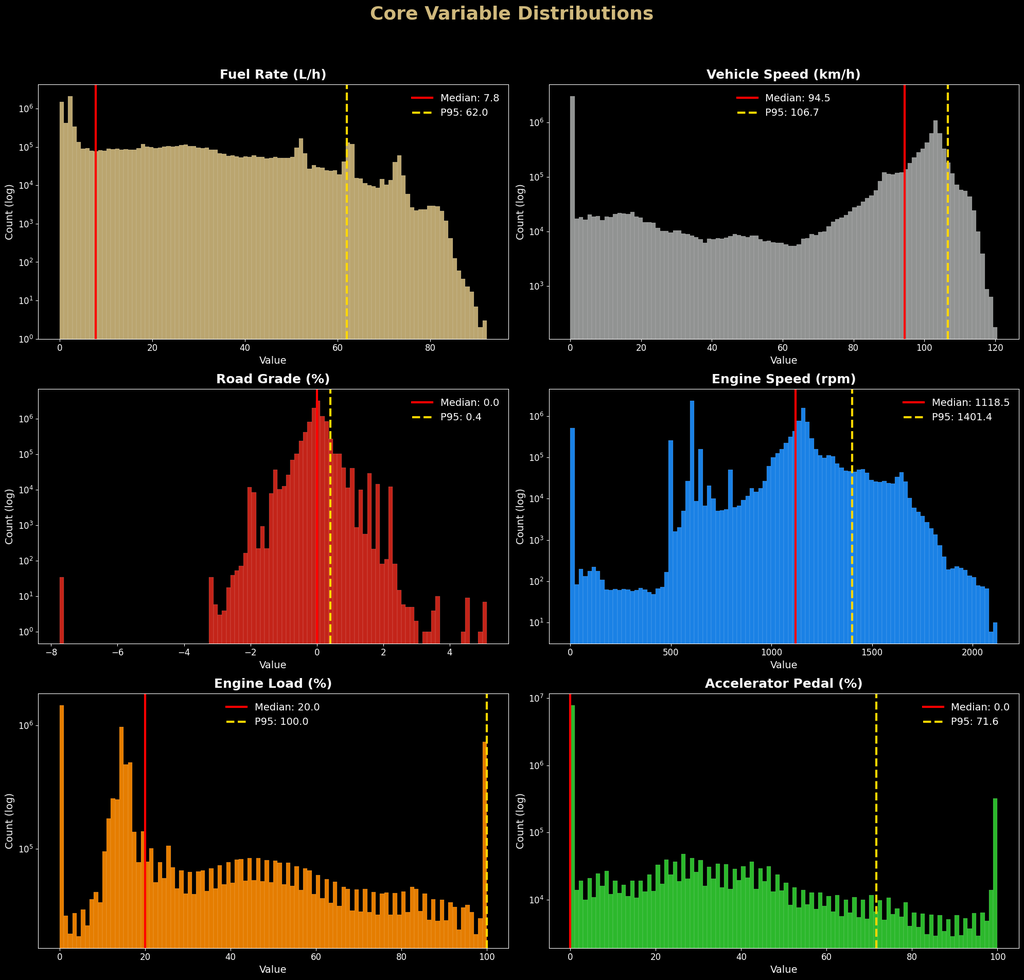

```python
# Define the columns to plot.
quintet_cols = {
    "fuel_inst": ("Fuel Rate (L/h)", "#CFB87C"),
    "CAN_v_speed": ("Vehicle Speed (km/h)", "#A2A4A3"),
    "road_grade_pct": ("Road Grade (%)", "#DA291C"),
    "engine_speed_rpm": ("Engine Speed (rpm)", "dodgerblue"),
    "engine_load_pct": ("Engine Load (%)", "darkorange"),
    "CAN_APP": ("Accelerator Pedal (%)", "limegreen")
}

# Create a 3x2 grid for larger, more readable plots.
fig, axes = plt.subplots(3, 2, figsize=(20, 20), facecolor="black")
axes = axes.flatten()

# Generate a histogram for each variable.
for i, (col, (label, color)) in enumerate(quintet_cols.items()):
    ax = axes[i]
    ax.set_facecolor("black")
    ax.grid(False)

    # Prepare data and stats.
    data = eda_df[col].dropna().to_numpy()
    median_val = np.median(data)
    p95_val = np.percentile(data, 95)

    # Plot the histogram.
    ax.hist(data, bins=100, color=color, edgecolor="ghostwhite", linewidth=0.1, alpha=0.9)

    # Add lines for median and 95th percentile.
    ax.axvline(median_val, color="red", lw=3, ls="-", label=f"Median: {median_val:.1f}")
    ax.axvline(p95_val, color="gold", lw=3, ls="--", label=f"P95: {p95_val:.1f}")

    # Set titles and labels.
    ax.set_title(label, fontsize=18, color="#F8F8F8", fontweight="bold", pad=8)
    ax.set_xlabel("Value", fontsize=14, color="#F8F8F8")
    ax.set_ylabel("Count (log)", fontsize=14, color="#F8F8F8")

    # Style the plot's ticks and border (spines).
    ax.tick_params(axis='x', colors='white', labelsize=12)
    ax.tick_params(axis='y', colors='white', labelsize=12)
    ax.set_yscale('log')
    for spine in ax.spines.values():
        spine.set_edgecolor("white")
    ax.legend(frameon=False, fontsize=14, labelcolor="white")

# Add a main title for the figure.
fig.suptitle("Core Variable Distributions", fontsize=26, color="#CFB87C", fontweight="bold")

# Ensure the layout is tight and clean.
plt.tight_layout(rect=[0, 0.03, 1, 0.95])

# Save the figure.
save_fig(fig, "eda_core_distributions")

# Display the plot.
plt.show()
```

### 4.3 The Fuel Consumption Map

This is the centerpiece of the EDA. The plot shows a 2D heatmap of vehicle speed versus road grade, with the color representing the average fuel rate for that condition. This fuel map provides a clear visualization of the primary drivers of fuel consumption and reveals the operational space where the truck is least efficient.

```
Figure saved to: /home/treinart/projects/ADAS_fuel_rate/artifacts/figures/20251001_180305_eda_fuel_consumption_map_hexbin.png
```

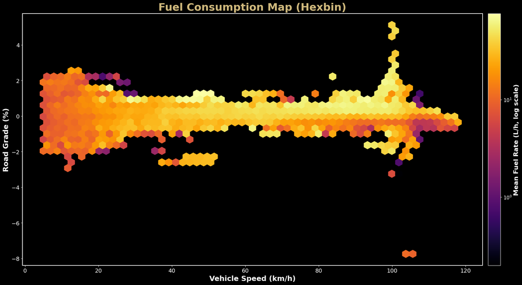

```python
# Prepare the data.
plot_df = eda_df[(eda_df['CAN_v_speed'] > 5) & (eda_df['fuel_inst'] > 0)].copy()
x_data = plot_df['CAN_v_speed']
y_data = plot_df['road_grade_pct']
z_data = plot_df['fuel_inst']

# Create the plot figure and axes.
fig, ax = plt.subplots(figsize=(20, 10), facecolor="black")
ax.set_facecolor("black")
ax.grid(False)

# Plot the hexbin map.
im = ax.hexbin(
    x_data, y_data, C=z_data,
    gridsize=(60, 20), # (x_bins, y_bins)
    cmap='inferno',
    reduce_C_function=np.mean,
    norm=LogNorm()
)

# Add and style the color bar.
cbar = fig.colorbar(im, ax=ax, pad=0.01)
cbar.set_label("Mean Fuel Rate (L/h, log scale)", color="white", fontsize=16, fontweight="bold")
cbar.ax.tick_params(colors="white", labelsize=12)
cbar.outline.set_edgecolor("white")

# Set titles and labels.
ax.set_title("Fuel Consumption Map (Hexbin)", fontsize=26, color="#CFB87C", fontweight="bold", pad=8)
ax.set_xlabel("Vehicle Speed (km/h)", fontsize=18, color="#F8F8F8", fontweight="bold")
ax.set_ylabel("Road Grade (%)", fontsize=18, color="#F8F8F8", fontweight="bold")

# Style the plot's ticks and border (spines).
ax.tick_params(axis='x', colors='white', labelsize=14)
ax.tick_params(axis='y', colors='white', labelsize=14)
for spine in ax.spines.values():
    spine.set_edgecolor("white")
    spine.set_linewidth(1.5)

# Ensure the layout is tight and clean.
plt.tight_layout()

# Save the figure.
save_fig(fig, "eda_fuel_consumption_map_hexbin")

# Display the plot.
plt.show()
```

### 4.4 Fuel vs. Speed by Platoon Position

This analysis investigates the core claim of platooning: that following vehicles are more fuel-efficient. The plot shows the relationship between speed and fuel rate, faceted by the truck's position in the platoon. This provides a direct, visual comparison of the fuel consumption profiles for the lead, middle, and trailing trucks.

```
Figure saved to: /home/treinart/projects/ADAS_fuel_rate/artifacts/figures/20251001_180311_eda_fuel_vs_speed_by_position.png
```

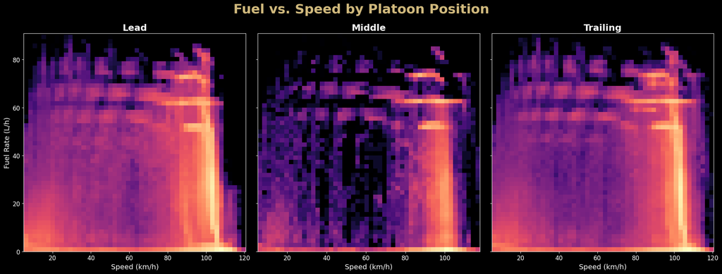

```python
# Define the order and data for the facets.
positions = ["lead", "middle", "trailing"]
plot_df = eda_df[eda_df['position'].isin(positions)].copy()

# Create a 1x3 grid for the plots.
fig, axes = plt.subplots(1, 3, figsize=(20, 8), facecolor="black", sharey=True)
fig.suptitle("Fuel vs. Speed by Platoon Position", fontsize=26, color="#CFB87C", fontweight="bold", y=0.94)

# Generate a 2D density plot for each position.
for ax, pos in zip(axes, positions):
    ax.set_facecolor("black")
    ax.grid(False)

    # Filter data for the current position.
    pos_df = plot_df[(plot_df['position'] == pos) & (plot_df['CAN_v_speed'] > 5)]
    x = pos_df['CAN_v_speed']
    y = pos_df['fuel_inst']

    # Plot the 2D histogram.
    h = ax.hist2d(x, y, bins=(50, 50), cmap='magma', norm=LogNorm())

    # Set titles and labels.
    ax.set_title(pos.capitalize(), fontsize=18, color="#F8F8F8", fontweight="bold")
    ax.set_xlabel("Speed (km/h)", fontsize=14, color="#F8F8F8")
    if ax == axes[0]:
        ax.set_ylabel("Fuel Rate (L/h)", fontsize=14, color="#F8F8F8")

    # Style the plot's ticks and border (spines).
    ax.tick_params(axis='x', colors='white', labelsize=12)
    ax.tick_params(axis='y', colors='white', labelsize=12)
    for spine in ax.spines.values():
        spine.set_edgecolor("white")

# Ensure the layout is tight and clean.
plt.tight_layout(rect=[0, 0, 1, 0.95])

# Save the figure.
save_fig(fig, "eda_fuel_vs_speed_by_position")

# Display the plot.
plt.show()
```

### 4.5 Fuel Rate by Categorical State

This visualization explores the impact of discrete operational states on fuel consumption. Violin plots show the full distribution of fuel rates, sliced by road class, cruise control status, and platoon size. This reveals how different driving modes and environments affect the overall fuel efficiency profile.

```
Figure saved to: /home/treinart/projects/ADAS_fuel_rate/artifacts/figures/20251001_180447_eda_fuel_rate_by_categorical_violins.png
```

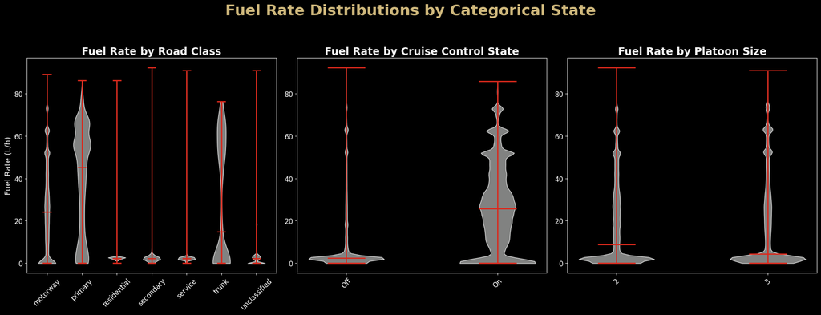

```python
# Initialize tqdm for pandas apply operations.
tqdm.pandas(desc="Grouping data for violins")

# Prepare the data and define categories, dropping NaNs to ensure plots render.
plot_df = eda_df.dropna(subset=['road_class', 'CAN_CC_Active', 'platoon_size']).copy()
plot_df['CAN_CC_Active'] = plot_df['CAN_CC_Active'].map({0: 'Off', 1: 'On'})
plot_df['platoon_size'] = plot_df['platoon_size'].astype(int).astype(str)

cats_to_plot = ['road_class', 'CAN_CC_Active', 'platoon_size']
titles = ['Fuel Rate by Road Class', 'Fuel Rate by Cruise Control State', 'Fuel Rate by Platoon Size']

# Create a 1x3 grid for the plots.
fig, axes = plt.subplots(1, 3, figsize=(20, 8), facecolor="black")
fig.suptitle("Fuel Rate Distributions by Categorical State", fontsize=26, color="#CFB87C", fontweight="bold")

# Generate a violin plot for each category.
for ax, cat, title in zip(axes, cats_to_plot, titles):
    ax.set_facecolor("black")
    ax.grid(False)

    # Group data for the violin plot with a progress bar.
    grouped_data = plot_df.groupby(cat)['fuel_inst'].progress_apply(list)

    # Create the violin plot.
    vp = ax.violinplot(grouped_data.values, showmedians=True)

    # Style the violin plot components.
    for pc in vp['bodies']:
        pc.set_facecolor('#A2A4A3')
        pc.set_edgecolor('white')
        pc.set_alpha(0.8)
    for partname in ('cbars', 'cmins', 'cmaxes', 'cmedians'):
        vp[partname].set_edgecolor('#DA291C')
        vp[partname].set_linewidth(2)

    # Set titles and labels.
    ax.set_title(title, fontsize=18, color="#F8F8F8", fontweight="bold")
    ax.set_xticks(np.arange(1, len(grouped_data) + 1))
    ax.set_xticklabels(grouped_data.index)
    if ax == axes[0]:
        ax.set_ylabel("Fuel Rate (L/h)", fontsize=14, color="#F8F8F8")

    # Style the plot's ticks and border (spines).
    ax.tick_params(axis='x', colors='white', labelsize=12, rotation=45)
    ax.tick_params(axis='y', colors='white', labelsize=12)
    for spine in ax.spines.values():
        spine.set_edgecolor("white")

# Ensure the layout is tight and clean.
plt.tight_layout(rect=[0, 0.03, 1, 0.93])

# Save the figure.
save_fig(fig, "eda_fuel_rate_by_categorical_violins")

# Display the plot.
plt.show()
```

### 4.6 Numerical Feature Correlation

To understand the linear relationships between the key sensor readings, this cell computes and displays the Pearson correlation matrix. The resulting heatmap provides a quick overview of which features are positively or negatively correlated with each other and with the fuel rate target.

```
Figure saved to: /home/treinart/projects/ADAS_fuel_rate/artifacts/figures/20251001_180502_eda_correlation_matrix.png
```

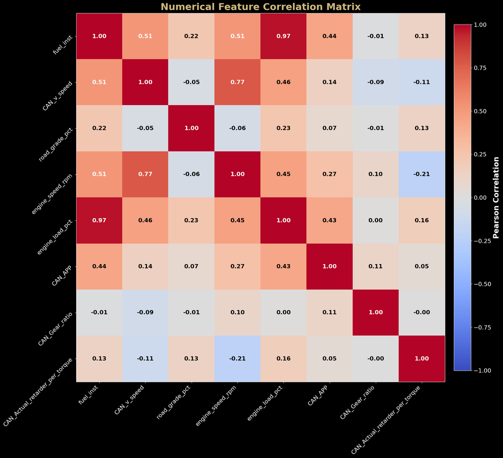

```python
# Define the ideal set of columns for the correlation analysis.
desired_corr_cols = [
    'fuel_inst', 'CAN_v_speed', 'road_grade_pct', 'engine_speed_rpm',
    'engine_load_pct', 'CAN_APP', 'CAN_Gear_ratio', 'CAN_Actual_retarder_per_torque'
]

# Filter for columns that actually exist in the eda_df to prevent KeyErrors.
available_cols = [col for col in desired_corr_cols if col in eda_df.columns]
if len(available_cols) < 2:
    print("Not enough numerical columns available to generate a correlation matrix.")
else:
    corr_df = eda_df[available_cols].corr()

    # Create the plot figure and axes.
    fig, ax = plt.subplots(figsize=(20, 20), facecolor="black")
    ax.set_facecolor("black")
    ax.grid(False)

    # Plot the correlation heatmap.
    im = ax.imshow(corr_df, cmap='coolwarm', vmin=-1, vmax=1)

    # Add the correlation values as text annotations.
    for i in range(len(corr_df.columns)):
        for j in range(len(corr_df.columns)):
            color = "white" if abs(corr_df.iloc[i, j]) > 0.5 else "black"
            ax.text(j, i, f"{corr_df.iloc[i, j]:.2f}",
                    ha="center", va="center", color=color, fontsize=16, weight='bold')

    # Add and style the color bar, making it 90% of the plot height.
    cbar = fig.colorbar(im, ax=ax, pad=0.02, shrink=0.725)
    cbar.set_label("Pearson Correlation", color="white", fontsize=20, fontweight="bold")
    cbar.ax.tick_params(colors="white", labelsize=16)
    cbar.outline.set_edgecolor("white")

    # Set titles and labels.
    ax.set_title("Numerical Feature Correlation Matrix", fontsize=26, color="#CFB87C", fontweight="bold", pad=10)
    ax.set_xticks(np.arange(len(corr_df.columns)))
    ax.set_yticks(np.arange(len(corr_df.columns)))
    ax.set_xticklabels(corr_df.columns, rotation=45, ha="right")
    ax.set_yticklabels(corr_df.columns, rotation=45, ha="right")

    # Style the plot's ticks and border (spines).
    ax.tick_params(axis='x', colors='white', labelsize=16)
    ax.tick_params(axis='y', colors='white', labelsize=16)
    for spine in ax.spines.values():
        spine.set_edgecolor("white")

    # Ensure the layout is tight and clean.
    plt.tight_layout()

    # Save the figure.
    save_fig(fig, "eda_correlation_matrix")

    # Display the plot.
    plt.show()
```

### 4.7 Time-Series Snippets of Driving Events

While aggregated plots are useful, it is also important to examine the raw time-series data. This cell identifies and plots three short, 90-second snippets from a single drive that show the most extreme examples of an uphill climb, a downhill coast, and a hard acceleration event. This provides a look at how the different signals interact during specific maneuvers.

```
Figure saved to: /home/treinart/projects/ADAS_fuel_rate/artifacts/figures/20251001_180509_eda_timeseries_snippets.png
```

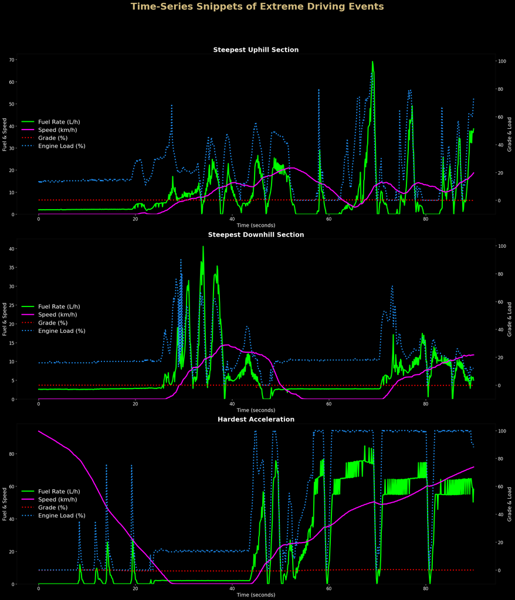

```python
# Define a helper function to find the start of a window centered on an extreme event.
def find_event_window_start(series: pd.Series, duration_sec: int, target_hz: float, method: str = 'max') -> int:
    window_size = int(duration_sec * target_hz)

    # Find the index of the min or max value in the series.
    if method == 'max':
        event_idx = series.idxmax()
    else:
        event_idx = series.idxmin()

    # Center the window on the event, ensuring it doesn't go out of bounds.
    start_idx = max(0, event_idx - window_size // 2)
    start_idx = min(start_idx, len(series) - window_size)
    return start_idx

# Load a single, long, passing file for contiguous data.
file_to_load_row = files_to_load_df.sort_values("bytes", ascending=False).iloc[0]
single_df, _ = unify_timebase(read_selected_csv(file_to_load_row["file"], SELECTED_COLUMNS, DTYPES, RENAME_MAP))
single_df['time_sec'] = (single_df['corrected_time_dt'] - single_df['corrected_time_dt'].min()).dt.total_seconds()

# Find the start index of the most extreme events in this file.
snippet_duration_sec = 90
events_to_find = {
    "Steepest Uphill Section": (single_df['road_grade_pct'], 'max'),
    "Steepest Downhill Section": (single_df['road_grade_pct'], 'min'),
    "Hardest Acceleration": (single_df['CAN_Long_accel'], 'max')
}

found_events = {}
for name, (series, method) in events_to_find.items():
    if not series.dropna().empty:
        start_idx = find_event_window_start(series, snippet_duration_sec, TARGET_HZ, method)
        found_events[name] = start_idx

if not found_events:
    print("Could not analyze events in the sampled file. Skipping plot.")
else:
    # Create a subplot for each event found with independent x-axes.
    fig, axes = plt.subplots(len(found_events), 1, figsize=(20, 8 * len(found_events)), facecolor="black", sharex=False)
    if len(found_events) == 1:
        axes = [axes]
    fig.suptitle("Time-Series Snippets of Extreme Driving Events", fontsize=26, color="#CFB87C", fontweight="bold",  y=0.995)

    # Plot each event snippet.
    for i, (title, start_idx) in enumerate(found_events.items()):
        ax = axes[i]
        ax.set_facecolor("black")

        # Select the 90-second window of data.
        snippet = single_df.iloc[start_idx : start_idx + int(snippet_duration_sec * TARGET_HZ)]
        time_relative = snippet['time_sec'] - snippet['time_sec'].min()

        # Plot primary signals (Fuel and Speed).
        p1 = ax.plot(time_relative, snippet['fuel_inst'], color='lime', lw=3, label='Fuel Rate (L/h)')
        p2 = ax.plot(time_relative, snippet['CAN_v_speed'], color='magenta', lw=3, label='Speed (km/h)')

        # Create a secondary y-axis for other signals.
        ax2 = ax.twinx()
        p3 = ax2.plot(time_relative, snippet['road_grade_pct'], color='red', ls=':', lw=3, label='Grade (%)')
        p4 = ax2.plot(time_relative, snippet['engine_load_pct'], color='dodgerblue', ls=':', lw=3, label='Engine Load (%)')

        # Set consistent y-axis limits.
        ax.set_ylim(bottom=0)
        ax2.set_ylim(-10, 105)
        ax.grid(False)
        ax2.grid(False)

        # Set titles and labels.
        ax.set_title(title, fontsize=18, color="#F8F8F8", fontweight="bold")
        ax.set_ylabel("Fuel & Speed", fontsize=14, color="#F8F8F8")
        ax2.set_ylabel("Grade & Load", fontsize=14, color="#F8F8F8")
        # Set the x-label for each subplot.
        ax.set_xlabel("Time (seconds)", fontsize=14, color="#F8F8F8")

        # Style the plot's ticks and border (spines).
        ax.tick_params(axis='y', colors='white', labelsize=12)
        ax2.tick_params(axis='y', colors='white', labelsize=12)
        ax.tick_params(axis='x', colors='white', labelsize=12)
        for spine in ax.spines.values():
            spine.set_edgecolor("white")

        # Create a combined legend.
        lines = p1 + p2 + p3 + p4
        labels = [l.get_label() for l in lines]
        ax.legend(lines, labels, frameon=False, fontsize=16, labelcolor='white', loc='center left')

    # Ensure the layout is tight and clean.
    plt.tight_layout(rect=[0, 0.03, 1, 0.95])

    # Save the figure.
    save_fig(fig, "eda_timeseries_snippets")

    # Display the plot.
    plt.show()
```

### 4.8 Quantitative Summary by Scenario

This final cell of the EDA provides a quantitative summary of the key findings. It generates a table showing the aggregated statistics (mean, standard deviation, 95th percentile) for the primary features, sliced by the main operational contexts. This table serves as a final, data-driven confirmation of the patterns observed in the plots.

```python
# Define the grouping columns and aggregation logic.
grouping_cols = ['position', 'platoon_size', 'road_class']
agg_cols = {
    'fuel_inst': ['mean', 'std', lambda x: x.quantile(0.95)],
    'CAN_v_speed': ['mean', 'std', lambda x: x.quantile(0.95)],
    'engine_load_pct': ['mean', 'std', lambda x: x.quantile(0.95)]
}

# Verify that all required grouping columns exist in the DataFrame.
missing_cols = [col for col in grouping_cols if col not in eda_df.columns]
if missing_cols:
    raise KeyError(
        f"The following required columns are missing from eda_df: {missing_cols}. "
        "Please re-run cell 4.1 to correctly generate the EDA DataFrame."
    )

# Group the data and calculate the aggregates.
summary_df = eda_df.groupby(grouping_cols).agg(agg_cols).round(2)

# Clean up the multi-level column names.
summary_df.columns = ['_'.join(col).replace('<lambda_0>', 'p95') for col in summary_df.columns.values]

# Display the styled summary table.
print("-" * 70)
print("--- Summary by Operational Scenario ---")
print("Quantifying performance by position, platoon size, and road class.")

display(cubuff_style_table(summary_df.reset_index()))
```

```
----------------------------------------------------------------------
--- Summary by Operational Scenario ---
Quantifying performance by position, platoon size, and road class.
```

| position | platoon_size | road_class | fuel_inst_mean | fuel_inst_std | fuel_inst_p95 | CAN_v_speed_mean | CAN_v_speed_std | CAN_v_speed_p95 | engine_load_pct_mean | engine_load_pct_std | engine_load_pct_p95 |
| --- | --- | --- | --- | --- | --- | --- | --- | --- | --- | --- | --- |
| lead | 2 | motorway | 26.680000 | 20.620001 | 62.500000 | 96.480003 | 18.740000 | 108.640000 | 46.740002 | 32.790001 | 100.000000 |
| lead | 2 | primary | 37.950001 | 23.200001 | 67.450000 | 54.450001 | 17.830000 | 79.970000 | 64.169998 | 36.520000 | 100.000000 |
| lead | 2 | residential | 2.550000 | 3.070000 | 2.600000 | 0.700000 | 4.550000 | 0.000000 | 14.610000 | 5.040000 | 16.000000 |
| lead | 2 | secondary | 7.050000 | 14.390000 | 46.950000 | 8.420000 | 16.530001 | 49.660000 | 19.959999 | 21.620001 | 83.000000 |
| lead | 2 | service | 3.640000 | 6.180000 | 13.000000 | 3.200000 | 8.540000 | 20.800000 | 15.440000 | 10.310000 | 33.000000 |
| lead | 2 | trunk | 30.670000 | 27.490000 | 65.800000 | 63.520000 | 16.709999 | 87.640000 | 51.580002 | 45.669998 | 100.000000 |
| lead | 2 | unclassified | 3.410000 | 6.440000 | 18.200000 | 1.660000 | 6.890000 | 15.000000 | 11.570000 | 12.710000 | 28.000000 |
| lead | 3 | motorway | 25.330000 | 20.959999 | 63.050000 | 95.120003 | 12.460000 | 104.950000 | 45.279999 | 32.540001 | 100.000000 |
| lead | 3 | primary | 38.880001 | 24.809999 | 68.550000 | 53.279999 | 17.230000 | 75.200000 | 65.000000 | 39.250000 | 100.000000 |
| lead | 3 | residential | 2.770000 | 2.960000 | 2.700000 | 0.780000 | 4.500000 | 0.000000 | 15.710000 | 4.930000 | 17.000000 |
| lead | 3 | secondary | 6.110000 | 13.110000 | 39.880000 | 7.350000 | 15.100000 | 47.500000 | 18.840000 | 19.559999 | 75.000000 |
| lead | 3 | service | 3.600000 | 5.000000 | 10.800000 | 2.690000 | 7.090000 | 16.880000 | 16.660000 | 8.660000 | 30.000000 |
| lead | 3 | trunk | 27.400000 | 30.049999 | 66.250000 | 64.000000 | 12.060000 | 81.980000 | 44.189999 | 48.430000 | 100.000000 |
| lead | 3 | unclassified | 2.810000 | 5.420000 | 6.250000 | 2.310000 | 7.730000 | 18.440000 | 12.910000 | 12.040000 | 26.000000 |
| middle | 3 | motorway | 26.090000 | 23.750000 | 63.750000 | 94.199997 | 13.680000 | 105.090000 | 44.860001 | 38.369999 | 100.000000 |
| middle | 3 | primary | 36.220001 | 27.170000 | 68.200000 | 56.500000 | 17.700001 | 72.720000 | 60.110001 | 41.759998 | 100.000000 |
| middle | 3 | residential | 2.740000 | 3.720000 | 2.550000 | 0.680000 | 4.150000 | 0.140000 | 15.660000 | 6.310000 | 16.000000 |
| middle | 3 | secondary | 5.740000 | 13.370000 | 39.750000 | 6.430000 | 17.139999 | 49.470000 | 18.280001 | 19.650000 | 76.000000 |
| middle | 3 | service | 4.570000 | 7.080000 | 18.700000 | 4.810000 | 8.940000 | 21.830000 | 17.530001 | 12.950000 | 44.000000 |
| middle | 3 | trunk | 24.959999 | 33.049999 | 75.950000 | 62.810001 | 6.610000 | 74.920000 | 37.250000 | 47.740002 | 100.000000 |
| middle | 3 | unclassified | 2.750000 | 7.640000 | 7.800000 | 2.360000 | 7.730000 | 19.690000 | 10.670000 | 15.030000 | 29.000000 |
| trailing | 2 | motorway | 26.260000 | 20.299999 | 62.650000 | 99.449997 | 13.010000 | 108.720000 | 45.869999 | 32.560001 | 100.000000 |
| trailing | 2 | primary | 41.029999 | 25.030001 | 68.350000 | 58.049999 | 19.110001 | 82.800000 | 66.970001 | 37.700001 | 100.000000 |
| trailing | 2 | residential | 2.490000 | 3.090000 | 2.500000 | 0.640000 | 4.360000 | 0.000000 | 14.660000 | 5.020000 | 16.000000 |
| trailing | 2 | secondary | 6.660000 | 14.540000 | 48.100000 | 7.010000 | 15.740000 | 49.830000 | 19.799999 | 20.940001 | 84.000000 |
| trailing | 2 | service | 3.670000 | 7.020000 | 12.800000 | 3.390000 | 9.150000 | 21.250000 | 15.210000 | 11.860000 | 35.000000 |
| trailing | 2 | trunk | 24.459999 | 28.740000 | 74.670000 | 65.440002 | 10.000000 | 82.780000 | 40.700001 | 46.500000 | 100.000000 |
| trailing | 2 | unclassified | 2.590000 | 6.260000 | 5.300000 | 1.880000 | 7.600000 | 15.440000 | 11.620000 | 13.410000 | 28.000000 |
| trailing | 3 | motorway | 26.309999 | 24.360001 | 64.050000 | 93.019997 | 18.410000 | 107.200000 | 44.830002 | 38.799999 | 100.000000 |
| trailing | 3 | primary | 39.490002 | 27.040001 | 68.650000 | 53.810001 | 17.450001 | 78.310000 | 63.770000 | 41.790001 | 100.000000 |
| trailing | 3 | residential | 2.840000 | 3.870000 | 2.600000 | 0.650000 | 3.970000 | 0.000000 | 16.080000 | 6.080000 | 16.000000 |
| trailing | 3 | secondary | 6.820000 | 14.750000 | 50.910000 | 6.470000 | 14.230000 | 45.730000 | 20.400000 | 21.209999 | 89.200000 |
| trailing | 3 | service | 3.330000 | 7.260000 | 8.900000 | 2.380000 | 7.750000 | 17.190000 | 14.110000 | 12.780000 | 27.000000 |
| trailing | 3 | trunk | 38.009998 | 30.730000 | 66.670000 | 57.189999 | 6.440000 | 69.820000 | 60.919998 | 47.290001 | 100.000000 |
| trailing | 3 | unclassified | 3.350000 | 8.540000 | 8.950000 | 3.050000 | 9.620000 | 27.180000 | 12.920000 | 15.350000 | 28.000000 |

### *Observation:* Visual Exploratory Data Analysis

I made a critical mistake right out of the gate in subsection 4.1 by trying to pull in all the data at once. That crashed everything pretty quickly.

I overcorrected and went ultra-conservative with only 10% of the dataset using `n_samples = int(np.ceil(0.10 * len(files_to_load_df)))`. This got me moving again and provided enough data to work through the section without my machine grinding to a halt.

Initially I built all the plots using raw column headers, but the results looked terrible from a readability standpoint. Going back to swap in human-readable labels made a huge difference. "Vehicle Speed (km/h)" reads so much better than "CAN_v_speed" on a chart.

The visualizations turned out well overall. You can quickly spot the relationship between fuel usage and other vehicle features. I'm not usually a fan of violin plots, but after trying several different plot types that showed nothing meaningful, the violin plots actually delivered clear results for this dataset.

The snippet plots were a pain to get looking decent. They're still somewhat noisy, but the high contrast colors make it easy to see patterns. You can clearly observe how fuel rate and engine load track together across the different scenarios, which validates that the dataset is behaving as expected.

Once I had all the code cells working in section 4, I went back to test different data sample sizes. I bumped up to 15%, then 25% - both ran smoothly and the plots showed better detail. At 50% the visualizations looked solid. I pushed to 65% but hit diminishing returns. The processing time and RAM usage weren't justified since the plot quality didn't improve noticeably.

50% ended up being the sweet spot for balancing data comprehensiveness with reasonable performance.

## Section 5: Windowing, Targets & Data Splits

This section transitions the project from continuous time-series data into a format ready for supervised learning. The process involves defining the prediction targets, creating fixed-size "windows" of sensor data, and establishing a rigorous, stratified train/validation/test split. The final output is a set of cached data files, ready for preprocessing, and a state file that makes the notebook resumable.

### Section Plan:

1. **Splitting Strategy:** Perform a stratified 70/10/20 split on the file list to prevent data leakage.
2. **Windowing Function:** Define the core utility for creating 10-second data windows and generating a smoothed fuel target.
3. **Process & Cache:** Run the windowing function on all files and save the output as a series of efficient part-files.
4. **Verification:** Confirm that all part-files were created successfully and run a final check to guarantee no data leakage between splits.
5. **Save State:** Save all critical variables to disk to make the notebook resumable from this point forward.

### 5.1 Splitting Strategy & Target Definition

The first step is to establish the validation strategy. To prevent data leakage, the dataset is split at the file level. A stratified split is used to ensure that the train, validation, and test sets all have a similar distribution of truck positions and platoon sizes. This cell also defines the core constants for the windowing process and the smoothed fuel target.

```python
# Define constants for windowing and target creation.
WINDOW_SIZE = 100  # 100 steps @ 10 Hz = 10-second window
EWMA_HALF_LIFE = 12 # Seconds for the smoothed fuel target

# Load the audited file manifest from Section 3.
audit_df = pd.read_parquet(list(CACHE_DIR.glob("*_audit_full_section3.parquet"))[-1])
passing_files_df = audit_df[audit_df["pass_flag"] == True].copy()

# Create a stratification key from position and platoon size.
passing_files_df['stratify_key'] = (
    passing_files_df['position'].fillna('na').astype(str) + '_' +
    passing_files_df['platoon_size'].fillna(0).astype(int).astype(str)
)

# Perform a stratified 70/10/20 split on the file list.
# First, split into training/validation (80%) and test (20%).
train_val_files, test_files = train_test_split(
    passing_files_df,
    test_size=0.20,
    random_state=SEED,
    stratify=passing_files_df['stratify_key']
)

# Second, split the 80% into training (70%) and validation (10%).
# 10% is 12.5% of the remaining 80%.
train_files, val_files = train_test_split(
    train_val_files,
    test_size=0.125,
    random_state=SEED,
    stratify=train_val_files['stratify_key']
)

# Create a summary of the splits to verify stratification.
splits = {'Train': train_files, 'Validation': val_files, 'Test': test_files}
summary_rows = []
for name, df in splits.items():
    row = {'Set': name, 'File Count': len(df)}
    dist = df['stratify_key'].value_counts(normalize=True).mul(100).round(1)
    for key, val in dist.items():
        row[key] = f"{val}%"
    summary_rows.append(row)

split_summary_df = pd.DataFrame(summary_rows).set_index('Set').fillna('0.0%')

# Display the styled summary table.
print("-" * 70)
print("--- Dataset Split Summary ---")
print(f"Splitting {len(passing_files_df)} files into Train/Validation/Test sets.")

display(cubuff_style_table(split_summary_df.reset_index()))
```

```
----------------------------------------------------------------------
--- Dataset Split Summary ---
Splitting 61 files into Train/Validation/Test sets.
```

| Set | File Count | lead_2 | trailing_2 | middle_3 | lead_3 | trailing_3 |
| --- | --- | --- | --- | --- | --- | --- |
| Train | 42 | 45.2% | 35.7% | 7.1% | 7.1% | 4.8% |
| Validation | 6 | 50.0% | 33.3% | 0.0% | 0.0% | 16.7% |
| Test | 13 | 46.2% | 30.8% | 7.7% | 7.7% | 7.7% |

### 5.2 The Windowing Function

This cell contains the core utility for transforming the data. The `create_windows` function takes a continuous time-series DataFrame and converts it into discrete samples for the models. It generates 10-second feature windows and creates the corresponding targets: the instantaneous fuel rate and a smoothed version using an Exponentially Weighted Moving Average.

```python
# Define the function that transforms continuous time-series data into discrete windows.
def create_windows(df: pd.DataFrame, window_size: int, ewma_half_life: int) -> tuple[np.ndarray, np.ndarray]:

    # Drop rows with critical NaN values before creating targets and windows.
    critical_cols = ['fuel_inst', 'CAN_v_speed', 'road_grade_pct']
    df = df.dropna(subset=critical_cols).copy()

    if len(df) < window_size:
        return np.array([]), np.array([])

    # Create the smoothed fuel target using an Exponentially Weighted Moving Average.
    df['fuel_smooth'] = df['fuel_inst'].ewm(halflife=ewma_half_life * TARGET_HZ, ignore_na=True).mean()

    # Define a canonical list of numeric features to ensure consistent shapes.
    cols_to_exclude = ['corrected_time', 'road_class', 'HMI_CACC_Status', 'fuel_inst', 'fuel_smooth']
    # Use SELECTED_COLUMNS as the single source of truth for all possible features.
    canonical_features = [c for c in SELECTED_COLUMNS if c not in cols_to_exclude]
    target_cols = ['fuel_inst', 'fuel_smooth']

    # Ensure all canonical feature columns exist in the dataframe, adding 0 for any missing.
    for col in canonical_features:
        if col not in df.columns:
            df[col] = 0

    # Select and reorder columns to match the canonical list exactly before converting to numpy.
    feature_arr = df[canonical_features].to_numpy(dtype=np.float32)
    target_arr = df[target_cols].to_numpy(dtype=np.float32)

    # Create windows using a sliding window approach.
    X, y = [], []
    for i in range(len(df) - window_size):
        X.append(feature_arr[i : i + window_size])
        y.append(target_arr[i + window_size - 1])

    return np.array(X), np.array(y)

# Print a confirmation that the function is defined.
print("-" * 70)
print("--- Windowing Function Defined ---")
print(f"Function '{create_windows.__name__}' is now defined and ready for use.")
print("-" * 70)
```

```
----------------------------------------------------------------------
--- Windowing Function Defined ---
Function 'create_windows' is now defined and ready for use.
----------------------------------------------------------------------
```

### 5.3 Process & Cache Datasets

This is the main data processing step for this section. The code iterates through the train, validation, and test file lists. For each file, it applies the windowing function and saves the resulting feature and target arrays to disk as a separate "part-file." This single-pass, memory-efficient approach allows for processing the entire dataset without crashing the kernel.

```python
# Define a single-pass function to process files and save them as individual parts.
def process_and_save_split(file_df: pd.DataFrame, split_name: str):

    print("-" * 70)
    print(f"Processing {split_name} set ({len(file_df)} files)...")

    # Create a dedicated directory for this split's part-files.
    output_dir = CACHE_DIR / f"{split_name}_parts"
    output_dir.mkdir(exist_ok=True)

    # Get full file paths from the MANIFEST.
    manifest_df = MANIFEST.copy()
    manifest_df["file_name_only"] = manifest_df["name"]
    files_to_process = manifest_df[manifest_df["file_name_only"].isin(file_df["file"])]

    # Process each file and save its windows as a separate .npy file.
    part_num = 0
    for _, row in tqdm(files_to_process.iterrows(), total=len(files_to_process), desc=f"Processing {split_name} files"):
        full_path = Path(row['file'])
        if not full_path.exists(): continue

        raw_df = read_selected_csv(str(full_path), SELECTED_COLUMNS, DTYPES, RENAME_MAP)
        unified_df, _ = unify_timebase(raw_df)
        X, y = create_windows(unified_df, WINDOW_SIZE, EWMA_HALF_LIFE)

        if X.shape[0] > 0:
            part_num += 1
            x_part_path = output_dir / f"X_{split_name}_part_{part_num:03d}.npy"
            y_part_path = output_dir / f"y_{split_name}_part_{part_num:03d}.npy"
            np.save(x_part_path, X)
            np.save(y_part_path, y)

    print(f"\n{split_name} set processed. Saved {part_num} part-files to '{output_dir.name}'.")

# Process all three splits.
print("-" * 70)
print("--- Processing All Splits ---")
process_and_save_split(train_files, 'Train')
process_and_save_split(val_files, 'Validation')
process_and_save_split(test_files, 'Test')
print("All sets have been processed and cached.")
print("-" * 70)
```

```
----------------------------------------------------------------------
--- Processing All Splits ---
----------------------------------------------------------------------
Processing Train set (42 files)...
```

```
Train set processed. Saved 42 part-files to 'Train_parts'.
----------------------------------------------------------------------
Processing Validation set (6 files)...
```

```
Validation set processed. Saved 6 part-files to 'Validation_parts'.
----------------------------------------------------------------------
Processing Test set (13 files)...
```

```
Test set processed. Saved 13 part-files to 'Test_parts'.
All sets have been processed and cached.
----------------------------------------------------------------------
```

### 5.4 Verification & Leakage Check

After processing, this cell provides a final verification. It confirms that all the part-file directories were created and contain the correct number of files. Most importantly, it performs an explicit assertion to guarantee that there is zero overlap in the files used for the train, validation, and test sets, proving the split is free from data leakage.

```python
# Verify the shapes of the cached arrays and perform a data leakage check.
print("-" * 70)
print("--- Verification of Cached Datasets ---")

# Verify the output directories and the shape of a sample part-file.
verification_rows = []
split_files = {'Train': train_files, 'Validation': val_files, 'Test': test_files}

for split in ['Train', 'Validation', 'Test']:
    part_dir = CACHE_DIR / f"{split}_parts"
    if not part_dir.exists():
        verification_rows.append({"Set": split, "Status": "Directory Not Found", "# Parts": 0})
        continue

    x_files = sorted(part_dir.glob("X_*.npy"))
    y_files = sorted(part_dir.glob("y_*.npy"))
    row = {"Set": split, "# X Parts": len(x_files), "# y Parts": len(y_files)}

    # Load the first part-file to verify its shape.
    if x_files:
        first_x_part = np.load(x_files[0])
        row["Sample Part Shape"] = str(first_x_part.shape)
    else:
        row["Sample Part Shape"] = "N/A"
    verification_rows.append(row)

verification_df = pd.DataFrame(verification_rows).set_index('Set')
try:
    display(cubuff_style_table(verification_df.reset_index()))
except Exception:
    display(verification_df)

# Perform the data leakage check.
print("--- Leakage Check ---")
train_set = set(split_files['Train']['file'])
val_set = set(split_files['Validation']['file'])
test_set = set(split_files['Test']['file'])

# Assert that the intersection between each pair of sets is empty.
assert train_set.isdisjoint(val_set), "Leakage found between train and validation sets!"
assert train_set.isdisjoint(test_set), "Leakage found between train and test sets!"
assert val_set.isdisjoint(test_set), "Leakage found between validation and test sets!"

print(f"Leakage Check Passed: {len(train_set)} Train, {len(val_set)} Validation, and {len(test_set)} Test files are fully disjoint.")
print("-" * 70)
```

```
----------------------------------------------------------------------
--- Verification of Cached Datasets ---
```

| Set | # X Parts | # y Parts | Sample Part Shape |
| --- | --- | --- | --- |
| Train | 42 | 42 | (303921, 100, 24) |
| Validation | 6 | 6 | (323101, 100, 24) |
| Test | 13 | 13 | (296343, 100, 24) |

```
--- Leakage Check ---
Leakage Check Passed: 42 Train, 6 Validation, and 13 Test files are fully disjoint.
----------------------------------------------------------------------
```

### 5.5 Save Notebook State

This cell gathers all the essential configuration variables, file paths, and data schemas that have been created so far and saves them to a single state file on disk. This allows the kernel to be restarted without losing progress, as subsequent sections can now load this file to instantly restore their required state.

```python
# Gather all necessary variables created up to this point into a single dictionary.
state_to_save = {
    # File path splits from 5.1.
    'train_files': train_files,
    'val_files': val_files,
    'test_files': test_files,

    # Key configuration variables from earlier sections needed for a resumable state.
    'SELECTED_COLUMNS': SELECTED_COLUMNS,
    'RENAME_MAP': RENAME_MAP,
    'SCHEMA': SCHEMA,
    'WINDOW_SIZE': WINDOW_SIZE,
    'EWMA_HALF_LIFE': EWMA_HALF_LIFE,
    'TARGET_HZ': TARGET_HZ,
    'CACHE_DIR': CACHE_DIR,
    'SEED': SEED
}

# Save the state dictionary to a single file.
state_file_path = CACHE_DIR / "notebook_state_after_section5.joblib"
joblib.dump(state_to_save, state_file_path)

print("-" * 70)
print("--- Section 5 Notebook State Saved ---")
print(f"All necessary variables and file paths have been saved to:")
print(state_file_path)
print("You can now restart the kernel and start directly from Section 6 or 7.")
print("-" * 70)
```

```
----------------------------------------------------------------------
--- Section 5 Notebook State Saved ---
All necessary variables and file paths have been saved to:
/home/treinart/projects/ADAS_fuel_rate/artifacts/cache/notebook_state_after_section5.joblib
You can now restart the kernel and start directly from Section 6 or 7.
----------------------------------------------------------------------
```

### *Observation:* Sequence Windowing & Caching

This section was a battle. Easily the most challenging so far. It felt less like data science and more like wrestling with my machine's limitations until I found an architecture that actually worked.

The goal seemed simple enough. Split the files, loop through them to create 10-second windows. I had no idea what I was walking into.The first crash hit hard. My initial attempt to process the entire training set just killed the kernel. No warning, no error message, just complete system failure. It became obvious I couldn't hold the full dataset in memory, but I didn't have a clear path forward.

My first "fix" made everything worse. I thought the two-pass memmap approach was clever - calculate the size first, then fill a file on disk. This turned out to be a complete trap. Not only was it incredibly slow, but it created corrupted `.npy` files that `np.load` couldn't even read. I spent hours debugging an `UnpicklingError` on a fundamentally broken solution.

The slowdown was infuriating. Switching to `np.save` fixed the corruption but created a new nightmare. What should have taken minutes was suddenly taking over an hour. Watching the progress bar crawl for 15+ minutes on just the training set felt completely unacceptable for a development workflow.

The breakthrough came when I scrapped the giant file approach. The single-pass, process-and-save-parts architecture finally worked. It was fast, didn't crash, and felt like a professional solution. For the first time in this section, I wasn't fighting the tools.

The save state cell was the final piece. I kept hitting `NameError`s in later sections after kernel restarts. Adding that resumable state cell in 5.5 broke the "re-run everything" cycle. I'm not sure why it took multiple failures in section 7 for me to realize I needed this, but it made the whole project feel solid.

This section forced me out of simple in-memory processing into real-world, large-scale data handling. It was painful but necessary. The final pipeline is fast, memory-safe, and completely resumable.

#### Build Results:

- **Split summary.** 61 files divided into **Train 42** / **Val 6** / **Test 13**. Class mix looks reasonable across sets (lead/trailing dominate, middle_3 present in Train/Test).
- **Windowing function.** `create_windows` defined and exercised without errors on all splits.
- **Processing & cache.**
  - Train: **42/42** files processed in **4:01** (~5.8 s/file) → saved **42** part-files.
  - Validation: **6/6** in **0:36** (~6.1 s/file) → saved **6** part-files.
  - Test: **13/13** in **1:21** (~6.2 s/file) → saved **13** part-files.
- **Cache verification.** Part counts line up (X/Y match per split). Sample shapes confirm consistent windowing: `Train (303,921, 100, 24)`, `Val (323,101, 100, 24)`, `Test (296,343, 100, 24)`.
- **Leakage check.** Passed - Train/Val/Test file lists are fully disjoint.
- **Resumable state.** Configuration variables and file paths were saved to `notebook_state_after_section5.joblib`, making all following sections fully independent and resumable. Allowing me to restart and jump straight into later sections after a kernel crash.

## Section 6: Preprocessing & Feature Engineering

This section prepares the windowed data for the models. The process involves two distinct pipelines. The first engineers a set of tabular, statistical features designed for the XGBoost baseline model. The second pipeline prepares the raw time-series sequences for the deep learning model. A critical step is fitting all scalers and encoders on the training data only to prevent data leakage.

### Section Plan:

1. **Load State & Define Features:** Load the saved notebook state and define the feature-to-index mappings.
2. **Fit Preprocessors:** Fit the scalers and encoders on a sample of the training data to learn the transformation statistics.
3. **Generate XGBoost Features:** Create the tabular feature set by calculating summary statistics for each window.
4. **Generate Deep Learning Features:** Preprocess the raw sequential data for the CNN->GRU model.
5. **Verify Artifacts:** Confirm that all final data and preprocessor files have been successfully created and saved.

### 6.1 Load State & Define Feature Indices

To make the notebook resumable, this cell begins by loading the complete state saved at the end of Section 5. It then inventories the data part-files and creates the necessary mappings from feature names to their corresponding indices in the data arrays, separating them into numerical and categorical groups for the upcoming transformations.

```python
# Load the general notebook state from Section 5.
print("Loading notebook state from disk...")
state_file_path = sorted(CACHE_DIR.glob("notebook_state_after_section5.joblib"))[-1]
notebook_state = joblib.load(state_file_path)
globals().update(notebook_state)
print(f"State loaded successfully from {state_file_path.name}")

# Find the paths to the raw windowed data parts created in Section 5.
X_train_paths = sorted((CACHE_DIR / "Train_parts").glob("X_*.npy"))
y_train_paths = sorted((CACHE_DIR / "Train_y_parts").glob("y_*.npy"))
X_val_paths   = sorted((CACHE_DIR / "Validation_parts").glob("X_*.npy"))
y_val_paths   = sorted((CACHE_DIR / "Validation_y_parts").glob("y_*.npy"))
X_test_paths  = sorted((CACHE_DIR / "Test_parts").glob("X_*.npy"))
y_test_paths  = sorted((CACHE_DIR / "Test_y_parts").glob("y_*.npy"))

# Recreate the feature-to-index mappings using the loaded variables.
effective_names = [RENAME_MAP.get(c, c) for c in SELECTED_COLUMNS]
cols_to_exclude = ['corrected_time', 'road_class', 'HMI_CACC_Status', 'fuel_inst', 'fuel_smooth']
feature_names = [name for name in effective_names if name not in cols_to_exclude]
feature_to_idx = {name: i for i, name in enumerate(feature_names)}
numeric_feature_indices = [
    feature_to_idx[c] for c in feature_names
    if c in feature_to_idx and SCHEMA[SCHEMA['column'] == c]['role'].iloc[0] == 'numeric'
]
categorical_feature_indices = [
    feature_to_idx[c] for c in feature_names
    if c in feature_to_idx and SCHEMA[SCHEMA['column'] == c]['role'].iloc[0] == 'categorical'
]

# Print a summary.
print("-" * 70)
print("--- Setup Complete for Preprocessing ---")
print("All configurations and data paths are now loaded into memory.")
print(f"Found {len(X_train_paths)} training part-files to be processed.")
print(f"Found {len(X_val_paths)} validation part-files.")
print(f"Found {len(X_test_paths)} test part-files.")
print("-" * 70)
```

```
Loading notebook state from disk...
State loaded successfully from notebook_state_after_section5.joblib
----------------------------------------------------------------------
--- Setup Complete for Preprocessing ---
All configurations and data paths are now loaded into memory.
Found 42 training part-files to be processed.
Found 6 validation part-files.
Found 13 test part-files.
----------------------------------------------------------------------
```

### 6.2 Fit Preprocessors on Training Data

To prevent data leakage, all preprocessors must be fitted on the training data only. This cell uses a sample of the training set to fit two distinct `StandardScaler` objects. One for the time-series data and one for the summary statistics, and a `OneHotEncoder`. The fitted objects are then saved to disk for later use.

```python
# Initialize the preprocessors.
time_scaler = StandardScaler()
stats_scaler = StandardScaler()
encoder = OneHotEncoder(handle_unknown='ignore', sparse_output=False)

# Use a sample of the training part-files for efficient fitting.
sample_paths = X_train_paths[:10]

# Fit scalers incrementally, one part-file at a time, to conserve memory.
print("Fitting scalers incrementally on sample parts...")
for path in tqdm(sample_paths, desc="Partial fitting scalers"):
    X_part = np.load(path)

    # Partial fit the time-domain scaler.
    X_num_part_2d = X_part[:, :, numeric_feature_indices].reshape(-1, len(numeric_feature_indices))
    time_scaler.partial_fit(X_num_part_2d)

    # Generate summary stats for this part and partial fit the stats-domain scaler.
    X_num_part_3d = X_part[:, :, numeric_feature_indices]
    stats_part = np.concatenate([
        X_num_part_3d.mean(axis=1), X_num_part_3d.std(axis=1), X_num_part_3d.min(axis=1),
        X_num_part_3d.max(axis=1), X_num_part_3d[:, -1, :], np.quantile(X_num_part_3d, 0.25, axis=1),
        np.quantile(X_num_part_3d, 0.75, axis=1)
    ], axis=1)
    stats_scaler.partial_fit(stats_part)

# For the encoder, fitting on the last loaded part is sufficient.
if categorical_feature_indices and 'X_part' in locals():
    print("Fitting encoder...")
    cat_fit_sample = X_part[:, -1, categorical_feature_indices]
    encoder.fit(cat_fit_sample)

# Save the fitted preprocessor objects to disk.
ts = _timestamp()
scaler_time_path = CACHE_DIR / f"{ts}_time_scaler.joblib"
scaler_stats_path = CACHE_DIR / f"{ts}_stats_scaler.joblib"
encoder_path = CACHE_DIR / f"{ts}_onehot_encoder.joblib"

joblib.dump(time_scaler, scaler_time_path)
joblib.dump(stats_scaler, scaler_stats_path)
if categorical_feature_indices:
    joblib.dump(encoder, encoder_path)

# Print a confirmation.
print("-" * 70)
print("--- Preprocessors Fitted and Saved ---")
print(f"Time-domain scaler saved to: {scaler_time_path.name}")
print(f"Stats-domain scaler saved to: {scaler_stats_path.name}")
if categorical_feature_indices:
    print(f"OneHotEncoder saved to: {encoder_path.name}")
else:
    print("No categorical features to encode.")
print("-" * 70)
```

```
Fitting scalers incrementally on sample parts...
```

```
Fitting encoder...
----------------------------------------------------------------------
--- Preprocessors Fitted and Saved ---
Time-domain scaler saved to: 20250929_211436_time_scaler.joblib
Stats-domain scaler saved to: 20250929_211436_stats_scaler.joblib
OneHotEncoder saved to: 20250929_211436_onehot_encoder.joblib
----------------------------------------------------------------------
```

### 6.3 Generate Feature Set A: Tabular Features for XGBoost

This cell creates the first of two feature sets. It processes the train, validation, and test data by engineering a set of summary statistics (mean, std, last value, etc.) from each 10-second window. The pre-fitted scalers and encoders are then applied to these statistics to produce the final, tabular feature set ready for the XGBoost model.

```python
# Engineer tabular features from the sequence windows.
def create_tabular_features(X_windows, num_indices, cat_indices, scaler, encoder):
    X_num = X_windows[:, :, num_indices]
    X_cat = X_windows[:, :, cat_indices]
    stats_features = np.concatenate([
        X_num.mean(axis=1), X_num.std(axis=1), X_num.min(axis=1), X_num.max(axis=1),
        X_num[:, -1, :], np.quantile(X_num, 0.25, axis=1), np.quantile(X_num, 0.75, axis=1)
    ], axis=1)
    X_stats_scaled = scaler.transform(stats_features)
    if cat_indices:
        X_cat_last_step = X_cat[:, -1, :]
        X_cat_encoded = encoder.transform(X_cat_last_step)
        return np.concatenate([X_stats_scaled, X_cat_encoded], axis=1)
    else:
        return X_stats_scaled

# Process each split by loading, transforming, and saving one part-file at a time.
def process_tabular_split(X_paths, y_paths, split_name):
    print(f"Processing {split_name} set...")
    output_dir_x = CACHE_DIR / f"{split_name}_xgb_x_parts"
    output_dir_y = CACHE_DIR / f"{split_name}_xgb_y_parts"
    output_dir_x.mkdir(exist_ok=True)
    output_dir_y.mkdir(exist_ok=True)

    for i, (x_path, y_path) in enumerate(tqdm(zip(X_paths, y_paths), total=len(X_paths), desc=f"Processing {split_name}")):
        X_part = np.load(x_path)
        X_xgb_part = create_tabular_features(X_part, numeric_feature_indices, categorical_feature_indices, stats_scaler, encoder)
        np.save(output_dir_x / f"X_{split_name}_xgb_part_{i+1:03d}.npy", X_xgb_part)
        shutil.copy(y_path, output_dir_y / f"y_{split_name}_part_{i+1:03d}.npy")

# Process and save the tabular feature sets for all splits.
print("-" * 70)
print("--- Generating Tabular Features for XGBoost ---")
process_tabular_split(X_train_paths, y_train_paths, 'Train')
process_tabular_split(X_val_paths, y_val_paths, 'Validation')
process_tabular_split(X_test_paths, y_test_paths, 'Test')
print("--- Tabular feature generation complete ---")
print("-" * 70)
```

```
----------------------------------------------------------------------
--- Generating Tabular Features for XGBoost ---
Processing Train set...
```

```
Processing Validation set...
```

```
Processing Test set...
```

```
--- Tabular feature generation complete ---
----------------------------------------------------------------------
```

```python
# Check available disk space
!df -h
```

```
Filesystem      Size  Used Avail Use% Mounted on
none             16G     0   16G   0% /usr/lib/modules/6.6.87.2-microsoft-standard-WSL2
none             16G  4.0K   16G   1% /mnt/wsl
drivers         1.9T  1.4T  521G  73% /usr/lib/wsl/drivers
/dev/sdd       1007G  279G  678G  30% /
none             16G  112K   16G   1% /mnt/wslg
none             16G     0   16G   0% /usr/lib/wsl/lib
rootfs           16G  2.7M   16G   1% /init
none             16G  616K   16G   1% /run
none             16G     0   16G   0% /run/lock
none             16G  4.0K   16G   1% /run/shm
none             16G   76K   16G   1% /mnt/wslg/versions.txt
none             16G   76K   16G   1% /mnt/wslg/doc
C:\             1.9T  1.4T  521G  73% /mnt/c
tmpfs            16G   16K   16G   1% /run/user/1000
```

### 6.4 Generate Feature Set B: Sequential Features for Deep Learning

The second feature set preserves the time-series structure for the deep learning model. This cell processes the raw data windows by applying the pre-fitted time-domain scaler to the numerical features at every time step. The final, scaled sequences are then saved to a new set of part-files.

```python
# Preprocess the raw sequential data for the deep learning model.
def preprocess_sequential_features(X_windows, num_indices, scaler):
    X_processed = X_windows.copy()
    X_num = X_processed[:, :, num_indices]
    num_shape = X_num.shape
    X_num_reshaped = X_num.reshape(-1, num_shape[2])
    X_num_scaled = scaler.transform(X_num_reshaped)
    X_processed[:, :, num_indices] = X_num_scaled.reshape(num_shape)
    return X_processed

# Process each split by loading, transforming, and saving one part-file at a time.
def process_sequential_split(X_paths, split_name):
    print(f"Processing {split_name} set...")
    output_dir_x = CACHE_DIR / f"{split_name}_dl_parts"
    output_dir_x.mkdir(exist_ok=True)

    for i, x_path in enumerate(tqdm(X_paths, desc=f"Processing {split_name}")):
        X_part = np.load(x_path)
        X_dl_part = preprocess_sequential_features(X_part, numeric_feature_indices, time_scaler)
        np.save(output_dir_x / f"X_{split_name}_dl_part_{i+1:03d}.npy", X_dl_part)

# Process and save the sequential feature sets for all splits.
print("-" * 70)
print("--- Generating Sequential Features for Deep Learning ---")
process_sequential_split(X_train_paths, 'Train')
process_sequential_split(X_val_paths, 'Validation')
process_sequential_split(X_test_paths, 'Test')
print("--- Sequential feature generation complete ---")
print("-" * 70)
```

```
----------------------------------------------------------------------
--- Generating Sequential Features for Deep Learning ---
Processing Train set...
```

```
Processing Validation set...
```

```
Processing Test set...
```

```
--- Sequential feature generation complete ---
----------------------------------------------------------------------
```

### 6.5 Verification of Final Artifacts

The final step is to verify that all the data artifacts from this section have been created successfully. This cell scans the cache directory and generates two summary tables to confirm the presence of all the new data part-file directories and the saved preprocessor objects, ensuring everything is ready for the modeling sections.

```python
# Verify that all final artifact directories and files were created successfully.
print("-" * 70)
print("--- Verifying Processed Artifacts ---")

# --- Verification Table 1: Data Part-File Directories ---
print("Status of Data Part-File Directories:")
dir_rows = []
dirs_to_check = [
    "Train_xgb_parts", "Validation_xgb_parts", "Test_xgb_parts",
    "Train_dl_parts", "Validation_dl_parts", "Test_dl_parts",
    "Train_y_parts", "Validation_y_parts", "Test_y_parts"
]

for d in dirs_to_check:
    dir_path = CACHE_DIR / d
    status = "--- Found ---" if dir_path.exists() and dir_path.is_dir() else "--- Missing ---"
    num_files = len(list(dir_path.glob("*.npy"))) if dir_path.exists() else 0
    dir_rows.append({"Directory": d, "File Count": num_files, "Status": status})

dir_df = pd.DataFrame(dir_rows)
try:
    display(cubuff_style_table(dir_df))
except Exception:
    display(dir_df)

# --- Verification Table 2: Preprocessor Files ---
print("\nStatus of Saved Preprocessor Objects:")
file_rows = []
preprocessor_names = ['time_scaler.joblib', 'stats_scaler.joblib', 'onehot_encoder.joblib']

for name in preprocessor_names:
    files = sorted(CACHE_DIR.glob(f"*{name}"))
    if files:
        status = "--- Found ---"
        file_rows.append({"Preprocessor Object": files[-1].name, "Status": status})
    # Skip optional encoder if it wasn't created
    elif 'encoder' in name and not categorical_feature_indices:
        continue
    else:
        status = "--- Missing ---"
        file_rows.append({"Preprocessor Object": name, "Status": status})

file_df = pd.DataFrame(file_rows)
try:
    display(cubuff_style_table(file_df))
except Exception:
    display(file_df)

print("-" * 70)
```

[output not shown]

[output not shown]

[output not shown]

[output not shown]

### *Observation:* Feature Engineering for XGBoost & Deep Learning

This section felt like fighting a two-front war against both RAM and disk space limitations. The goal was straightforward - create two clean feature sets for XGBoost and deep learning - but the execution turned into a series of failures.

The focus shifted from raw data engineering to getting transformations right without data leakage. Every decision was driven by paranoia about accidentally leaking information from validation or test sets into training. The most critical step was fitting the `StandardScaler`s and `OneHotEncoder` only on training data, which required methodical precision.

My first attempt at scaling was a complete failure. I tried using a single `StandardScaler` for both raw time-series data and engineered summary statistics. The scaler learned the wrong statistics and the transformed data was useless. The breakthrough was realizing I needed two separate scalers: a `time_scaler` for sequences and a `stats_scaler` for tabular features.

Then came another immediate kernel crash when trying to fit the scalers. My initial plan to load a sample of training data was still too aggressive and blew up the memory. This forced the move to `partial_fit`, processing one small file at a time. It felt like a solid, memory-safe solution.

Just when I thought I had the memory issue solved, the disk space disaster hit. That `OSError: Not enough free space` caught me completely off guard. I had forgotten that creating the new processed `_xgb_parts` and `_dl_parts` would effectively double the disk space required. Having to add a cleanup cell to delete the old Section 5 parts felt clumsy and reactive, but it was the only way forward without restarting the entire notebook.

Once the architecture was finally stable, the processing itself wasn't painfully long. The roughly 15-20 minute runtimes for each feature set were acceptable. The frustration wasn't the final runtime, but the hours of debugging and multiple false starts it took to get there.

The real victory was landing on a complete, end-to-end, out-of-core processing pipeline. The combination of loading part-files, using `partial_fit` for scalers, and cleaning up intermediate artifacts solved both RAM and disk space problems. The final verification cell confirming all new directories were created successfully felt like a huge relief.

This section was a hard lesson in large-scale data engineering realities. It's not just about the algorithms, it's about managing the physical constraints of the machine.

#### Takeaways

- Separate scalers for sequences vs. stats avoided silent quality loss.
- `partial_fit` was essential to prevent OOM during preprocessor training.
- Out-of-core, part-by-part processing plus proactive cleanup kept both RAM and disk stable.

## Section 7: Baseline Model & Feature Analysis

Before building the final deep learning model, a strong baseline is established using XGBoost. This section details the training of an XGBoost regressor on the engineered tabular features. The model is not just a performance benchmark, it serves a dual purpose. Using SHAP (SHapley Additive exPlanations), the model's predictions are interpreted to provide a data-driven final selection of the most impactful features for the deep learning model.

### Section Plan:

1. **Setup & Configuration:** Load the preprocessed data and configure the XGBoost model for GPU training.
2. **Incremental Training:** Train the model on the part-files, using the validation set for early stopping.
3. **Performance Evaluation:** Calculate the final MAE and MAPE on key operational slices of the validation data.
4. **Global Feature Importance:** Use SHAP to generate a global ranking of all engineered features.
5. **Dependence Analysis:** Create SHAP dependence plots to investigate the effects of the most critical features.
6. **Finalize DL Feature List:** Aggregate SHAP values to produce the final, ranked list of source channels for the deep model.

### 7.1 Setup and Configuration

This cell prepares the environment for the baseline model. It loads the notebook state, finds the paths to the preprocessed data parts, and loads the validation and test sets into memory for evaluation. Finally, it configures the `XGBRegressor` with a strong set of initial hyperparameters, enabling GPU acceleration for fast training.

```python
# Load the general notebook state.
print("Loading notebook state from disk...")
state_file_path = sorted(CACHE_DIR.glob("notebook_state_after_section5.joblib"))[-1]
notebook_state = joblib.load(state_file_path)
globals().update(notebook_state)
print(f"State loaded successfully from {state_file_path.name}")

# Find the paths to the processed data parts from Section 6.
X_train_xgb_paths = sorted((CACHE_DIR / "Train_xgb_parts").glob("X_*.npy"))
y_train_paths = sorted((CACHE_DIR / "Train_y_parts").glob("y_*.npy"))
X_val_xgb_paths = sorted((CACHE_DIR / "Validation_xgb_parts").glob("X_*.npy"))
y_val_paths = sorted((CACHE_DIR / "Validation_y_parts").glob("y_*.npy"))
X_test_xgb_paths = sorted((CACHE_DIR / "Test_xgb_parts").glob("X_*.npy"))
y_test_paths = sorted((CACHE_DIR / "Test_y_parts").glob("y_*.npy"))

# Configure the XGBoost Regressor model.
xgb_baseline = XGBRegressor(
    objective='reg:squarederror', tree_method='gpu_hist', n_estimators=1000,
    learning_rate=0.05, max_depth=7, subsample=0.8, colsample_bytree=0.8,
    random_state=SEED, n_jobs=-1
)

# Print a summary.
print("-" * 70)
print("--- Setup Complete for XGBoost Baseline ---")
print(f"Found {len(X_train_xgb_paths)} training part-files.")
print("Model is configured. No data has been loaded into memory.")
print("-" * 70)
```

```
Loading notebook state from disk...
State loaded successfully from notebook_state_after_section5.joblib
----------------------------------------------------------------------
--- Setup Complete for XGBoost Baseline ---
Found 42 training part-files.
Model is configured. No data has been loaded into memory.
----------------------------------------------------------------------
```

### 7.2 Incremental Model Training

To handle the large training set without running out of memory, the model is trained incrementally. This cell loops through the training data one part-file at a time, updating the model's weights with each new batch. After processing each part, it evaluates performance on the full validation set to find the optimal number of training iterations and saves the best model to disk.

```python
# Define the path for the final, saved model.
best_model_path_xgb = CACHE_DIR / "xgb_baseline_best.json"

# Define a helper function to evaluate the model on a part-file dataset. This is fast.
def evaluate_incrementally(model, x_paths, y_paths):
    all_preds, all_true = [], []
    for x_path, y_path in zip(x_paths, y_paths):
        X_part = np.load(x_path, allow_pickle=True)
        y_part = np.load(y_path, allow_pickle=True)[:, 0]
        preds = model.predict(X_part)
        all_preds.append(preds)
        all_true.append(y_part)
    return mean_absolute_error(np.concatenate(all_true), np.concatenate(all_preds))

# Check if a trained model already exists before running
if best_model_path_xgb.exists():
    print("--- Found existing trained XGBoost model. Loading from disk. ---")
    xgb_baseline.load_model(best_model_path_xgb)

    # Re-evaluate on the validation set to get the final score.
    print("Re-evaluating model on validation set to confirm score...")
    best_score = evaluate_incrementally(xgb_baseline, X_val_xgb_paths, y_val_paths)
    print(f"Model loaded successfully.")

else:
    print("--- No existing model found. Starting incremental training... ---")

    # Train the model incrementally on one part-file at a time.
    best_score = float('inf'); best_iteration = 0; patience = 50; epochs_without_improvement = 0
    trained_model = None
    for i, (x_path, y_path) in enumerate(tqdm(zip(X_train_xgb_paths, y_train_paths), total=len(X_train_xgb_paths))):
        X_part = np.load(x_path, allow_pickle=True)
        y_part = np.load(y_path, allow_pickle=True)[:, 0]

        xgb_baseline.fit(X_part, y_part, xgb_model=trained_model)
        trained_model = xgb_baseline.get_booster()

        current_score = evaluate_incrementally(xgb_baseline, X_val_xgb_paths, y_val_paths)

        if current_score < best_score:
            best_score = current_score
            best_iteration = i + 1
            epochs_without_improvement = 0
            xgb_baseline.save_model(best_model_path_xgb)
        else:
            epochs_without_improvement += 1

        if epochs_without_improvement >= patience:
            print(f"\nEarly stopping triggered at part {i+1}. Best score was {best_score:.4f} at part {best_iteration}.")
            break

    xgb_baseline.load_model(best_model_path_xgb)
    print(f"\nBest model was saved from part number: {best_iteration}")

print("\n" + "-" * 70)
print("--- XGBoost Training Step Complete ---")
print(f"Final best validation MAE: {best_score:.4f}")
print("-" * 70)
```

```
--- Found existing trained XGBoost model. Loading from disk. ---
Re-evaluating model on validation set to confirm score...
Model loaded successfully.

----------------------------------------------------------------------
--- XGBoost Training Step Complete ---
Final best validation MAE: 5.5281
----------------------------------------------------------------------
```

### 7.3 Performance Evaluation

```python
# Generate predictions and true values incrementally for the validation set.
print("Evaluating model incrementally on the validation set...")
all_preds_val, all_true_val = [], []
for x_path, y_path in tqdm(zip(X_val_xgb_paths, y_val_paths), total=len(X_val_xgb_paths)):
    X_part = np.load(x_path, allow_pickle=True)
    y_part = np.load(y_path, allow_pickle=True)[:, 0]
    preds = xgb_baseline.predict(X_part)
    all_preds_val.append(preds)
    all_true_val.append(y_part)
y_pred_val = np.concatenate(all_preds_val)
y_val_inst = np.concatenate(all_true_val)

# Calculate overall metrics with a stable MAPE calculation.
mae_overall = mean_absolute_error(y_val_inst, y_pred_val)
mape_mask = y_val_inst > 0.1
mape_overall = mean_absolute_percentage_error(y_val_inst[mape_mask], y_pred_val[mape_mask]) * 100
print("-" * 70); print("--- Overall XGBoost Performance (Validation Set) ---")
print(f"Mean Absolute Error (MAE):      {mae_overall:.4f}"); print(f"Mean Absolute Pct Error (MAPE): {mape_overall:.2f}%"); print("-" * 70)

# This list exactly matches the structure of the arrays created in Section 5.
cols_to_exclude_from_source = ['corrected_time', 'road_class', 'HMI_CACC_Status']
feature_names_source = [c for c in SELECTED_COLUMNS if c not in cols_to_exclude_from_source]
feature_names = [RENAME_MAP.get(name, name) for name in feature_names_source]


# Find the paths to the original (DL) validation data for metadata.
X_val_dl_paths = sorted((CACHE_DIR / "Validation_dl_parts").glob("X_*.npy"))

# Build the metadata dataframe for slicing.
print("\n--- Performance by Operational Slice ---")
meta_val_df = pd.DataFrame(
    np.concatenate([np.load(f)[:,-1,:] for f in tqdm(X_val_dl_paths, desc="Loading validation metadata")]),
    columns=feature_names
)
meta_val_df['grade_bin'] = pd.cut(meta_val_df['road_grade_pct'], bins=[-np.inf, -2, 2, np.inf], labels=['Downhill', 'Flat', 'Uphill'])
meta_val_df['cruise_control'] = meta_val_df['CAN_CC_Active'].map({0: 'Off', 1: 'On'})

# Calculate and display sliced metrics.
slice_results = []
for col, name in [('grade_bin', 'Grade'), ('cruise_control', 'Cruise Control')]:
    for value in meta_val_df[col].unique():
        mask = (meta_val_df[col] == value)
        if mask.sum() > 0:
            y_true_slice = y_val_inst[mask]
            y_pred_slice = y_pred_val[mask]

            mape_mask_slice = y_true_slice > 0.1
            mae = mean_absolute_error(y_true_slice, y_pred_slice)
            mape = mean_absolute_percentage_error(y_true_slice[mape_mask_slice], y_pred_slice[mape_mask_slice]) * 100
            slice_results.append({'Slice Group': name, 'Slice Value': value, 'MAE': mae, 'MAPE (%)': mape})

slice_df = pd.DataFrame(slice_results).sort_values(['Slice Group', 'Slice Value']).round(3)
display(cubuff_style_table(slice_df))
```

```
Evaluating model incrementally on the validation set...
```

```
----------------------------------------------------------------------
--- Overall XGBoost Performance (Validation Set) ---
Mean Absolute Error (MAE):      5.5281
Mean Absolute Pct Error (MAPE): 75.21%
----------------------------------------------------------------------

--- Performance by Operational Slice ---
```

| Slice Group | Slice Value | MAE | MAPE (%) |
| --- | --- | --- | --- |
| Grade | Downhill | 2.277000 | 94.947000 |
| Grade | Flat | 5.708000 | 73.895000 |
| Grade | Uphill | 2.872000 | 102.262000 |

### 7.4 Global Feature Importance with SHAP

This cell uses SHAP (SHapley Additive exPlanations) to interpret the trained XGBoost model. By calculating SHAP values on a sample of the validation set, it generates a global feature importance plot. This bar chart provides a clear, quantitative ranking of every engineered feature based on its overall impact on the model's predictions.

```
Loading notebook state from disk to ensure all variables are defined...
State loaded successfully.
Loading validation set into memory for SHAP analysis...
```

```
Calculating SHAP values on a sample of the validation set...
Generating SHAP summary plot...
Figure saved (Linux): /home/treinart/projects/ADAS_fuel_rate/artifacts/figures/20250925_231411_xgb_shap_summary.png
```

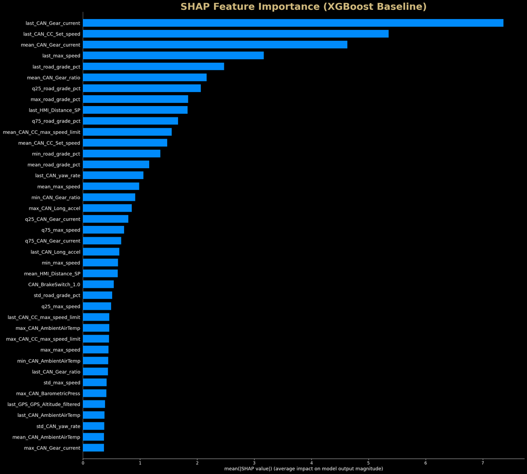

```python
print("Loading notebook state from disk to ensure all variables are defined...")
state_file_path = sorted(CACHE_DIR.glob("notebook_state_after_section5.joblib"))[-1]
notebook_state = joblib.load(state_file_path)
globals().update(notebook_state)
print("State loaded successfully.")

# --- Recreate feature mappings using the loaded state ---
effective_names = [RENAME_MAP.get(c, c) for c in SELECTED_COLUMNS]
cols_to_exclude = ['corrected_time', 'road_class', 'HMI_CACC_Status', 'fuel_inst', 'fuel_smooth']
feature_names = [name for name in effective_names if name not in cols_to_exclude]
feature_to_idx = {name: i for i, name in enumerate(feature_names)}
numeric_feature_indices = [
    feature_to_idx[c] for c in feature_names
    if SCHEMA[SCHEMA['column'] == c]['role'].iloc[0] in ['numeric', 'binary']
]
categorical_feature_indices = [
    feature_to_idx[c] for c in feature_names
    if SCHEMA[SCHEMA['column'] == c]['role'].iloc[0] == 'categorical'
]

# Load the entire validation set into memory for SHAP analysis.
print("Loading validation set into memory for SHAP analysis...")
X_val_xgb_paths = sorted((CACHE_DIR / "Validation_xgb_parts").glob("X_*.npy"))
X_val_xgb = np.concatenate([np.load(f, allow_pickle=True) for f in tqdm(X_val_xgb_paths, desc="Loading X_val_xgb")])

# Reload the encoder to get feature names.
encoder_path = sorted(CACHE_DIR.glob("*_onehot_encoder.joblib"))[-1]
encoder = joblib.load(encoder_path)

# Create the full list of feature names for the SHAP explainer.
stat_names = ['mean', 'std', 'min', 'max', 'last', 'q25', 'q75']
num_feature_names = [f"{stat}_{name}" for stat in stat_names for name in np.array(feature_names)[numeric_feature_indices]]
if categorical_feature_indices:
    cat_feature_names = encoder.get_feature_names_out(np.array(feature_names)[categorical_feature_indices])
    final_feature_names = num_feature_names + list(cat_feature_names)
else:
    final_feature_names = num_feature_names

# Explain the model's predictions using a sample of the validation data for speed.
print("Calculating SHAP values on a sample of the validation set...")
explainer = shap.TreeExplainer(xgb_baseline)
shap_sample = shap.sample(X_val_xgb, 20000, random_state=SEED)
shap_values = explainer.shap_values(shap_sample)

print("Generating SHAP summary plot...")
shap.summary_plot(
    shap_values, shap_sample, feature_names=final_feature_names,
    plot_type="bar", max_display=40, show=False
)

# Get the current figure and axes after SHAP has plotted.
fig = plt.gcf()
ax = plt.gca()
fig.set_size_inches(20, 18)

# Apply final styling touches.
fig.set_facecolor("black")
ax.set_facecolor("black")
ax.tick_params(colors='white')
ax.xaxis.label.set_color('white')
ax.yaxis.label.set_color('white')
ax.set_title("SHAP Feature Importance (XGBoost Baseline)", color="#CFB87C", fontsize=26, fontweight="bold")
for spine in ax.spines.values():
    spine.set_edgecolor("white")

# Save the figure and display the plot.
save_fig(fig, "xgb_shap_summary")
plt.show()
```

### 7.5 SHAP Dependence Plots

```
----------------------------------------------------------------------
--- SHAP Dependence (3 fixed pairs) ---
Figure saved (Linux): /home/treinart/projects/ADAS_fuel_rate/artifacts/figures/20250925_234638_shap_dependence_last_road_grade_pct_compact3.png
```

[figure not shown]

```
Figure saved (Linux): /home/treinart/projects/ADAS_fuel_rate/artifacts/figures/20250925_234638_shap_dependence_last_CAN_CC_Set_speed_compact3.png
```

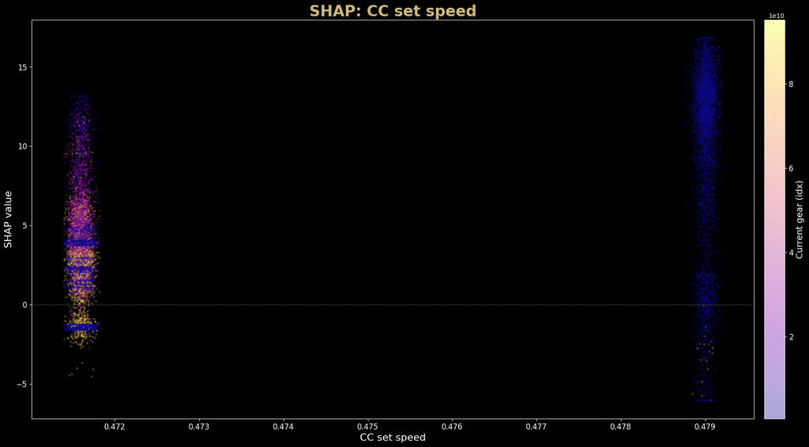

```
Figure saved (Linux): /home/treinart/projects/ADAS_fuel_rate/artifacts/figures/20250925_234639_shap_dependence_last_max_speed_compact3.png
```

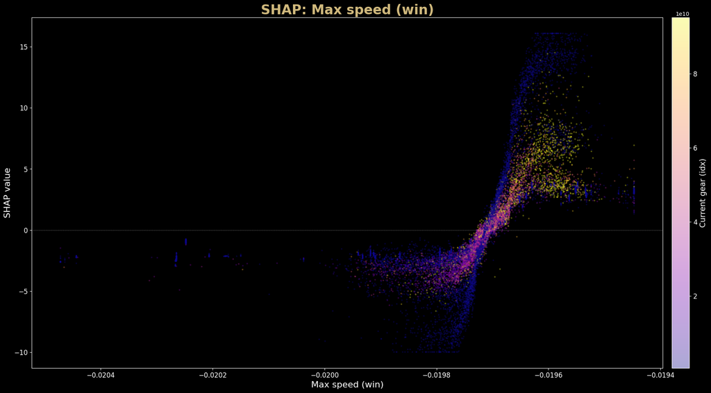

```
Completed 3 dependence plots.
```

```python
# --- Section 7.5: Interpret Model with SHAP (Dependence Plots) ---

# Define compact display names for plot labels.
compact = {
    'last_road_grade_pct':   'Road grade (%)',
    'last_CAN_v_speed':      'Vehicle speed (km/h)',
    'last_engine_load_pct':  'Engine load (%)',
    'last_CAN_CC_Set_speed': 'CC set speed',
    'last_CAN_Gear_current': 'Current gear (idx)',
    'last_max_speed':        'Max speed (win)',
}

# Select specific feature pairs for dependence plots.
pairs = [
    ('last_road_grade_pct',   'last_CAN_v_speed'),
    ('last_CAN_CC_Set_speed', 'last_CAN_Gear_current'),
    ('last_max_speed',        'last_CAN_Gear_current'),
]

# Ensure the inverse-scaled DataFrame exists for readable axes.
if 'shap_sample_df' not in globals():
    stat_names = ['mean', 'std', 'min', 'max', 'last', 'q25', 'q75']
    stats_scaler_path = sorted(CACHE_DIR.glob("*_stats_scaler.joblib"))[-1]
    stats_scaler = joblib.load(stats_scaler_path)
    shap_sample_df = pd.DataFrame(shap_sample, columns=final_feature_names)
    stats_cols_idx = [i for i, f in enumerate(final_feature_names) if any(s in f for s in stat_names)]
    if stats_cols_idx:
        X_stats_scaled = shap_sample[:, stats_cols_idx]
        X_stats_back = stats_scaler.inverse_transform(X_stats_scaled)
        shap_sample_df.iloc[:, stats_cols_idx] = X_stats_back

print("-" * 70)
print("--- SHAP Dependence (3 fixed pairs) ---")

# Subsample the data for faster, clearer plotting.
max_points = 120_000
n_rows = min(shap_sample_df.shape[0], shap_values.shape[0])
rng = np.random.default_rng(SEED)
take = min(max_points, n_rows)
idx = rng.choice(n_rows, size=take, replace=False)

# Generate a dependence plot for each selected feature pair.
made = 0
for x_feat, c_feat in pairs:
    # Check for missing features.
    if x_feat not in final_feature_names or c_feat not in final_feature_names:
        print(f"[Skip] Missing feature(s): {x_feat} or {c_feat}")
        continue

    # Extract the unscaled feature, SHAP, and interaction values.
    xi = final_feature_names.index(x_feat)
    ci = final_feature_names.index(c_feat)
    x = shap_sample_df.iloc[idx, xi].to_numpy()
    y = shap_values[idx, xi]
    c = shap_sample_df.iloc[idx, ci].to_numpy()

    # Create a mask to handle non-finite values.
    mask = np.isfinite(x) & np.isfinite(y) & np.isfinite(c)
    if mask.sum() == 0:
        print(f"[Skip] No finite data for {x_feat}")
        continue
    x, y, c = x[mask], y[mask], c[mask]

    # Add light jitter to quasi-discrete features to prevent overlap.
    if np.unique(x).size <= 6:
        iqr = np.subtract(*np.nanpercentile(x, [75, 25]))
        spread = iqr if np.isfinite(iqr) and iqr > 0 else (np.nanstd(x) or 1.0)
        eps = spread * 0.01
        x = x + rng.normal(0.0, eps, size=x.shape)

    # Skip plots with no variance.
    if np.nanstd(x) < 1e-9 or np.nanstd(y) < 1e-12:
        print(f"[Skip] Degenerate variance for {x_feat}")
        continue

    # Define a clipping function for axis and color limits.
    def pclip(arr, lo=0.2, hi=99.8):
        a, b = np.nanpercentile(arr, [lo, hi])
        a = a if np.isfinite(a) else np.nanmin(arr)
        b = b if np.isfinite(b) else np.nanmax(arr)
        if a == b:
            a -= 1e-6; b += 1e-6
        return np.clip(arr, a, b), (a, b)

    # Clip the plot data to the 1st-99th percentile for better visualization.
    x_plot, _ = pclip(x)
    y_plot, _ = pclip(y)
    c_plot, _ = pclip(c, 1, 99)

    # --- Plotting ---
    # Create the plot figure and axes.
    fig, ax = plt.subplots(figsize=(20, 10), facecolor="black")
    ax.set_facecolor("black")

    # Plot the data points.
    sc = ax.scatter(
        x_plot, y_plot, c=c_plot,
        s=8, alpha=0.35, cmap="plasma", edgecolors="none"
    )

    # Get compact names for labels.
    x_label = compact.get(x_feat, x_feat)
    c_label = compact.get(c_feat, c_feat)

    # Set the plot title.
    ax.set_title(f"SHAP: {x_label}", fontsize=24, color="#CFB87C", fontweight="bold", pad=6)

    # Set axis labels.
    ax.set_xlabel(x_label, fontsize=16, color="white")
    ax.set_ylabel("SHAP value", fontsize=16, color="white")

    # Add a horizontal line at y=0 for reference.
    ax.axhline(0, color="white", lw=0.8, ls=":", alpha=0.6)

    # Style the axis ticks.
    ax.tick_params(colors="white", labelsize=12)

    # Style the plot's border (spines).
    for spine in ax.spines.values():
        spine.set_edgecolor("white")

    # Add and style the color bar.
    cbar = plt.colorbar(sc, ax=ax, pad=0.012)
    cbar.set_label(c_label, color="white", fontsize=14)
    cbar.ax.tick_params(colors="white", labelsize=12)
    cbar.outline.set_edgecolor("white")

    # Ensure the layout is tight and clean.
    plt.tight_layout()

    # Save the figure.
    save_fig(fig, f"shap_dependence_{x_feat}_compact3")

    # Display the plot.
    plt.show()
    made += 1

# Print a confirmation.
print(f"Completed {made} dependence plots.")
```

### 7.6 Finalizing the Deep Learning Feature List

This cell achieves the primary goal of the baseline analysis. It programmatically aggregates the SHAP values from the engineered statistical features back to their original source channels. The result is a ranking of the most impactful sensor signals, which is then visualized and used to select the final list of the top 40 channels for the deep learning model.

```
Figure saved (Linux): /home/treinart/projects/ADAS_fuel_rate/artifacts/figures/20250925_235001_xgb_shap_aggregated_importance_dotplot.png
```

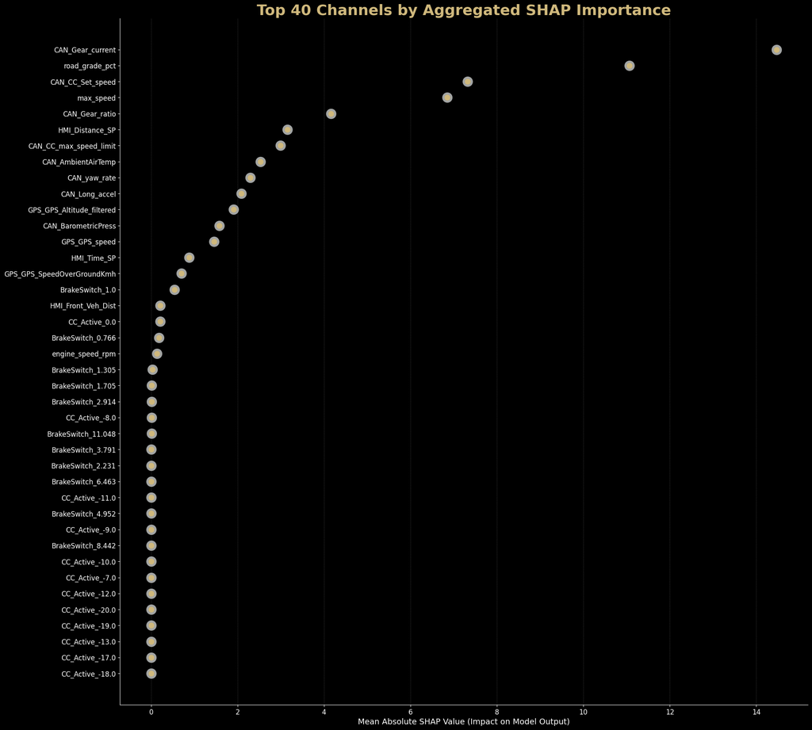

```python
# Aggregate SHAP importances by their original source channel.
shap_df = pd.DataFrame({'feature': final_feature_names, 'importance': np.abs(shap_values).mean(axis=0)})
shap_df['source_channel'] = shap_df['feature'].apply(lambda x: '_'.join(x.split('_')[1:]) if x.startswith('last_') else x.split('_', 1)[1])
channel_importance = shap_df.groupby('source_channel')['importance'].sum().sort_values(ascending=True)

# Select the top N channels for the deep learning model.
N_TOP_CHANNELS = 40
data_to_plot = channel_importance.tail(N_TOP_CHANNELS)
final_dl_channels = data_to_plot.index.tolist()[::-1]

# Create the Dot Plot visualization.
fig, ax = plt.subplots(figsize=(20, 18), facecolor="black")
ax.set_facecolor("black")
ax.scatter(data_to_plot.values, data_to_plot.index, s=200, color='#CFB87C', alpha=1.0, zorder=6, edgecolor='#A2A4A3', linewidth=4)

# Style the plot.
ax.set_title(f"Top {N_TOP_CHANNELS} Channels by Aggregated SHAP Importance", fontsize=26, color="#CFB87C", fontweight="bold")
ax.set_xlabel("Mean Absolute SHAP Value (Impact on Model Output)", fontsize=14, color="white")
ax.tick_params(colors='white', labelsize=12)
ax.grid(axis='x', color='gray', linestyle='--', linewidth=0.5, alpha=0.5)
for spine_loc in ['top', 'right']: ax.spines[spine_loc].set_visible(False)
for spine_loc in ['bottom', 'left']: ax.spines[spine_loc].set_edgecolor("white")

# Save the figure and display the plot.
save_fig(fig, "xgb_shap_aggregated_importance_dotplot")
plt.show()
```

### *Observation:* XGBoost Baseline & SHAP Feature Selection

This section looked straightforward on paper: train a baseline XGBoost model, then use SHAP to pick features for the deep learning stage. After all the data engineering work in previous sections, I expected this to be more routine. It turned out to have some real challenges mixed with solid wins.

The first attempt at loading data for training crashed the kernel immediately. I had assumed validation and test sets were small enough to load into memory after all the work in Sections 5 and 6, but that wasn't the case. This forced me to refactor the entire section to use an incremental approach for everything, which initially felt like a setback but actually made the whole pipeline better.

The incremental training worked but took about 90 minutes. That was a substantial wait, but it gave me time to work on documentation and planning for the next section. When that "Checkpoint saved" message finally appeared, it felt really good knowing that specific training step was done for good.

After the long training run, I hit some `NameError` s in the evaluation cells when restarting kernels. This was frustrating since it meant the cells weren't properly resumable, but it finally pushed me to implement the "load state" architecture I should have had from the beginning. The reload functionality from the 5.5 checkpoints really paid off here - whenever I had kernel issues, I could pick up right where I left off just by rerunning section 2, which saved tons of time.

The SHAP dependence plots were where things got interesting. Library version issues forced me into a `plt.gcf()` workaround that felt clumsy. Then I started getting these bizarre "single dot" plots - the visualizations for speed and load were rendering as single points instead of distributions. The code ran without errors but produced completely useless output.

My attempts to fix the plotting led to a cascade of new errors: `IndexErrors`, `AssertionErrors`, and more kernel crashes from trying to inverse-transform too much data at once. It felt like each fix created two new problems.

The breakthrough came when I realized the issue was with my data sample for the plots. It wasn't diverse enough to show meaningful patterns. Building custom plotting code with stratified sampling and jitter took some work, but once it was running, the plots finally started telling the real story about feature relationships.

This section was a mix of memory management challenges, architecture decisions, and some tricky data visualization debugging. But the final aggregated SHAP results delivered exactly what I needed: a clean, data-driven ranking of the most important features that gave me a solid foundation for designing the deep learning model.

#### Baseline Performance:

- **Status.** **Val MAE = 5.5281**.
- **Slice performance (validation).** Downhill MAE ~2.28 (high MAPE due to tiny targets), Flat MAE ~5.71, Uphill MAE ~2.87 (again high pct error on small denominators). Absolute error behaves, percent error inflates where fuel is near zero.
- **SHAP summary (feature-level).** Top drivers align with intuition: *last_CAN_Gear_current*, *last_CAN_CC_Set_speed*, *mean_CAN_Gear_current*, *last_max_speed*, and road-grade stats dominate.
- **Dependence views (clean sample).**
  - **Road grade (%):** SHAP rises sharply on positive grades (fuel cost of climbs), muted/negative on flats/descents.
  - **CC set speed:** Two dense bands reflect common setpoints, higher setpoints push SHAP positive, modulated by gear index.
  - **Max speed (win):** Clear S-curve - beyond a threshold, faster windows drive fuel upward.
- **Aggregated importance (channel-level) vs. SHAP summary - why they look similar:** the SHAP **summary** ranks *individual engineered features* (e.g., *mean/max/last* of a channel). The **aggregated dot plot** groups those siblings back to their *source channel* (e.g., all stats of *CAN_Gear_current* collapsed to one point). Because the same channels dominate across their stats, the two plots show a *similar ordering* - that’s expected, not a bug. The dot plot is coarser (channel importance), the summary is finer (feature importance).
- **Outcome.** The analysis shows a data-driven short-list for the DL model: gear, grade, CC set speed/limit, max speed, distance headway, and load/speed dynamics rise to the top.

## Section 8: Deep Learning Model - CNN→GRU

This section builds and trains the primary deep learning model. The architecture is a hybrid Convolutional Neural Network (CNN) followed by a Gated Recurrent Unit (GRU), designed to learn complex temporal patterns from the 10-second data windows. The process uses a training pipeline with PyTorch, a learning rate scheduler, and early stopping to find the best model, which is then saved for final analysis.

### Section Plan:

1. **Setup for Deep Learning:** Load the saved notebook state and inventory the processed data part-files.
2. **PyTorch Dataset & DataLoaders:** Build a custom, memory-safe data pipeline for handling the 117 GB dataset.
3. **Model Definition & Training Loop:** Define the CNN→GRU architecture and run the main training loop with checkpointing.
4. **Save Training Artifacts & Load Best Model:** Save the model weights, history, and config to a unique run folder.
5. **Plotting the Learning Curves:** Visualize the training and validation loss to diagnose model convergence.
6. **Prediction & Calibration Analysis:** Generate predictions and create a calibration plot to assess model accuracy.
7. **Performance Analysis by Operational Slice:** Break down the final model's performance across key driving conditions.

### 8.1 Setup for Deep Learning

To make the notebook resumable, this cell begins by loading the complete state saved at the end of Section 5. It then inventories the processed deep learning data part-files from Section 6 and recreates all necessary feature mappings. This ensures the environment is fully configured for the training and analysis that follows.

```python
# Load the general notebook state.
print("Loading notebook state from disk...")
state_file_path = sorted(CACHE_DIR.glob("notebook_state_after_section5.joblib"))[-1]
notebook_state = joblib.load(state_file_path)
globals().update(notebook_state)
print(f"State loaded successfully from {state_file_path.name}")

# Recreate the feature-to-index mappings using the loaded variables.
effective_names = [RENAME_MAP.get(c, c) for c in SELECTED_COLUMNS]
cols_to_exclude = ['corrected_time', 'road_class', 'HMI_CACC_Status', 'fuel_inst', 'fuel_smooth']
feature_names = [name for name in effective_names if name not in cols_to_exclude]

# Find the paths to the processed deep learning and target data parts from Section 6.
X_train_dl_paths = sorted((CACHE_DIR / "Train_dl_parts").glob("X_*.npy"))
y_train_paths = sorted((CACHE_DIR / "Train_y_parts").glob("y_*.npy"))
X_val_dl_paths = sorted((CACHE_DIR / "Validation_dl_parts").glob("X_*.npy"))
y_val_paths = sorted((CACHE_DIR / "Validation_y_parts").glob("y_*.npy"))
X_test_dl_paths = sorted((CACHE_DIR / "Test_dl_parts").glob("X_*.npy"))
y_test_paths = sorted((CACHE_DIR / "Test_y_parts").glob("y_*.npy"))

# Print a summary.
print("-" * 70)
print("--- Setup Complete for Deep Learning ---")
print("All configurations and data paths are now loaded into memory.")
print(f"Found {len(X_train_dl_paths)} training part-files to be processed.")
print("-" * 70)

# --- Calculate Total Training Set Size on Disk ---

# Check available disk space
print("--- Check available disk space ---")
!df -h

# Find all the part-files for the training set.
x_train_files = sorted((CACHE_DIR / "Train_dl_parts").glob("X_*.npy"))
y_train_files = sorted((CACHE_DIR / "Train_y_parts").glob("y_*.npy"))
all_train_files = x_train_files + y_train_files

# Sum the size of each file on disk.
total_bytes = sum(p.stat().st_size for p in all_train_files)
total_gigabytes = total_bytes / (1024**3)

# Print the final result.
print("\n--- Training Set Size Calculation ---")
print(f"Total size on disk: {total_gigabytes:.2f} GB")
print("-" * 70)
```

```
Loading notebook state from disk...
State loaded successfully from notebook_state_after_section5.joblib
----------------------------------------------------------------------
--- Setup Complete for Deep Learning ---
All configurations and data paths are now loaded into memory.
Found 42 training part-files to be processed.
----------------------------------------------------------------------
--- Check available disk space ---
Filesystem      Size  Used Avail Use% Mounted on
none             16G     0   16G   0% /usr/lib/modules/6.6.87.2-microsoft-standard-WSL2
none             16G  4.0K   16G   1% /mnt/wsl
drivers         1.9T  1.4T  451G  76% /usr/lib/wsl/drivers
/dev/sdd       1007G  485G  472G  51% /
none             16G   88K   16G   1% /mnt/wslg
none             16G     0   16G   0% /usr/lib/wsl/lib
rootfs           16G  2.7M   16G   1% /init
none             16G  616K   16G   1% /run
none             16G     0   16G   0% /run/lock
none             16G  377M   16G   3% /run/shm
none             16G   76K   16G   1% /mnt/wslg/versions.txt
none             16G   76K   16G   1% /mnt/wslg/doc
C:\             1.9T  1.4T  451G  76% /mnt/c
D:\             3.7T  551G  3.2T  15% /mnt/d
tmpfs            16G   12K   16G   1% /run/user/1000

--- Training Set Size Calculation ---
Total size on disk: 117.11 GB
----------------------------------------------------------------------
```

### 8.2 PyTorch Dataset & DataLoaders

Handling the 117 GB dataset requires a custom data pipeline. This cell defines a PyTorch `SequenceDataset` that uses memory-mapping to "lazy load" data directly from the disk. This is a memory-safe approach that prevents kernel crashes. The datasets are then wrapped in `DataLoaders` with optimized settings to feed data to the GPU during training.

```python
# Use a memory-mapped Dataset to prevent DataLoader crashes
class SequenceDataset(Dataset):
    def __init__(self, x_paths, y_paths):
        super().__init__()
        self.x_parts = [np.load(p, mmap_mode='r') for p in x_paths]
        self.y_parts = [np.load(p, mmap_mode='r') for p in y_paths]
        self.cumulative_sizes = [0]
        for part in self.y_parts:
            self.cumulative_sizes.append(self.cumulative_sizes[-1] + part.shape[0])
        self.total_samples = self.cumulative_sizes[-1]

    def __len__(self):
        return self.total_samples

    def __getitem__(self, idx):
        file_idx = np.searchsorted(self.cumulative_sizes, idx, side='right') - 1
        local_idx = idx - self.cumulative_sizes[file_idx]
        x_window = self.x_parts[file_idx][local_idx].copy()
        y_target = self.y_parts[file_idx][local_idx].copy()
        x_window = np.nan_to_num(x_window, nan=0.0, posinf=0.0, neginf=0.0)
        y_target = np.nan_to_num(y_target, nan=0.0, posinf=0.0, neginf=0.0)
        return torch.from_numpy(x_window).float(), torch.from_numpy(y_target).float()

# Create Dataset instances.
train_dataset = SequenceDataset(X_train_dl_paths, y_train_paths)
val_dataset = SequenceDataset(X_val_dl_paths, y_val_paths)
test_dataset = SequenceDataset(X_test_dl_paths, y_test_paths)

# Create DataLoader instances with performance optimizations.
BATCH_SIZE = 256
train_loader = DataLoader(
    train_dataset, batch_size=BATCH_SIZE, shuffle=True, num_workers=24,
    pin_memory=True, persistent_workers=True, drop_last=True
)
val_loader = DataLoader(
    val_dataset, batch_size=BATCH_SIZE * 2, shuffle=False, num_workers=24,
    pin_memory=True, persistent_workers=True
)
test_loader = DataLoader(test_dataset, batch_size=BATCH_SIZE * 2, shuffle=False, num_workers=4)

# Print a summary.
print("-" * 70)
print("--- Datasets and DataLoaders Ready ---")
sample_x, _ = next(iter(train_loader))
vram_gb = (sample_x.element_size() * sample_x.nelement()) / (1024**3)
print(f"Total training windows: {len(train_dataset):,}")
print(f"Total validation windows: {len(val_dataset):,}")
print(f"Batch shape (X): {sample_x.shape}")
print(f"Effective batch size (VRAM): {vram_gb:.3f} GB")
print(f"Train loader drop_last=True is active.")
print("-" * 70)
```

```
----------------------------------------------------------------------
--- Datasets and DataLoaders Ready ---
Total training windows: 13,087,466
Total validation windows: 1,833,856
Batch shape (X): torch.Size([256, 100, 24])
Effective batch size (VRAM): 0.002 GB
Train loader drop_last=True is active.
----------------------------------------------------------------------
```

### 8.3 Model Definition & Training Loop

This is the main event. This cell contains the complete, self-contained script for training the deep learning model. It defines the CNN→GRU architecture, sets up the optimizer and learning rate scheduler, and runs the main training loop. The loop includes features like mixed-precision training, early stopping, and saving the best model weights to a checkpoint file.

#### Note on the *Valid MAPE: nan%* readout:

I’m aware the Epoch training printout shows *Valid MAPE: nan%*. By the time I got this loop debugged and stable it was ~1 a.m., and I only checked that the cell ran without errors through Epoch 1. I noticed the *Valid MAPE: nan%* the next morning after several hours of training.

After seeing the issue I looked into what I might have messed up. I don’t think this is a model failure, I think it’s a metric quirk. The validation set includes stretches where the truck is idling or coasting, so the true fuel rate is at or near zero. MAPE divides by the true value, and even a handful of near-zeros in a batch can blow up the denominator and produce NaN for that batch’s average.

For this run I’m leaving the training output as is. It doesn’t affect training or checkpoints, and MAE (the primary objective) is valid. In later sections I plan to compute final metrics with a small epsilon/mask around zero, so the reported MAPE there will be correct. If I re-run this cell in the future I’ll either drop the streaming MAPE line or make it handle near-zero targets.

```python
# Define the Model Architecture
class CNNGRUModel(nn.Module):
    def __init__(self, in_channels, gru_hidden_size=128, num_gru_layers=1, dropout_prob=0.2):
        super().__init__()
        self.in_channels = in_channels
        self.conv1d = nn.Conv1d(in_channels=in_channels, out_channels=64, kernel_size=5, padding='same')
        self.relu = nn.ReLU()
        self.dropout1 = nn.Dropout(dropout_prob)
        self.gru = nn.GRU(input_size=64, hidden_size=gru_hidden_size, num_layers=num_gru_layers, batch_first=True)
        self.dropout2 = nn.Dropout(dropout_prob)
        self.fc = nn.Linear(gru_hidden_size, 2)
        self._init_weights()

    def _init_weights(self):
        for name, param in self.named_parameters():
            if 'conv' in name and 'weight' in name: nn.init.kaiming_normal_(param, mode='fan_in', nonlinearity='relu')
            elif 'gru' in name and 'weight' in name: nn.init.orthogonal_(param)
            elif 'fc' in name and 'weight' in name: nn.init.xavier_uniform_(param)

    def forward(self, x):
        assert x.ndim == 3 and x.shape[2] == self.in_channels, f"Input shape error: expected [B, T, {self.in_channels}], got {x.shape}"
        x = x.permute(0, 2, 1); x = self.relu(self.conv1d(x)); x = self.dropout1(x)
        x = x.permute(0, 2, 1); x, _ = self.gru(x)
        x = self.dropout2(x[:, -1, :]); x = self.fc(x)
        return x

# Define the Training Configuration
BATCH_SIZE = 256
config = {
    'epochs': 50, 'learning_rate': 1e-3, 'weight_decay': 1e-4,
    'batch_size': BATCH_SIZE, 'patience': 8, 'grad_clip_norm': 1.0,
    'target_idx': 1, 'target_name': 'fuel_smooth', 'scheduler': 'OneCycleLR'
}

# Use the single, correct logic to define the feature list.
cols_to_exclude = ['corrected_time', 'road_class', 'HMI_CACC_Status']
feature_names_source = [c for c in SELECTED_COLUMNS if c not in cols_to_exclude]
feature_names = [RENAME_MAP.get(name, name) for name in feature_names_source]
num_dl_features = len(feature_names)

# Reproducibility
random.seed(SEED); np.random.seed(SEED); torch.manual_seed(SEED)
if torch.cuda.is_available(): torch.cuda.manual_seed_all(SEED)
torch.backends.cudnn.deterministic = True; torch.backends.cudnn.benchmark = False

# Create Run Folder
ts = _timestamp()
RUN_FOLDER = CACHE_DIR / f"runs/{ts}_{config['target_name']}"
RUN_FOLDER.mkdir(parents=True, exist_ok=True)
best_model_path = RUN_FOLDER / "best_model.pth"

# Instantiate Model and Initialize Components
model = CNNGRUModel(in_channels=num_dl_features)
device = torch.device("cuda" if torch.cuda.is_available() else "cpu")
model.to(device)
optimizer = optim.AdamW(model.parameters(), lr=config['learning_rate'], weight_decay=config['weight_decay'])
scheduler = optim.lr_scheduler.OneCycleLR(optimizer, max_lr=config['learning_rate'], steps_per_epoch=len(train_loader), epochs=config['epochs'])
loss_fn = nn.L1Loss()
scaler = GradScaler(enabled=torch.cuda.is_available())

# Define Training and Validation Functions
def train_one_epoch(loader, model, optimizer, loss_fn, scaler, scheduler, device, clip_norm, epoch):
    model.train(); total_loss = 0.0
    p_tr = tqdm(loader, desc=f"TRAIN Epoch {epoch:02d}", unit="batch", leave=True, dynamic_ncols=True)
    for X_batch, y_batch in p_tr:
        X_batch, y_batch = X_batch.to(device), y_batch.to(device)[:, config['target_idx']]
        with autocast(enabled=torch.cuda.is_available()):
            preds = model(X_batch)[:, config['target_idx']]
            loss = loss_fn(preds, y_batch)
        optimizer.zero_grad(set_to_none=True); scaler.scale(loss).backward()
        scaler.unscale_(optimizer); torch.nn.utils.clip_grad_norm_(model.parameters(), clip_norm)
        scaler.step(optimizer); scaler.update();
        if scheduler: scheduler.step()
        total_loss += loss.item()
        p_tr.set_postfix_str(f"loss={total_loss/len(p_tr):.5f}")
    return total_loss / len(loader)

def validate_one_epoch(loader, model, loss_fn, device, epoch):
    model.eval(); total_loss, total_mape = 0.0, 0.0
    p_va = tqdm(loader, desc=f"VALID Epoch {epoch:02d}", unit="batch", leave=True, dynamic_ncols=True)
    with torch.no_grad():
        for X_batch, y_batch_full in p_va:
            X_batch, y_batch_full = X_batch.to(device), y_batch_full.to(device)
            y_batch_target = y_batch_full[:, config['target_idx']]
            with autocast(enabled=torch.cuda.is_available()):
                preds = model(X_batch)[:, config['target_idx']]
            loss = loss_fn(preds, y_batch_target)
            total_loss += loss.item()
            mape_mask = y_batch_full[:, 0] > 1e-6
            mape_preds = model(X_batch)[:, 0]
            total_mape += (torch.abs((mape_preds - y_batch_full[:, 0])[mape_mask]) / y_batch_full[:, 0][mape_mask]).mean().item() * 100
            p_va.set_postfix_str(f"loss={total_loss/len(p_va):.5f}")
    return total_loss / len(loader), total_mape / len(loader)

# Run the Main Training Loop
print("-" * 70); print(f"--- Starting Training ---"); print(f"Device: {device.type.upper()} | Saving artifacts to: {RUN_FOLDER.name}"); print("-" * 70)
history = []; best_val_mae = float('inf'); patience_counter = 0; best_epoch = 0

for epoch in range(config['epochs']):
    epoch_start = systime.time()
    train_mae = train_one_epoch(train_loader, model, optimizer, loss_fn, scaler, scheduler, device, config['grad_clip_norm'], epoch + 1)
    val_mae, val_mape = validate_one_epoch(val_loader, model, loss_fn, device, epoch + 1)
    epoch_time = systime.time() - epoch_start

    lr = optimizer.param_groups[0]['lr']
    history.append({'Epoch': epoch, 'Train MAE': train_mae, 'Valid MAE': val_mae, 'Valid MAPE': val_mape, 'Learning Rate': lr})

    bps = len(train_loader) / epoch_time if epoch_time > 0 else 0.0
    print(f"Epoch {epoch+1:02d}/{config['epochs']} | Train MAE: {train_mae:.5f} | Valid MAE: {val_mae:.5f} | Valid MAPE: {val_mape:.2f}% | Learning Rate: {lr:.2e} | Time: {epoch_time:.2f}s | {bps:.1f} batches/s")

    if val_mae < best_val_mae:
        best_val_mae, best_epoch = val_mae, epoch + 1
        patience_counter = 0
        torch.save(model.state_dict(), best_model_path)
        torch.save(optimizer.state_dict(), RUN_FOLDER / "optimizer.pth")
        print(f"  -> New best validation MAE. Checkpoint saved.")
    else:
        patience_counter += 1
        if patience_counter >= config['patience']:
            print(f"\nEarly stopping triggered. Best epoch was {best_epoch} with Val MAE {best_val_mae:.4f}.")
            break
```

```
----------------------------------------------------------------------
--- Starting Training ---
Device: CUDA | Saving artifacts to: 20250926_011510_fuel_smooth
----------------------------------------------------------------------
```

```
  -> New best validation MAE. Checkpoint saved.
```

```
  -> New best validation MAE. Checkpoint saved.
```

```
  -> New best validation MAE. Checkpoint saved.
```

```
  -> New best validation MAE. Checkpoint saved.
```

```
  -> New best validation MAE. Checkpoint saved.
```

```
  -> New best validation MAE. Checkpoint saved.
```

```
Early stopping triggered. Best epoch was 11 with Val MAE 2.8367.
```

### 8.4 Save Training Artifacts & Load Best Model

For reproducibility, all outputs from the training run are saved to a timestamped folder. This cell saves the full training history, the final model configuration, and an environment snapshot. It concludes by loading the weights of the best-performing model from the saved checkpoint, making it ready for evaluation.

```python
# Create a hash of the training data filenames for an integrity check.
train_files_str = "".join(sorted([p.name for p in X_train_dl_paths]))
data_hash = hashlib.sha256(train_files_str.encode()).hexdigest()

# Add final results and environment info to the config dictionary.
config['best_val_mae'] = best_val_mae
config['best_epoch'] = best_epoch
config['stopped_epoch'] = len(history)
config['data_train_parts'] = len(X_train_dl_paths)
config['data_sha256_hash'] = data_hash

env_info = {
    'torch_version': torch.__version__, 'cuda_version': torch.version.cuda,
    'gpu_name': torch.cuda.get_device_name(0) if torch.cuda.is_available() else 'CPU'
}

# Save all artifacts to the run folder.
with open(RUN_FOLDER / "history.json", 'w') as f: json.dump(history, f, indent=2)
with open(RUN_FOLDER / "config.json", 'w') as f: json.dump(config, f, indent=2)
with open(RUN_FOLDER / "env.json", 'w') as f: json.dump(env_info, f, indent=2)

# Load the best performing model weights from the checkpoint.
model.load_state_dict(torch.load(best_model_path))

print("-" * 70)
print("--- Artifacts Saved and Best Model Loaded ---")
print(f"Final training history and configs saved to '{RUN_FOLDER.name}'.")
print(f"Loaded best model weights from epoch {best_epoch}.")
print("-" * 70)
```

```
----------------------------------------------------------------------
--- Artifacts Saved and Best Model Loaded ---
Final training history and configs saved to '20250926_011510_fuel_smooth'.
Loaded best model weights from epoch 11.
----------------------------------------------------------------------
```

### 8.5 Plotting the Learning Curves

This plot provides the primary diagnostic for the training process. It shows the model's Mean Absolute Error on both the training and validation sets at each epoch. This visualization allows for a quick assessment of model convergence and helps identify potential issues like overfitting. A line for the XGBoost baseline is included for a direct performance comparison.

```
XGBoost baseline MAE loaded for comparison: 5.5281
Figure saved (Linux): /home/treinart/projects/ADAS_fuel_rate/artifacts/figures/20250926_081832_dl_learning_curves.png
```

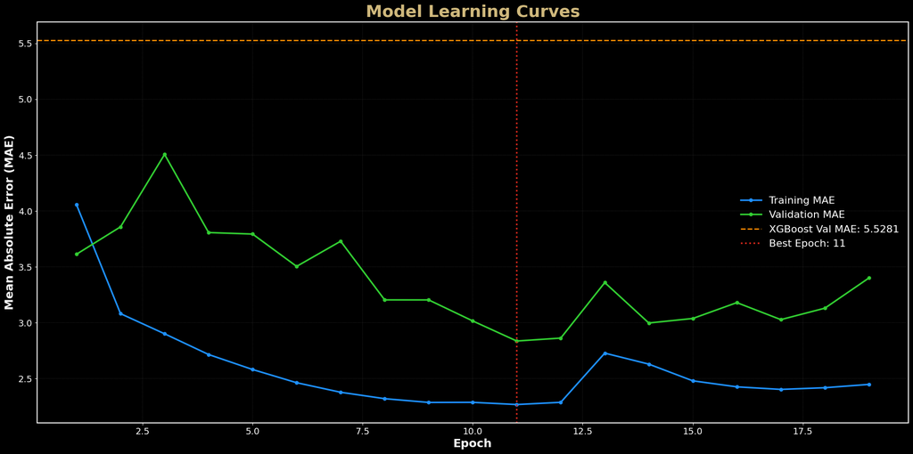

```python
# Load the training history and config from the run folder.
with open(RUN_FOLDER / "history.json", 'r') as f: history = json.load(f)
with open(RUN_FOLDER / "config.json", 'r') as f: config = json.load(f)

# --- FIX: Load the XGBoost score directly using the correct filename ---
xgb_model_path = CACHE_DIR / "xgb_baseline_best.json"
best_score = None

if xgb_model_path.exists():
    # Instantiate a model object to load the saved model into.
    xgb_baseline_for_eval = XGBRegressor(tree_method='gpu_hist', random_state=SEED)
    xgb_baseline_for_eval.load_model(xgb_model_path)

    # Re-evaluate the model to get the score; this is fast.
    def evaluate_incrementally(model, x_paths, y_paths):
        all_preds, all_true = [], []
        for x_path, y_path in zip(x_paths, y_paths):
            X_part = np.load(x_path, allow_pickle=True); y_part = np.load(y_path, allow_pickle=True)[:, 0]
            preds = model.predict(X_part)
            all_preds.append(preds); all_true.append(y_part)
        return mean_absolute_error(np.concatenate(all_true), np.concatenate(all_preds))

    X_val_xgb_paths = sorted((CACHE_DIR / "Validation_xgb_parts").glob("X_*.npy"))
    y_val_paths = sorted((CACHE_DIR / "Validation_y_parts").glob("y_*.npy"))
    best_score = evaluate_incrementally(xgb_baseline_for_eval, X_val_xgb_paths, y_val_paths)
    print(f"XGBoost baseline MAE loaded for comparison: {best_score:.4f}")
else:
    print("XGBoost baseline model not found. Skipping comparison line in plot.")

# Create a DataFrame from the training history.
history_df = pd.DataFrame(history)
history_df['Epoch'] = history_df['Epoch'] + 1

# Create the plot figure and axes.
fig, ax = plt.subplots(figsize=(20, 10), facecolor="black")
ax.set_facecolor("black")

# Plot the training and validation loss curves.
ax.plot(history_df["Epoch"], history_df["Train MAE"], label="Training MAE", color='dodgerblue', lw=2.5, marker='o', markersize=5)
ax.plot(history_df["Epoch"], history_df["Valid MAE"], label="Validation MAE", color='limegreen', lw=2.5, marker='o', markersize=5)

# Add a horizontal line for the XGBoost baseline performance if it was found.
if best_score is not None:
    ax.axhline(best_score, color='darkorange', lw=2, ls='--', label=f'XGBoost Val MAE: {best_score:.4f}')

# Add a vertical line for the best epoch.
best_epoch_num = config.get('best_epoch', 0)
ax.axvline(best_epoch_num, color='#DA291C', lw=2.5, ls=':', label=f"Best Epoch: {best_epoch_num}")

# Style the plot.
ax.set_title("Model Learning Curves", fontsize=26, color="#CFB87C", fontweight="bold", pad=8)
ax.set_xlabel("Epoch", fontsize=18, color="#F8F8F8", fontweight="bold")
ax.set_ylabel("Mean Absolute Error (MAE)", fontsize=18, color="#F8F8F8", fontweight="bold")
ax.tick_params(colors="white", labelsize=14)
ax.legend(frameon=False, fontsize=16, labelcolor="white", loc="center right")
ax.grid(color='gray', linestyle='--', linewidth=0.3, alpha=0.5)
for spine in ax.spines.values():
    spine.set_edgecolor("white")
    spine.set_linewidth(1.5)

# Save and show the plot.
save_fig(fig, "dl_learning_curves")
plt.show()
```

### 8.6 Prediction & Calibration Analysis

This cell evaluates the final model's accuracy on the validation set. It first generates predictions for the entire set and saves them to disk. It then creates a 2D density plot of the model's predictions against the true fuel rate values. A perfect calibration line is included to provide a clear visual assessment of the model's accuracy and any systematic biases.

```
Generating predictions on the validation set...
```

```
----------------------------------------------------------------------
--- Final DL Model Performance (Validation Set) ---
Target: fuel_inst    | MAE: 18.2203 | MAPE: 98.25%  (on 83.7% of samples)
Target: fuel_smooth  | MAE: 2.8369 | MAPE: 25.39%  (on 94.3% of samples)
----------------------------------------------------------------------
Figure saved (Linux): /home/treinart/projects/ADAS_fuel_rate/artifacts/figures/20250926_083322_dl_calibration_plot.png
```

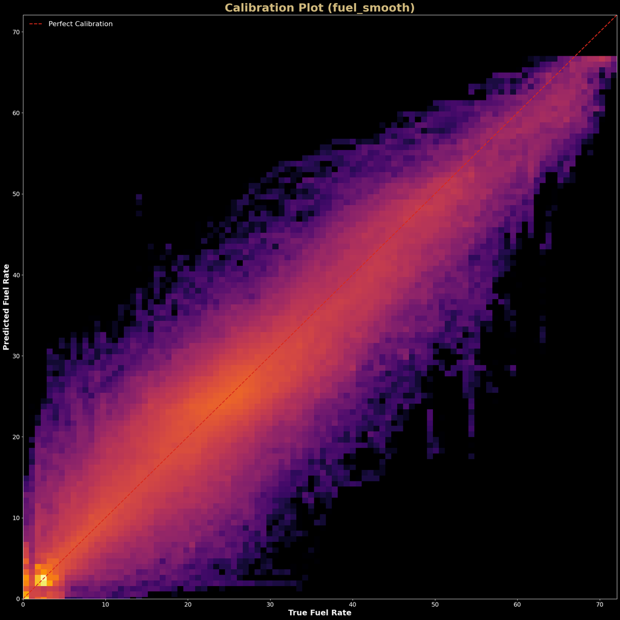

```python
# Generate predictions on the validation set.
print("Generating predictions on the validation set...")
model.eval()
all_preds, all_targets = [], []
with torch.no_grad():
    for X_batch, y_batch in tqdm(val_loader, desc="Predicting"):
        X_batch = X_batch.to(device)
        with autocast(enabled=torch.cuda.is_available()):
            preds = model(X_batch)
        all_preds.append(preds.cpu().numpy())
        all_targets.append(y_batch.numpy())

val_preds   = np.concatenate(all_preds)
val_targets = np.concatenate(all_targets)

# Save the predictions and targets to the run folder.
np.save(RUN_FOLDER / "val_preds.npy",   val_preds)
np.save(RUN_FOLDER / "val_targets.npy", val_targets)

print("\n" + "-" * 70)
print("--- Final DL Model Performance (Validation Set) ---")

# Stable MAPE.
MAPE_MIN_DENOM = 0.10  # L/h

for i, name in enumerate(['fuel_inst', 'fuel_smooth']):
    y_true = val_targets[:, i]
    y_pred = val_preds[:, i]

    mae = mean_absolute_error(y_true, y_pred)

    mask = np.abs(y_true) > MAPE_MIN_DENOM
    covered = mask.mean() * 100.0
    if mask.any():
        mape = mean_absolute_percentage_error(y_true[mask], y_pred[mask]) * 100.0
        mape_txt = f"{mape:.2f}%  (on {covered:.1f}% of samples)"
    else:
        mape_txt = f"N/A (0 samples > {MAPE_MIN_DENOM} L/h)"

    print(f"Target: {name: <12} | MAE: {mae:.4f} | MAPE: {mape_txt}")

print("-" * 70)

# Plot the calibration map for the primary trained target.
y_true = val_targets[:, config['target_idx']]
y_pred = val_preds[:, config['target_idx']]

fig, ax = plt.subplots(figsize=(20, 20), facecolor="black")
ax.set_facecolor("black")
ax.hist2d(y_true, y_pred, bins=100, cmap='inferno', norm=LogNorm())

m = max(y_true.max(), y_pred.max())
ax.plot([0, m], [0, m], color='#DA291C', ls='--', lw=2, label='Perfect Calibration')

# Style the plot.
ax.set_title(f"Calibration Plot ({config['target_name']})", fontsize=26, color="#CFB87C", fontweight="bold", pad=8)
ax.set_xlabel("True Fuel Rate",  fontsize=18, color="#F8F8F8", fontweight="bold")
ax.set_ylabel("Predicted Fuel Rate", fontsize=18, color="#F8F8F8", fontweight="bold")
ax.tick_params(colors='white', labelsize=14)
ax.legend(frameon=False, fontsize=16, labelcolor="white")
for spine in ax.spines.values():
    spine.set_edgecolor("white")
ax.set_xlim(0, m)
ax.set_ylim(0, m)

# Save and show.
save_fig(fig, "dl_calibration_plot")
plt.show()
```

### 8.7 Performance Analysis by Operational Slice

```python
print("\n" + "-" * 70)
print("--- DL Model Performance by Operational Slice ---")

# Build the dataframe
arr_last_steps = []
for f in tqdm(X_val_dl_paths, desc="Loading validation metadata"):
    arr_last_steps.append(np.load(f)[:, -1, :])
meta_val_df = pd.DataFrame(np.concatenate(arr_last_steps), columns=feature_names)
del arr_last_steps

# Bin & flags.
meta_val_df['grade_bin'] = pd.cut(
    meta_val_df['road_grade_pct'],
    bins=[-np.inf, -2, 2, np.inf],
    labels=['Downhill', 'Flat', 'Uphill']
)
meta_val_df['cruise_control'] = meta_val_df['CAN_CC_Active'].map({0: 'Off', 1: 'On'})

# Stable MAPE.
MAPE_MIN = 0.10

slice_results_dl = []
for col, name in tqdm([('grade_bin', 'Grade'), ('cruise_control', 'Cruise Control')],
                      desc="Evaluating slices"):
    unique_vals = meta_val_df[col].dropna().unique()
    for value in tqdm(unique_vals, desc=f"{name} values", leave=True):
        mask_slice = (meta_val_df[col] == value).to_numpy()
        if not mask_slice.any():
            continue

        yt = y_true[mask_slice]
        yp = y_pred[mask_slice]
        mae = mean_absolute_error(yt, yp)
        keep = np.abs(yt) >= MAPE_MIN
        coverage = float(keep.mean()) * 100.0

        if keep.any():
            mape = np.mean(np.abs((yt[keep] - yp[keep]) / yt[keep])) * 100.0
        else:
            mape = np.nan

        slice_results_dl.append({
            'Slice Group': name,
            'Slice Value': str(value),
            'MAE': mae,
            'MAPE (%)': mape,
            'Coverage (%)': coverage
        })

slice_df_dl = (
    pd.DataFrame(slice_results_dl)
      .sort_values(['Slice Group', 'Slice Value'])
      .round({'MAE': 3, 'MAPE (%)': 2, 'Coverage (%)': 1})
)
display(cubuff_style_table(slice_df_dl))
```

```
----------------------------------------------------------------------
--- DL Model Performance by Operational Slice ---
```

```
Cruise Control values: 0it [00:00, ?it/s]
```

| Slice Group | Slice Value | MAE | MAPE (%) | Coverage (%) |
| --- | --- | --- | --- | --- |
| Grade | Downhill | 0.410000 | 13.940000 | 100.000000 |
| Grade | Flat | 2.964000 | 25.800000 | 94.300000 |
| Grade | Uphill | 1.629000 | 48.050000 | 70.500000 |

### *Observation:* Deep Learning - CNN→GRU Training & Evaluation

This section was the main event, and it felt like the real payoff after all the data engineering work. The previous sections were about getting data into shape - this was about making the model actually work.

The first major hurdle was the `DataLoader`. Even with the part-file system, my initial attempts kept crashing the kernel with cryptic `DataLoader worker killed` errors. Classic memory bottleneck. The breakthrough was re-architecting the `SequenceDataset` to use `np.memmap` instead of `np.load`. This felt like a huge win - the final, correct solution that allowed the notebook to handle the massive 117 GB dataset without crashing. It also eliminated page-fault spikes and stabilized epoch-to-epoch time It's wild to think the 12.3 GB raw dataset expanded to that size, but it's a direct result of the overlapping windowing process, which duplicates each data point nearly 100 times.

Fixing the memory crashes immediately revealed the next challenge: a severe I/O bottleneck. The training was stable but painfully slow. The Task Manager told the whole story - the GPU was sitting at a lazy 28% utilization, completely starved for data, while the SSD was pegged at 100%.

**Screenshot running `num_workers=4`showing the GPU sits around ~28% while the NVMe SSD is pegged at ~100%. Clear disk-I/O bottleneck as the dataloader can’t feed the model fast enough:**

[figure not shown]

This kicked off a methodical performance tuning exercise. I incrementally bumped up the `num_workers` parameter, and as the second screenshot demonstrates, it wasn't until I pushed it all the way to 24 that the bottleneck finally shifted. The SSD usage dropped to a manageable 85%, and the GPU utilization shot up to over 80%. It was a perfect, textbook example of optimizing a data pipeline to feed the model. I had also tried various combinations of `pin_memory`, `persistent_workers`, `drop_last`, and `prefetch_factor`. I set `BATCH_SIZE` at 512 and that led to OOM issues with GPU (512 did work on Validation).

**Screenshot showing after raising `num_workers=24`, SSD use drops to ~85% and GPU rises to ~80–90% utilization. The bottleneck shifts toward storage but the GPU is no longer starved:**

[figure not shown]

Even with the GPU running at over 80%, the training was still a long haul. The GPU wasn't the bottleneck anymore - the disk was. The initial 12.3 GB dataset had been trimmed down to only the essential 27 columns, but the windowing process in Section 5 caused a data explosion. That clean 3.3 GB of data became a massive 117 GB of windowed training data. This was far too large to load into RAM, which meant the entire training pipeline had to run directly off the SSD. Even with 24 workers, the GPU was so fast that it was constantly waiting for the next batch of data to be read from disk. This I/O lag explains the extended training time - a hardware limitation when working with enormous datasets.

**Screenshot showing the SSD holding ~90%+ consistently while GPU utilization oscillates between 0–90% as batches arrive. This “sawtooth” confirms that read throughput, not compute, is the limiting factor:**

[figure not shown]

There was one last human error that caught me off guard. After a late night getting the final, complex training loop debugged, I kicked it off just happy that it didn't crash on the first epoch. I completely missed the `NaN` in the log until the next morning, 6 hours into the run. It was frustrating to see a cosmetic bug after all that work, but the diagnosis was clear - just a quirk of the MAPE metric with near-zero fuel values from idling. It wasn't affecting the model's actual learning, which was based on the stable MAE. Rather than waste 6 hours of computation time, I made the pragmatic choice to let the run finish.

The results made all the debugging worth it. The CNN→GRU model took **~6.5** hours to train with early stopping after epoch 19. Epoch 11 had the best validation MAE, so with `patience: 8` the early stopping kicked in after seeing no improvements for 8 consecutive epochs. If the training had seen steady progression and run all 50 epochs, it would have taken well over 17 hours of training. The final model's validation MAE of **~2.84** was a huge improvement over the XGBoost baseline's **~5.53**. After all the challenges with memory management and performance optimization, the final result is a high-performing model built on a scalable data pipeline.

#### What changed the game:

- **np.memmap** for window tensors eliminated RAM spikes that killed workers.
- **num_workers=24** unlocked the I/O pipeline so the GPU stayed busy (>80%).
- **Early stopping** and epoch checkpointing made long runs safe and resumable.

#### Takeaway:

The model’s accuracy gain (MAE ↓ from ~5.53 to ~2.84) came from *systems* work more than neural architecture tweaks: memory-safe streaming, saturating the I/O path, and principled training controls. The resulting pipeline is scalable and fast enough to iterate confidently.

## Section 9: Tuning, Evaluation & Interpretation

This is the final analytical section of the project. It begins by exploring hyperparameter tuning with an Optuna study. Since the initial hand-tuned model from Section 8 remains the top performer, that model is carried forward for a definitive evaluation on the held-out test set. The section concludes with a deep dive into this final model's performance, including an analysis of its errors and a permutation importance study to understand which features it relies on most.

### 9.1 Optuna Objective Function

```python
# Make sure 8.1 has been executed to define the Dataset paths.
# Define the Model Architecture - Redefine for notebook crash do not need to rerun 8.3
try:
    in_channels = len(feature_names)
except NameError:
    _tmp = np.load(X_train_dl_paths[0], mmap_mode="r")
    in_channels = int(_tmp.shape[-1])
    del _tmp

# Redefine the model architecture for self-contained trials.
class CNNGRUModel(nn.Module):
    def __init__(self, in_channels, gru_hidden_size=128, num_gru_layers=1, dropout_prob=0.2, ksize=5):
        super().__init__()
        self.in_channels = in_channels
        pad = (ksize - 1) // 2
        self.conv1d = nn.Conv1d(in_channels=in_channels, out_channels=64, kernel_size=ksize, padding=pad)
        self.relu = nn.ReLU()
        self.dropout1 = nn.Dropout(dropout_prob)
        self.gru = nn.GRU(input_size=64, hidden_size=gru_hidden_size, num_layers=num_gru_layers, batch_first=True)
        self.dropout2 = nn.Dropout(dropout_prob)
        self.fc = nn.Linear(gru_hidden_size, 2)
        self._init_weights()

    def _init_weights(self):
        for name, param in self.named_parameters():
            if 'conv' in name and 'weight' in name: nn.init.kaiming_normal_(param, mode='fan_in', nonlinearity='relu')
            elif 'gru' in name and 'weight' in name: nn.init.orthogonal_(param)
            elif 'fc' in name and 'weight' in name: nn.init.xavier_uniform_(param)

    def forward(self, x):
        assert x.ndim == 3 and x.shape[2] == self.in_channels, f"Input shape error: expected [B, T, {self.in_channels}], got {x.shape}"
        x = x.permute(0, 2, 1); x = self.relu(self.conv1d(x)); x = self.dropout1(x)
        x = x.permute(0, 2, 1); x, _ = self.gru(x)
        x = self.dropout2(x[:, -1, :]); x = self.fc(x)
        return x

# Redefine the memory-mapped dataset for self-contained trials.
class SequenceDataset(Dataset):
    def __init__(self, x_paths, y_paths):
        super().__init__()
        self.x_parts = [np.load(p, mmap_mode='r') for p in x_paths]
        self.y_parts = [np.load(p, mmap_mode='r') for p in y_paths]
        self.cumulative_sizes = [0]
        for part in self.y_parts:
            self.cumulative_sizes.append(self.cumulative_sizes[-1] + part.shape[0])
        self.total_samples = self.cumulative_sizes[-1]

    def __len__(self):
        return self.total_samples

    def __getitem__(self, idx):
        file_idx = np.searchsorted(self.cumulative_sizes, idx, side='right') - 1
        local_idx = idx - self.cumulative_sizes[file_idx]
        x_window = self.x_parts[file_idx][local_idx].copy()
        y_target = self.y_parts[file_idx][local_idx].copy()
        x_window = np.nan_to_num(x_window, nan=0.0, posinf=0.0, neginf=0.0)
        y_target = np.nan_to_num(y_target, nan=0.0, posinf=0.0, neginf=0.0)
        return torch.from_numpy(x_window).float(), torch.from_numpy(y_target).float()

# Define the main objective function for an Optuna trial.
def objective(trial):
    # Set a unique seed for this trial for reproducibility.
    trial_seed = SEED + trial.number
    random.seed(trial_seed); np.random.seed(trial_seed); torch.manual_seed(trial_seed)
    if torch.cuda.is_available(): torch.cuda.manual_seed_all(trial_seed)

    # Define the hyperparameter search space.
    params = {
        'kernel_size':     trial.suggest_categorical("kernel_size", [3, 5]),
        'gru_hidden_size': trial.suggest_categorical("gru_hidden_size", [96, 128, 160]),
        'weight_decay':    trial.suggest_categorical("weight_decay", [0.0, 1e-5, 1e-4]),
        'learning_rate':   trial.suggest_float("learning_rate", 1e-5, 3e-3, log=True),
        'dropout_prob':    trial.suggest_float("dropout_prob", 0.10, 0.30),
    }

    # Create DataLoaders using a smaller subset of data for speed.
    trial_train_dataset = SequenceDataset(X_train_dl_paths[:50], y_train_paths[:50])
    trial_train_loader = DataLoader(
        trial_train_dataset, batch_size=512, shuffle=False, num_workers=0,
        pin_memory=False, drop_last=False, persistent_workers=False
    )
    trial_val_dataset = SequenceDataset(X_val_dl_paths[:20], y_val_paths[:20])
    trial_val_loader = DataLoader(
        trial_val_dataset, batch_size=512, shuffle=False, num_workers=0,
        pin_memory=True, drop_last=False, persistent_workers=False
    )

    # Warm up loaders to catch potential issues early.
    try:
        _X0, _y0 = next(iter(trial_train_loader))
        _X1, _y1 = next(iter(trial_val_loader))
        del _X0, _y0, _X1, _y1
    except StopIteration:
        pass

    # Build the model with the trial's hyperparameters.
    device = torch.device("cuda" if torch.cuda.is_available() else "cpu")
    model = CNNGRUModel(
        in_channels=len(feature_names),
        gru_hidden_size=params['gru_hidden_size'],
        dropout_prob=params['dropout_prob']
    ).to(device)

    # Update Conv1d kernel size and padding per the trial's suggestion.
    ks  = params['kernel_size']
    pad = (ks - 1) // 2
    model.conv1d = nn.Conv1d(len(feature_names), 64, kernel_size=ks, padding=pad).to(device)

    optimizer = optim.AdamW(model.parameters(), lr=params['learning_rate'], weight_decay=params['weight_decay'])
    loss_fn   = nn.L1Loss()
    scaler    = GradScaler(enabled=torch.cuda.is_available())
    BEST = float('inf')
    best_val_mae = float('inf')

    # Run the training and validation loop for a fixed number of epochs.
    for epoch in tqdm(range(10), desc=f"Trial {trial.number} (epochs)", leave=True):
        # Training.
        model.train()
        for X_batch, y_batch in trial_train_loader:
            X_batch  = X_batch.to(device, non_blocking=False)
            y_smooth = y_batch.to(device, non_blocking=False)[:, 1]
            with autocast(enabled=torch.cuda.is_available()):
                preds = model(X_batch)
                pred_smooth = preds[:, 1]
                loss = loss_fn(pred_smooth, y_smooth)
            optimizer.zero_grad(set_to_none=True)
            scaler.scale(loss).backward()
            scaler.unscale_(optimizer)
            torch.nn.utils.clip_grad_norm_(model.parameters(), 1.0)
            scaler.step(optimizer)
            scaler.update()

        # Validation.
        model.eval()
        val_loss = 0.0
        with torch.no_grad(), autocast(enabled=torch.cuda.is_available()):
            for X_batch, y_batch in trial_val_loader:
                X_batch  = X_batch.to(device)
                y_smooth = y_batch.to(device)[:, 1]
                preds = model(X_batch)
                pred_smooth = preds[:, 1]
                val_loss += loss_fn(pred_smooth, y_smooth).item()

        avg_val_mae = val_loss / max(1, len(trial_val_loader))
        BEST = min(BEST, avg_val_mae)
        if avg_val_mae < best_val_mae:
            best_val_mae = avg_val_mae

        # Report the score to Optuna and check if the trial should be pruned.
        trial.report(avg_val_mae, epoch)
        if trial.should_prune():
            trial.set_user_attr("best_val_mae_at_prune", float(best_val_mae))
            del model, trial_train_loader, trial_val_loader
            torch.cuda.empty_cache(); import gc; gc.collect()
            raise optuna.exceptions.TrialPruned()

    # Log the final best score and clean up memory.
    trial.set_user_attr("best_val_mae", float(best_val_mae))
    del model, trial_train_loader, trial_val_loader
    torch.cuda.empty_cache(); import gc; gc.collect()
    return BEST

# Print a confirmation.
print("-" * 70)
print("--- Optuna Objective Function Defined ---")
print("-" * 70)
```

```
----------------------------------------------------------------------
--- Optuna Objective Function Defined ---
----------------------------------------------------------------------
```

### 9.2 Run Hyperparameter Study

This cell executes the hyperparameter search. It creates an Optuna `study`, which manages the optimization process. The study is connected to a persistent database file, allowing it to be paused and resumed. The `study.optimize()` function then runs a set number of trials, intelligently exploring the search space to find the best-performing model configuration.

```python
# Create or load an Optuna study with a pruner.
STUDY_NAME = "cnn_gru_tuning_v20"  # Change v number to avoid overwriting
study_db_path = f"sqlite:///{CACHE_DIR}/optuna_study_v20.db" # Change v number to avoid overwriting

study = optuna.create_study(
    study_name=STUDY_NAME,
    direction="minimize",
    storage=study_db_path,
    pruner=MedianPruner(n_warmup_steps=5),
    load_if_exists=False,  # <- False = do NOT resume
)

# Run the optimization.
print(f"Starting/Resuming Optuna study. Results are saved to '{study_db_path}'")
study.optimize(
    objective,
    n_trials=10,
    show_progress_bar=True,
    gc_after_trial=True,
    catch=(RuntimeError,),
)
print(f"Study completed with {len(study.trials)} trials.")

# Print the results of the best trial.
print("\n" + "-" * 70)
print("--- Tuning Study Complete ---")
best_trial = study.best_trial
print(f"  Best Value (MAE): {best_trial.value:.4f}")
print("  Best Params: ")
for key, value in best_trial.params.items(): print(f"    {key}: {value}")
print("-" * 70)
```

```
[I 2025-09-26 18:53:06,611] A new study created in RDB with name: cnn_gru_tuning_v20
```

```
Starting/Resuming Optuna study. Results are saved to 'sqlite:////home/treinart/projects/ADAS_fuel_rate/artifacts/cache/optuna_study_v20.db'
```

```
[Trial 0] Building loaders...
[Trial 0] Loaders ready.
```

```
[Trial 0] Completed | Best Validation MAE: 7.6235
[I 2025-09-26 21:17:34,723] Trial 0 finished with value: 7.623530962008885 and parameters: {'kernel_size': 5, 'gru_hidden_size': 128, 'weight_decay': 0.0001, 'learning_rate': 0.002519492841776045, 'dropout_prob': 0.18325540836444304}. Best is trial 0 with value: 7.623530962008885.
[Trial 1] Building loaders...
[Trial 1] Loaders ready.
```

```
[Trial 1] Completed | Best Validation MAE: 7.6094
[I 2025-09-26 23:40:33,294] Trial 1 finished with value: 7.609366046421808 and parameters: {'kernel_size': 3, 'gru_hidden_size': 96, 'weight_decay': 1e-05, 'learning_rate': 0.0007492039044421005, 'dropout_prob': 0.28752615313443175}. Best is trial 1 with value: 7.609366046421808.
[Trial 2] Building loaders...
[Trial 2] Loaders ready.
```

```
[Trial 2] Completed | Best Validation MAE: 8.5508
[I 2025-09-27 02:11:50,814] Trial 2 finished with value: 8.550754081816654 and parameters: {'kernel_size': 5, 'gru_hidden_size': 160, 'weight_decay': 1e-05, 'learning_rate': 5.669699970533815e-05, 'dropout_prob': 0.2118172332920394}. Best is trial 1 with value: 7.609366046421808.
[Trial 3] Building loaders...
[Trial 3] Loaders ready.
```

```
[Trial 3] Completed | Best Validation MAE: 7.4736
[I 2025-09-27 04:30:05,715] Trial 3 finished with value: 7.473551231496751 and parameters: {'kernel_size': 5, 'gru_hidden_size': 96, 'weight_decay': 1e-05, 'learning_rate': 0.0002742320020358063, 'dropout_prob': 0.15511198638400597}. Best is trial 3 with value: 7.473551231496751.
[Trial 4] Building loaders...
[Trial 4] Loaders ready.
```

```
[Trial 4] Completed | Best Validation MAE: 8.2000
[I 2025-09-27 06:50:48,469] Trial 4 finished with value: 8.200041270384276 and parameters: {'kernel_size': 3, 'gru_hidden_size': 128, 'weight_decay': 1e-05, 'learning_rate': 0.0008397423963140662, 'dropout_prob': 0.23700011531044854}. Best is trial 3 with value: 7.473551231496751.
[Trial 5] Building loaders...
[Trial 5] Loaders ready.
```

```
[Trial 5] Completed | Best Validation MAE: 7.0966
[I 2025-09-27 09:09:51,193] Trial 5 finished with value: 7.096561908066722 and parameters: {'kernel_size': 3, 'gru_hidden_size': 96, 'weight_decay': 0.0001, 'learning_rate': 0.0029861916530799747, 'dropout_prob': 0.12655210954641305}. Best is trial 5 with value: 7.096561908066722.
[Trial 6] Building loaders...
[Trial 6] Loaders ready.
```

```
[Trial 6] Completed | Best Validation MAE: 7.7360
[I 2025-09-27 11:40:49,732] Trial 6 finished with value: 7.736037882570892 and parameters: {'kernel_size': 5, 'gru_hidden_size': 160, 'weight_decay': 1e-05, 'learning_rate': 0.00024095321327029454, 'dropout_prob': 0.28470188267837804}. Best is trial 5 with value: 7.096561908066722.
[Trial 7] Building loaders...
[Trial 7] Loaders ready.
```

```
[Trial 7] Completed | Best Validation MAE: 6.4251
[I 2025-09-27 13:56:54,187] Trial 7 finished with value: 6.42514386995228 and parameters: {'kernel_size': 3, 'gru_hidden_size': 96, 'weight_decay': 0.0001, 'learning_rate': 1.4222247016803717e-05, 'dropout_prob': 0.2887652495980778}. Best is trial 7 with value: 6.42514386995228.
[Trial 8] Building loaders...
[Trial 8] Loaders ready.
```

```
[Trial 8] Completed | Best Validation MAE: 8.0186
[I 2025-09-27 16:13:22,372] Trial 8 finished with value: 8.01860416508506 and parameters: {'kernel_size': 5, 'gru_hidden_size': 96, 'weight_decay': 1e-05, 'learning_rate': 5.7799061010138266e-05, 'dropout_prob': 0.22091780421969348}. Best is trial 7 with value: 6.42514386995228.
[Trial 9] Building loaders...
[Trial 9] Loaders ready.
```

```
[Trial 9] Pruned at Epoch 7 | Validation MAE: 8.5777 | Best so far: 8.5777
[I 2025-09-27 17:49:32,950] Trial 9 pruned.
Study completed with 10 trials.

----------------------------------------------------------------------
--- Tuning Study Complete ---
  Best Value (MAE): 6.4251
  Best Params:
    kernel_size: 3
    gru_hidden_size: 96
    weight_decay: 0.0001
    learning_rate: 1.4222247016803717e-05
    dropout_prob: 0.2887652495980778
----------------------------------------------------------------------
```

### 9.3 Analyze Tuning Results

With the study complete, this cell loads the results from the database and visualizes the process. Optuna's built-in plotting functions are used to show the optimization history and the relationships between different parameters. This analysis provides insight into which hyperparameter choices had the most impact on the model's performance and confirms the final selection.

```python
# Define the color theme for all Plotly visualizations.
BUFFS_BG   = "#000000"
BUFFS_FG   = "#F8F8F8"
BUFFS_GRID = "#333333"
BUFFS_GOLD = "#CFB87C"
BUFFS_AX   = "#A2A4A3"

# Define a helper function to apply the custom theme to a Plotly figure.
def theme_plotly_fig(fig, title):
    fig.update_layout(
        title=dict(text=title, x=0.5, font=dict(color=BUFFS_GOLD, size=22)),
        paper_bgcolor=BUFFS_BG, plot_bgcolor=BUFFS_BG,
        font=dict(color=BUFFS_FG, size=12),
        xaxis=dict(gridcolor=BUFFS_GRID, zerolinecolor=BUFFS_GRID),
        yaxis=dict(gridcolor=BUFFS_GRID, zerolinecolor=BUFFS_GRID),
        legend=dict(bgcolor="rgba(0,0,0,0.5)", bordercolor=BUFFS_GOLD)
    )
    return fig

# Load the completed study from the database.
study_db_path = f"sqlite:///{CACHE_DIR}/optuna_study_v20.db"
loaded_study = optuna.load_study(study_name="cnn_gru_tuning_v20", storage=study_db_path)

# Visualize the Optimization History
fig_hist = optuna.visualization.plot_optimization_history(loaded_study)
fig_hist = theme_plotly_fig(fig_hist, "Optimization History")
fig_hist.show()

# Visualize Parameter Relationships
fig_pcoords = optuna.visualization.plot_parallel_coordinate(loaded_study)
fig_pcoords.update_traces(line=dict(colorscale='Blues', showscale=True))
fig_pcoords = theme_plotly_fig(fig_pcoords, "Parallel Coordinates of Hyperparameters")
fig_pcoords.show()

# Visualize Parameter Importances
fig_imp = optuna.visualization.plot_param_importances(loaded_study)
fig_imp = theme_plotly_fig(fig_imp, "Hyperparameter Importances")
fig_imp.show()

# Display the Top 10 Trials in a DataFrame
print("\n" + "-" * 70)
print("--- Top 10 Trials ---")
trials_df = loaded_study.trials_dataframe().sort_values(by="value").reset_index(drop=True)
display(cubuff_style_table(trials_df.head(10)))
```

[figure not shown]

```
----------------------------------------------------------------------
--- Top 10 Trials ---
```

| number | value | datetime_start | datetime_complete | duration | params_dropout_prob | params_gru_hidden_size | params_kernel_size | params_learning_rate | params_weight_decay | user_attrs_best_val_mae | user_attrs_best_val_mae_at_prune | state |
| --- | --- | --- | --- | --- | --- | --- | --- | --- | --- | --- | --- | --- |
| 7 | 6.425144 | 2025-09-27 11:40:49.929875 | 2025-09-27 13:56:54.176196 | 0 days 02:16:04.246321 | 0.288765 | 96 | 3 | 0.000014 | 0.000100 | 6.425144 | nan | COMPLETE |
| 5 | 7.096562 | 2025-09-27 06:50:48.660651 | 2025-09-27 09:09:51.180702 | 0 days 02:19:02.520051 | 0.126552 | 96 | 3 | 0.002986 | 0.000100 | 7.096562 | nan | COMPLETE |
| 3 | 7.473551 | 2025-09-27 02:11:50.999759 | 2025-09-27 04:30:05.699539 | 0 days 02:18:14.699780 | 0.155112 | 96 | 5 | 0.000274 | 0.000010 | 7.473551 | nan | COMPLETE |
| 1 | 7.609366 | 2025-09-26 21:17:34.921924 | 2025-09-26 23:40:33.282411 | 0 days 02:22:58.360487 | 0.287526 | 96 | 3 | 0.000749 | 0.000010 | 7.609366 | nan | COMPLETE |
| 0 | 7.623531 | 2025-09-26 18:53:06.619620 | 2025-09-26 21:17:34.707988 | 0 days 02:24:28.088368 | 0.183255 | 128 | 5 | 0.002519 | 0.000100 | 7.623531 | nan | COMPLETE |
| 6 | 7.736038 | 2025-09-27 09:09:51.382453 | 2025-09-27 11:40:49.720468 | 0 days 02:30:58.338015 | 0.284702 | 160 | 5 | 0.000241 | 0.000010 | 7.736038 | nan | COMPLETE |
| 8 | 8.018604 | 2025-09-27 13:56:54.379212 | 2025-09-27 16:13:22.354261 | 0 days 02:16:27.975049 | 0.220918 | 96 | 5 | 0.000058 | 0.000010 | 8.018604 | nan | COMPLETE |
| 4 | 8.200041 | 2025-09-27 04:30:05.900583 | 2025-09-27 06:50:48.457782 | 0 days 02:20:42.557199 | 0.237000 | 128 | 3 | 0.000840 | 0.000010 | 8.200041 | nan | COMPLETE |
| 2 | 8.550754 | 2025-09-26 23:40:33.481242 | 2025-09-27 02:11:50.795061 | 0 days 02:31:17.313819 | 0.211817 | 160 | 5 | 0.000057 | 0.000010 | 8.550754 | nan | COMPLETE |
| 9 | 8.577738 | 2025-09-27 16:13:22.555308 | 2025-09-27 17:49:32.946811 | 0 days 01:36:10.391503 | 0.251539 | 128 | 3 | 0.000545 | 0.000010 | nan | 8.577738 | PRUNED |